# 🚕 Prédiction de la durée des courses de taxi à NYC

De la régression linéaire à des modèles plus complexes : vers une amélioration progressive des performances

Frédéric DELCROIX, Xuan PENG

# 1 Introduction

Dans une mégalopole comme New York, le temps de trajet d’un taxi est une variable complexe, influencée notamment par :

- les schémas de circulation urbaine,
- les conditions météorologiques,
- les incidents de voirie imprévus.

## 1.1 Objectif du projet :

Prédire avec précision la durée d’un trajet de taxi à New York City en exploitant des informations temporelles, géographiques ainsi que le nombre de passagers.

Ce travail est abordé comme un **problème de régression**, la variable cible étant continue.

# 2 Jeu de données et description des variables

L’étude s’appuie sur les données réelles du **NYC Taxi de 2016**. A l’état brut, le jeu de données comprend les variables fondamentales suivantes :

| Variable | Description |
| --- | --- |
| **vendor_id** | Identifiant unique du fournisseur de taxi |
| **pickup_datetime** | Date et heure du début de la course |
| **passenger_count** | Nombre de passagers à bord |
| **pickup_longitude**, **pickup_latitude** | Coordonnées GPS du point de départ |
| **dropoff_longitude**, **dropoff_latitude** | Coordonnées GPS du point d’arrivée |
| **store_and_fwd_flag** | Indicateur d’envoi différé de la course |
| **trip_duration** | **Variable cible** : durée de la course (en secondes) |

À partir de ces variables brutes, de nombreuses variables dérivées sont construites par la suite (variables temporelles, distances, indicateurs géographiques, interactions, transformations), afin d’enrichir l’information disponible pour la modélisation. Ces étapes sont détaillées dans les sections dédiées.

## 2.1 Méthodologie générale

Le projet suit les étapes suivantes :

- prise en main et préparation des données,
- analyse exploratoire approfondie,
- construction de variables pertinentes,
- entraînement et évaluation de plusieurs modèles prédictifs.

Une attention particulière est portée aux **modèles linéaires**, qui constituent une référence théorique et pratique. Des modèles plus complexes sont ensuite testés à titre comparatif.

## 2.2 Métrique d’évaluation

La performance des modèles est évaluée à l’aide de la **Root Mean Square Error (RMSE)**. Cette métrique est exprimée en secondes, puis interprétée également en minutes pour faciliter la lecture.

La RMSE est définie par la formule suivante :

$$\mathrm{RMSE} = \sqrt{\frac{1}{n}\sum_{i=1}^{n} \left( y_i - \hat{y}_i
\right)^2}$$

où : - $y_i$ est la durée réelle du trajet *i* (en secondes), - $\hat{y}_i$ est la durée prédite correspondante, - $n$ est le nombre total d’observations.

# 3 Nettoyage et préparation des données

Cette étape comprend notamment :

- la vérification des types des variables,
- la gestion des valeurs manquantes,
- l’identification et le traitement de valeurs aberrantes,
- la suppression de colonnes non pertinentes pour la prédiction.

L’objectif est d’obtenir un jeu de données propre, cohérent et exploitable pour les étapes suivantes.

## 3.1 Importation des libraries

```r
library(tidyverse)
library(plotly)
library(ggplot2)
library(DT)
library(rlang)
library(caret)
library(glmnet)
library(xgboost)
library(Metrics)
library(scales)
library(gridExtra)
library(patchwork)
library(reshape2)
library(lubridate)
library(mlrMBO)
library(car)
library(dplyr)
library(FNN)
library(readr)
library(knitr)


OPTUNA_AVAILABLE <- requireNamespace("mlrMBO", quietly = TRUE)
if (OPTUNA_AVAILABLE) {
  library(mlrMBO)
  message("mlrMBO available - using Bayesian optimization")
} else {
  message("mlrMBO not available - using Grid Search")
}

# Suppress warnings
options(warn = -1)

# Set display options (show all columns)
options(dplyr.width = Inf)

# Set random seed
RANDOM_STATE <- 2025
set.seed(RANDOM_STATE)

# Set ggplot theme
theme_set(theme_minimal() +
            theme(
              panel.grid.major = element_line(color = "grey90"),
              panel.grid.minor = element_line(color = "grey95"),
              panel.background = element_rect(fill = "white"),
              plot.background = element_rect(fill = "white")
            ))
```

## 3.2 Fonction de suivi de filtrages

```r
report_filter <- function(df_before, df_after, label) {
  removed <- nrow(df_before) - nrow(df_after)
  cat(sprintf("\n[%s] Lignes avant: %s | après: %s | supprimées: %s\n",
              label,
              format(nrow(df_before), big.mark = " "),
              format(nrow(df_after), big.mark = " "),
              format(removed, big.mark = " ")))
}
```

## 3.3 Chargement des données

```r
# Import datasets
df_train <- read.csv("train_NY.csv", sep = ";")
df_test <- read.csv("test_NY.csv", sep = ";")

# Rename first column from "Unnamed: 0" to "id"
df_train <- df_train %>% rename(id = "X")
df_test <- df_test %>% rename(id = "X")

# Print dimensions
cat(sprintf('Train dataset: %s trips, %d features\n',
            format(nrow(df_train), big.mark = ","),
            ncol(df_train)))
```

```
## Train dataset: 1,013,587 trips, 10 features
```

```r
cat(sprintf('Test dataset: %s trips, %d features\n',
            format(nrow(df_test), big.mark = ","),
            ncol(df_test)))
```

```
## Test dataset: 434,330 trips, 10 features
```

```r
# Print column names
cat('\nColumns:', paste(colnames(df_train), collapse = ", "), '\n')
```

```
##
## Columns: id, vendor_id, pickup_datetime, passenger_count, pickup_longitude, pickup_latitude, dropoff_longitude, dropoff_latitude, store_and_fwd_flag, trip_duration
```

```r
head(df_train)
```

```
##   id vendor_id     pickup_datetime passenger_count  pickup_longitude
## 1  1         2 2016-03-14 17:24:55               1 -73,9821548461914
## 2  2         2 2016-01-19 11:35:24               1 -73,9790267944336
## 3  3         2 2016-04-06 19:32:31               1 -74,0100402832031
## 4  4         2 2016-03-26 13:30:55               1 -73,9730529785156
## 5  5         2 2016-01-30 22:01:40               6 -73,9828567504883
## 6  6         1 2016-06-17 22:34:59               4 -73,9690170288086
##    pickup_latitude dropoff_longitude dropoff_latitude store_and_fwd_flag
## 1  40,767936706543 -73,9646301269531 40,7656021118164                  N
## 2 40,7639389038086 -74,0053329467773 40,7100868225098                  N
## 3  40,719970703125 -74,0122680664062 40,7067184448242                  N
## 4 40,7932090759277 -73,9729232788086 40,7825202941895                  N
## 5 40,7421951293945 -73,9920806884766 40,7491836547852                  N
## 6 40,7578392028809  -73,957405090332 40,7658958435059                  N
##   trip_duration
## 1           455
## 2          2124
## 3           429
## 4           435
## 5           443
## 6           341
```

```r
head(df_test)
```

```
##   id vendor_id     pickup_datetime passenger_count  pickup_longitude
## 1  1         1 2016-06-12 00:43:35               1 -73,9804153442383
## 2  2         2 2016-05-21 07:54:58               1 -73,9692764282227
## 3  3         1 2016-05-27 23:12:23               1 -73,9994812011719
## 4  4         2 2016-02-19 09:52:46               2 -73,9629821777344
## 5  5         2 2016-06-01 20:58:29               1 -73,9563064575195
## 6  6         1 2016-02-28 02:23:02               1 -73,9803695678711
##    pickup_latitude dropoff_longitude dropoff_latitude store_and_fwd_flag
## 1 40,7385635375977 -73,9994812011719 40,7311515808105                  N
## 2  40,797779083252 -73,9224700927734 40,7605590820312                  N
## 3 40,7383995056152 -73,9857864379883 40,7328147888184                  N
## 4 40,7566795349121 -73,9844055175781 40,7607192993164                  N
## 5 40,7679405212402 -73,9661102294922 40,7630004882812                  N
## 6 40,7424201965332 -73,9628524780273 40,7606353759766                  N
##   trip_duration
## 1           663
## 2          1551
## 3           255
## 4          1114
## 5           260
## 6           486
```

## 3.4 Vérification des doublons

```r
cat("Doublons d'id dans df_train:", sum(duplicated(df_train$id)), "\n")
```

```
## Doublons d'id dans df_train: 0
```

```r
cat("Doublons d'id dans df_test :", sum(duplicated(df_test$id)), "\n")
```

```
## Doublons d'id dans df_test : 0
```

```r
cat("Doublons exacts (lignes identiques) dans df_train:", sum(duplicated(df_train)), "\n")
```

```
## Doublons exacts (lignes identiques) dans df_train: 0
```

```r
cat("Doublons exacts (lignes identiques) dans df_test :", sum(duplicated(df_test)), "\n")
```

```
## Doublons exacts (lignes identiques) dans df_test : 0
```

Aucun doublon n’est détecté, ni au niveau des identifiants (id), ni au niveau des lignes complètes, aussi bien dans le jeu d’entraînement que dans le jeu de test. Les données ne présentent donc pas de redondance susceptible de biaiser les analyses ou l’apprentissage des modèles.

## 3.5 Statistiques descriptives

```r
# Column types and non-null counts
data.frame(
  Column = colnames(df_train),
  Type = sapply(df_train, class),
  Non_Null = sapply(df_train, function(x) sum(!is.na(x))),
  Null = sapply(df_train, function(x) sum(is.na(x))),
  stringsAsFactors = FALSE
)
```

```
##                                Column      Type Non_Null Null
## id                                 id   integer  1013587    0
## vendor_id                   vendor_id   integer  1013587    0
## pickup_datetime       pickup_datetime character  1013587    0
## passenger_count       passenger_count   integer  1013587    0
## pickup_longitude     pickup_longitude character  1013587    0
## pickup_latitude       pickup_latitude character  1013587    0
## dropoff_longitude   dropoff_longitude character  1013587    0
## dropoff_latitude     dropoff_latitude character  1013587    0
## store_and_fwd_flag store_and_fwd_flag character  1013587    0
## trip_duration           trip_duration   integer  1013587    0
```

Aucune valeur manquante n’est observée dans les variables analysées, ce qui permet de poursuivre la préparation des données sans recourir à des méthodes d’imputation.

## 3.6 Statistiques descriptives des variables numériques

```r
summary_stats <- summary(df_train %>% select_if(is.numeric))
print(summary_stats)
```

```
##        id            vendor_id     passenger_count trip_duration
##  Min.   :      1   Min.   :1.000   Min.   :1.000   Min.   :   60.0
##  1st Qu.: 253398   1st Qu.:1.000   1st Qu.:1.000   1st Qu.:  401.0
##  Median : 506794   Median :2.000   Median :1.000   Median :  665.0
##  Mean   : 506794   Mean   :1.535   Mean   :1.665   Mean   :  841.9
##  3rd Qu.: 760191   3rd Qu.:2.000   3rd Qu.:2.000   3rd Qu.: 1076.0
##  Max.   :1013587   Max.   :2.000   Max.   :6.000   Max.   :14160.0
```

Nous constatons que :

## 3.7 Observations Clés du Jeu de Données (EDA)

Après une première exploration des données, plusieurs caractéristiques majeures se dégagent :

- **Segmentation des Fournisseurs (`vendor_id`)** : La variable est binaire (valeurs **1** et **2**). Elle identifie les deux principales compagnies de taxi majeures opérant à New York. Cette distinction peut refléter des différences de pratiques ou de zones de couverture.
- **Variables temporelles**

```
- L'heure de la journée (0-23h) : pour capturer les variations de congestion urbaine (heures de pointe vs heures creuses).

- Le jour de la semaine (Lundi-Dimanche) : pour différencier les flux pendulaires des déplacements de loisirs.

- Le mois : pour intégrer la saisonnalité et les variations climatiques annuelles.
```

- **Encodage Cyclique (*Cyclical Encoding*)**

Afin de préserver la **continuité mathématique** des données (par exemple, faire en sorte que l’heure 23:59 soit considérée comme proche de 00:01), nous appliquerons une transformation trigonométrique à ces composantes :

**Méthode :** Chaque variable temporelle est décomposée en deux nouvelles caractéristiques utilisant les fonctions **Sinus** et **Cosinus**.

$$X_{sin} = \sin\left(\frac{2\pi \cdot
\text{valeur}}{\text{période}}\right)$$
$$X_{cos} = \cos\left(\frac{2\pi \cdot
\text{valeur}}{\text{période}}\right)$$

Cette transformation projette le temps sur un cercle unité, évitant ainsi les sauts de continuité qui pourraient perturber l’apprentissage du modèle linéaire.

- **Capacité des véhicules (`passenger_count`)** : La distribution est très concentrée : **la médiane est égale à 1 passager**, avec un **maximum de 6**. Cela suggère que la majorité des trajets concerne des véhicules de type berline, avec une part plus réduite de véhicules de plus grande capacité.
- **Variable Cible (`trip_duration`)** : Le spectre des durées est large et nécessite une attention particulière :
  - **Moyenne** : ~14 minutes (841,9 secondes).
  - **Étendue** : De 1 minute (trajets ultra-courts) jusqu’à **3,9 heures** (14 160 secondes).

*Remarque : Les trajets approchant les 4 heures devront être analysés comme de potentiels “outliers”*

## 3.8 Conversion des coordonées GPS en format numérique.

```r
col_convert_to_numeric <- c("pickup_longitude", "pickup_latitude", "dropoff_longitude", "dropoff_latitude")

df_train <- df_train %>%
  mutate(across(all_of(col_convert_to_numeric), ~ as.numeric(str_replace_all(., ",", "."))))

df_test <- df_test %>%
  mutate(across(all_of(col_convert_to_numeric), ~ as.numeric(str_replace_all(., ",", "."))))
```

### 3.8.1 Contrôle post-conversion GPS

```r
gps_cols <- c("pickup_longitude", "pickup_latitude", "dropoff_longitude", "dropoff_latitude")

cat("NAs GPS (train) after conversion:\n")
```

```
## NAs GPS (train) after conversion:
```

```r
print(sapply(df_train[gps_cols], function(x) sum(is.na(x))))
```

```
##  pickup_longitude   pickup_latitude dropoff_longitude  dropoff_latitude
##                 0                 0                 0                 0
```

```r
cat("NAs GPS (test) after conversion:\n")
```

```
## NAs GPS (test) after conversion:
```

```r
print(sapply(df_test[gps_cols], function(x) sum(is.na(x))))
```

```
##  pickup_longitude   pickup_latitude dropoff_longitude  dropoff_latitude
##                 0                 0                 0                 0
```

```r
print(summary(df_train %>% dplyr::select(all_of(gps_cols))))
```

```
##  pickup_longitude pickup_latitude dropoff_longitude dropoff_latitude
##  Min.   :-74.61   Min.   :40.21   Min.   :-74.78    Min.   :40.27
##  1st Qu.:-73.99   1st Qu.:40.74   1st Qu.:-73.99    1st Qu.:40.74
##  Median :-73.98   Median :40.75   Median :-73.98    Median :40.75
##  Mean   :-73.97   Mean   :40.75   Mean   :-73.97    Mean   :40.75
##  3rd Qu.:-73.97   3rd Qu.:40.77   3rd Qu.:-73.96    3rd Qu.:40.77
##  Max.   :-73.09   Max.   :41.70   Max.   :-72.67    Max.   :41.69
```

## 3.9 Extraction de Caractéristiques

```r
# Convert train dataset pickup_datetime to datetime
df_train <- df_train %>%
  mutate(
    pickup_datetime = ymd_hms(pickup_datetime),

    # Extract pickup datetime components
    pickup_date = as.Date(pickup_datetime),
    pickup_month = month(pickup_datetime),
    pickup_weekday = lubridate::wday(pickup_datetime, week_start = 1) - 1,  # 0-6 (Monday=0)
    pickup_hour = hour(pickup_datetime),
    pickup_minute = minute(pickup_datetime),

    # Calculate dropoff datetime (add trip_duration in seconds)
    dropoff_datetime = pickup_datetime + seconds(trip_duration),

    # Extract dropoff datetime components
    dropoff_date = as.Date(dropoff_datetime),
    dropoff_month = month(dropoff_datetime),
    dropoff_weekday = lubridate::wday(dropoff_datetime, week_start = 1) - 1,  # 0-6 (Monday=0)
    dropoff_hour = hour(dropoff_datetime),
    dropoff_minute = minute(dropoff_datetime)
  )
head(df_train)
```

```
##   id vendor_id     pickup_datetime passenger_count pickup_longitude
## 1  1         2 2016-03-14 17:24:55               1        -73.98215
## 2  2         2 2016-01-19 11:35:24               1        -73.97903
## 3  3         2 2016-04-06 19:32:31               1        -74.01004
## 4  4         2 2016-03-26 13:30:55               1        -73.97305
## 5  5         2 2016-01-30 22:01:40               6        -73.98286
## 6  6         1 2016-06-17 22:34:59               4        -73.96902
##   pickup_latitude dropoff_longitude dropoff_latitude store_and_fwd_flag
## 1        40.76794         -73.96463         40.76560                  N
## 2        40.76394         -74.00533         40.71009                  N
## 3        40.71997         -74.01227         40.70672                  N
## 4        40.79321         -73.97292         40.78252                  N
## 5        40.74220         -73.99208         40.74918                  N
## 6        40.75784         -73.95741         40.76590                  N
##   trip_duration pickup_date pickup_month pickup_weekday pickup_hour
```

[output cut: 20 more lines]

```r
# Convert test dataset pickup_datetime to datetime
df_test <- df_test %>%
  mutate(
    pickup_datetime = ymd_hms(pickup_datetime),

    # Extract pickup datetime components
    pickup_date = as.Date(pickup_datetime),
    pickup_month = month(pickup_datetime),
    pickup_weekday = lubridate::wday(pickup_datetime, week_start = 1) - 1,
    pickup_hour = hour(pickup_datetime),
    pickup_minute = minute(pickup_datetime),

    # Calculate dropoff datetime
    dropoff_datetime = pickup_datetime + seconds(trip_duration),

    # Extract dropoff datetime components
    dropoff_date = as.Date(dropoff_datetime),
    dropoff_month = month(dropoff_datetime),
    dropoff_weekday = lubridate::wday(dropoff_datetime, week_start = 1) - 1,
    dropoff_hour = hour(dropoff_datetime),
    dropoff_minute = minute(dropoff_datetime)
  )
```

### 3.9.1 Contrôle de datetime

```r
cat("pickup_datetime NA (train):", sum(is.na(df_train$pickup_datetime)), "\n")
```

```
## pickup_datetime NA (train): 13
```

```r
cat("pickup_datetime NA (test) :", sum(is.na(df_test$pickup_datetime)), "\n")
```

```
## pickup_datetime NA (test) : 4
```

```r
info_df <- data.frame(
  Colonne = colnames(df_train),
  Type = sapply(df_train, function(x) class(x)[1]),
  `Non-Null` = sapply(df_train, function(x) sum(!is.na(x))),
  `Null` = sapply(df_train, function(x) sum(is.na(x))),
  stringsAsFactors = FALSE
)

print(info_df, row.names = FALSE)
```

```
##             Colonne      Type Non.Null Null
##                  id   integer  1013587    0
##           vendor_id   integer  1013587    0
##     pickup_datetime   POSIXct  1013574   13
##     passenger_count   integer  1013587    0
##    pickup_longitude   numeric  1013587    0
##     pickup_latitude   numeric  1013587    0
##   dropoff_longitude   numeric  1013587    0
##    dropoff_latitude   numeric  1013587    0
##  store_and_fwd_flag character  1013587    0
##       trip_duration   integer  1013587    0
##         pickup_date      Date  1013574   13
##        pickup_month   numeric  1013574   13
##      pickup_weekday   numeric  1013574   13
##         pickup_hour   integer  1013574   13
##       pickup_minute   integer  1013574   13
##    dropoff_datetime   POSIXct  1013574   13
##        dropoff_date      Date  1013574   13
##       dropoff_month   numeric  1013574   13
##     dropoff_weekday   numeric  1013574   13
##        dropoff_hour   integer  1013574   13
##      dropoff_minute   integer  1013574   13
```

```r
df_train %>%
  mutate(invalid_date = is.na(pickup_datetime)) %>%
  filter(invalid_date) %>%
  dplyr::select(pickup_datetime)
```

```
##    pickup_datetime
## 1             <NA>
## 2             <NA>
## 3             <NA>
## 4             <NA>
## 5             <NA>
## 6             <NA>
## 7             <NA>
## 8             <NA>
## 9             <NA>
## 10            <NA>
## 11            <NA>
## 12            <NA>
## 13            <NA>
```

```r
df_test %>%
  mutate(invalid_date = is.na(pickup_datetime)) %>%
  filter(invalid_date) %>%
  dplyr::select(pickup_datetime)
```

```
##   pickup_datetime
## 1            <NA>
## 2            <NA>
## 3            <NA>
## 4            <NA>
```

**Qualité des données** : L’analyse des valeurs manquantes révèle des anomalies dans la variable `pickup_datetime`. Nous recensons **13 valeurs nulles** dans le dataset de train et **4** dans celui de test. Nous les excluons.

## 3.10 Suppression des dates invalides

```r
df_train_before <- df_train
df_test_before  <- df_test

df_train <- df_train %>% filter(!is.na(pickup_datetime))
df_test  <- df_test %>% filter(!is.na(pickup_datetime))

report_filter(df_train_before, df_train, "Suppression pickup_datetime NA (train)")
```

```
##
## [Suppression pickup_datetime NA (train)] Lignes avant: 1 013 587 | après: 1 013 574 | supprimées: 13
```

```r
report_filter(df_test_before,  df_test,  "Suppression pickup_datetime NA (test)")
```

```
##
## [Suppression pickup_datetime NA (test)] Lignes avant: 434 330 | après: 434 326 | supprimées: 4
```

## 3.11 Contrôles de qualité

```r
# 1) trip_duration
cat("trip_duration <= 0 (train):", sum(df_train$trip_duration <= 0, na.rm = TRUE), "\n")
```

```
## trip_duration <= 0 (train): 0
```

```r
cat("trip_duration <= 0 (test) :", sum(df_test$trip_duration <= 0, na.rm = TRUE), "\n")
```

```
## trip_duration <= 0 (test) : 0
```

```r
# 2) passenger_count
cat("passenger_count NA (train):", sum(is.na(df_train$passenger_count)), "\n")
```

```
## passenger_count NA (train): 0
```

```r
cat("passenger_count valeurs uniques (train):\n")
```

```
## passenger_count valeurs uniques (train):
```

```r
print(sort(unique(df_train$passenger_count)))
```

```
## [1] 1 2 3 4 5 6
```

```r
cat("passenger_count NA (test):", sum(is.na(df_test$passenger_count)), "\n")
```

```
## passenger_count NA (test): 0
```

```r
cat("passenger_count valeurs uniques (test):\n")
```

```
## passenger_count valeurs uniques (test):
```

```r
print(sort(unique(df_test$passenger_count)))
```

```
## [1] 1 2 3 4 5 6
```

```r
# 3) store_and_fwd_flag
if ("store_and_fwd_flag" %in% colnames(df_train)) {
  cat("store_and_fwd_flag valeurs uniques (train):\n")
  print(sort(unique(df_train$store_and_fwd_flag)))
}
```

```
## store_and_fwd_flag valeurs uniques (train):
## [1] "N" "Y"
```

```r
if ("store_and_fwd_flag" %in% colnames(df_test)) {
  cat("store_and_fwd_flag valeurs uniques (test):\n")
  print(sort(unique(df_test$store_and_fwd_flag)))
}
```

```
## store_and_fwd_flag valeurs uniques (test):
## [1] "N" "Y"
```

## 3.12 Résumé après nettoyage

```r
cat(sprintf("Train: %s lignes, %d colonnes\n", format(nrow(df_train), big.mark=" "), ncol(df_train)))
```

```
## Train: 1 013 574 lignes, 21 colonnes
```

```r
cat(sprintf("Test : %s lignes, %d colonnes\n", format(nrow(df_test), big.mark=" "), ncol(df_test)))
```

```
## Test : 434 326 lignes, 21 colonnes
```

## 3.13 Résumé de la variable trip_duration

```r
print(summary(df_train$trip_duration))
```

```
##    Min. 1st Qu.  Median    Mean 3rd Qu.    Max.
##    60.0   401.0   665.0   841.9  1076.0 14160.0
```

# 4 Analyse exploratoire des données

Nous allons dans cette partie explorer les données et utiliser des graphiques pour mieux comprendre ce qui influence vraiment la durée d’une course à New York.

Nous allons explorer les axes suivants :

- **Durée des courses** : Analyse du temps de trajet pour repérer les trajets habituels et les valeurs extrêmes.
- **Temps et Trafic** : Étude de l’impact de **l’heure**, du **jour** et du **mois** sur la durée et le nombre de trajets.
- **Fournisseurs et Système** : Comparaison des deux compagnies de taxi et de leur mode de transmission des données.
- **Géographie** :
  - Visualisation des lieux de départ et d’arrivée.
  - Carte animée montrant l’évolution des trajets à New York au fil des mois.
- **Corrélations** : Analyse des liens entre toutes les variables pour sélectionner les plus importantes pour notre algorithme.

## 4.1 Analyse de la durée des trajets (trip_duration)

Dans cette section, nous étudions d’abord la **distribution de la durée des courses** (`trip_duration`) afin de comprendre sa structure et de repérer d’éventuelles anomalies. Ensuite, nous analyserons comment cette durée **évolue en fonction des autres variables** (comme l’heure, la distance ou le jour de la semaine) pour identifier les facteurs qui influencent le plus le temps de trajet.

**Statistiques de base et valeurs extrêmes**

```r
# Target variable statistics
df_train <- df_train %>%
  mutate(trip_duration_min = trip_duration / 60)

cat(sprintf("  Mean: %.2f min\n", mean(df_train$trip_duration_min, na.rm = TRUE)))
```

```
##   Mean: 14.03 min
```

```r
cat(sprintf("  Median: %.2f min\n", median(df_train$trip_duration_min, na.rm = TRUE)))
```

```
##   Median: 11.08 min
```

```r
cat(sprintf("  Max: %.2f min\n", max(df_train$trip_duration_min, na.rm = TRUE)))
```

```
##   Max: 236.00 min
```

```r
duration_counts <- df_train %>%
  count(trip_duration) %>%
  arrange(trip_duration) %>%
  tail(5)

print("Les 5 durées de trajet les plus longues avec leur compte:")
```

```
## [1] "Les 5 durées de trajet les plus longues avec leur compte:"
```

```r
print(duration_counts)
```

```
##      trip_duration n
## 5754         13392 1
## 5755         13694 1
## 5756         13850 1
## 5757         14040 1
## 5758         14160 1
```

```r
duration_analysis <- duration_counts %>%
  mutate(
    duration_hours = trip_duration / 3600,
    duration_days = trip_duration / (24 * 3600)
  )

print("Analyse des durées aberrantes:")
```

```
## [1] "Analyse des durées aberrantes:"
```

```r
print(duration_analysis)
```

```
##      trip_duration n duration_hours duration_days
## 5754         13392 1       3.720000     0.1550000
## 5755         13694 1       3.803889     0.1584954
## 5756         13850 1       3.847222     0.1603009
## 5757         14040 1       3.900000     0.1625000
## 5758         14160 1       3.933333     0.1638889
```

Même si la durée maximale observée est d’environ **4 heures**, cette seule information ne permet pas de conclure à l’absence de valeurs aberrantes.

### 4.1.1 Quantiles de trip_duration (en minutes) pour objectiver les valeurs extrêmes

```r
q_probs <- c(0.50, 0.75, 0.90, 0.95, 0.99, 0.995, 0.999)
q_vals <- quantile(df_train$trip_duration_min, probs = q_probs, na.rm = TRUE)

quantile_table <- data.frame(
quantile = paste0(q_probs * 100, "%"),
trip_duration_min = as.numeric(q_vals)
)

print(quantile_table)
```

```
##   quantile trip_duration_min
## 1      50%          11.08333
## 2      75%          17.93333
## 3      90%          27.15000
## 4      95%          34.83333
## 5      99%          55.38333
## 6    99.5%          64.70000
## 7    99.9%          85.40712
```

Nous observons que 99% des trajets durent moins d’environ 56 minutes, et que les trajets > 86 minutes sont extrêmement rares.

### 4.1.2 Boxplot (visualisation rapide des extrêmes)

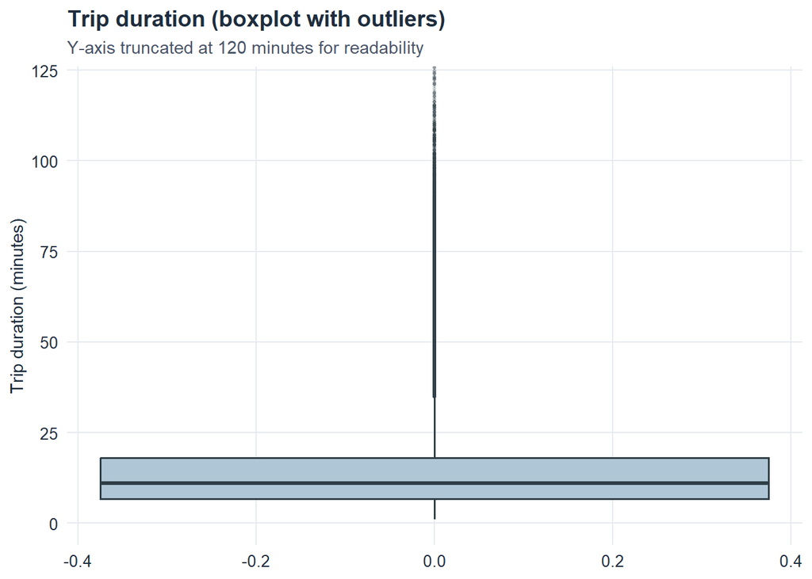

```r
theme_report <- theme_minimal(base_size = 12) +
  theme(
    plot.title = element_text(size = 14, face = "bold", color = "#1F2D3D"),
    plot.subtitle = element_text(size = 11, color = "#4A5568"),
    axis.title = element_text(size = 11, color = "#1F2D3D"),
    axis.text = element_text(size = 10, color = "#1F2D3D"),
    panel.grid.major = element_line(color = "#E6EAF0", linewidth = 0.4),
    panel.grid.minor = element_blank(),
    plot.background = element_rect(fill = "white", color = NA),
    panel.background = element_rect(fill = "white", color = NA)
  )

p_box <- ggplot(df_train, aes(y = trip_duration_min)) +
  geom_boxplot(
    outlier.alpha = 0.15,
    outlier.size = 0.8,
    fill = "#AFC6D6",
    color = "#2F3E46",
    linewidth = 0.6
  ) +
  coord_cartesian(ylim = c(0, min(120, max(df_train$trip_duration_min, na.rm = TRUE)))) +
  labs(
    title = "Trip duration (boxplot with outliers)",
    subtitle = "Y-axis truncated at 120 minutes for readability",
    x = NULL,
    y = "Trip duration (minutes)"
  ) +
  theme_report

p_box
```

### 4.1.3 Fonction de répartition empirique (ECDF) de la durée

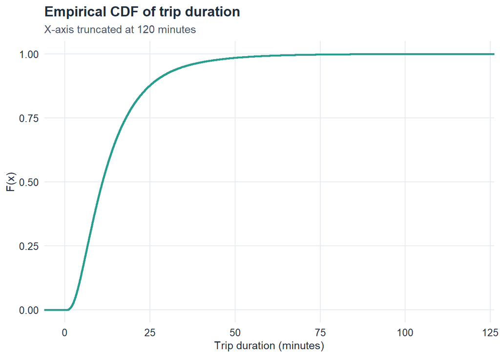

```r
p_ecdf <- ggplot(df_train, aes(x = trip_duration_min)) +
  stat_ecdf(
    geom = "step",
    linewidth = 1,
    color = "#2A9D8F"
  ) +
  coord_cartesian(xlim = c(0, 120)) +
  labs(
    title = "Empirical CDF of trip duration",
    subtitle = "X-axis truncated at 120 minutes",
    x = "Trip duration (minutes)",
    y = "F(x)"
  ) +
  theme_report

p_ecdf
```

La courbe montre que la quasi-totalité des trajets se situe sous 60 minutes ; au-delà, la probabilité devient très faible, ce qui motive soit un filtrage des extrêmes, soit une transformation robuste (ex. log1p).

### 4.1.4 Distribution de la durée des trajets

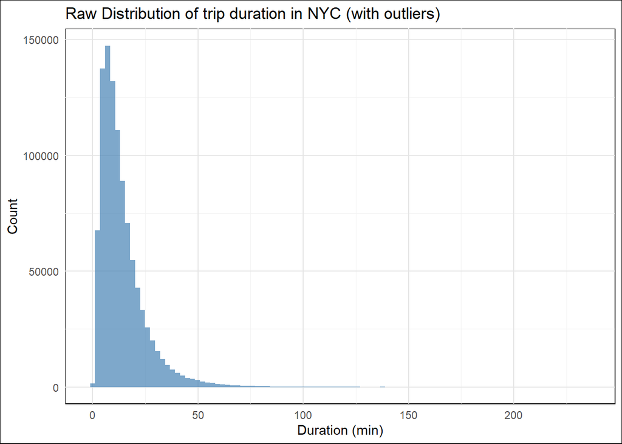

```r
# Create filtered data
filtered <- df_train %>% filter(trip_duration_min < 60)

# Plot 1: Raw Distribution
p1 <- ggplot(df_train, aes(x = trip_duration_min)) +
  geom_histogram(bins = 100, fill = "steelblue", alpha = 0.7) +
  labs(title = "Raw Distribution of trip duration in NYC (with outliers)", x = "Duration (min)", y = "Count")
p1
```

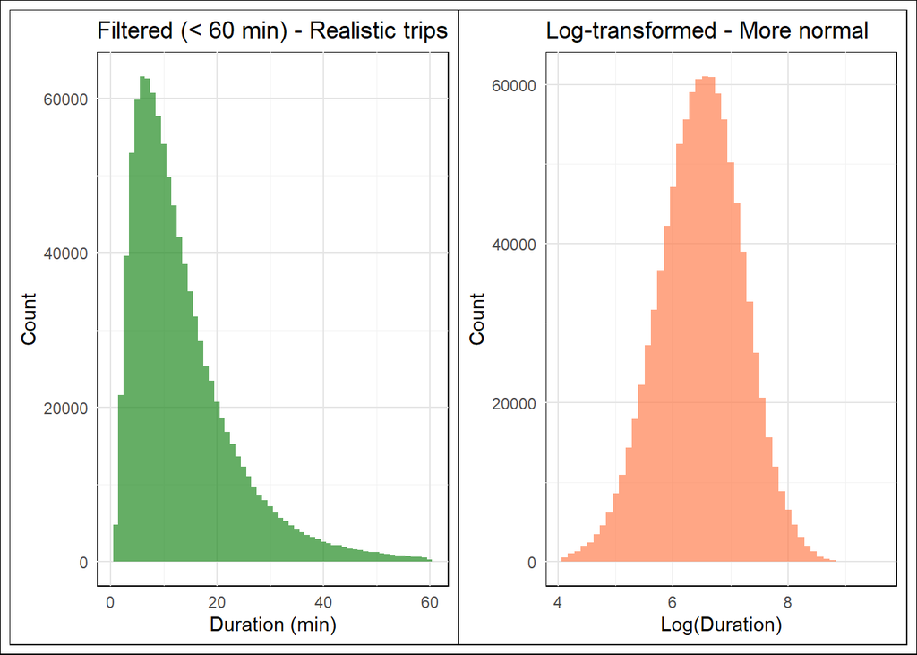

```r
# Plot 2: Filtered < 60 min
p2 <- ggplot(filtered, aes(x = trip_duration_min)) +
  geom_histogram(bins = 60, fill = "forestgreen", alpha = 0.7) +
  labs(title = "Filtered (< 60 min) - Realistic trips", x = "Duration (min)", y = "Count")

# Plot 3: Log-transformed
p3 <- ggplot(df_train, aes(x = log1p(trip_duration))) +
  geom_histogram(bins = 50, fill = "coral", alpha = 0.7) +
  labs(title = "Log-transformed - More normal", x = "Log(Duration)", y = "Count")

p2 + p3
```

### 4.1.5 QQ-plot pour évaluer la normalité après log1p

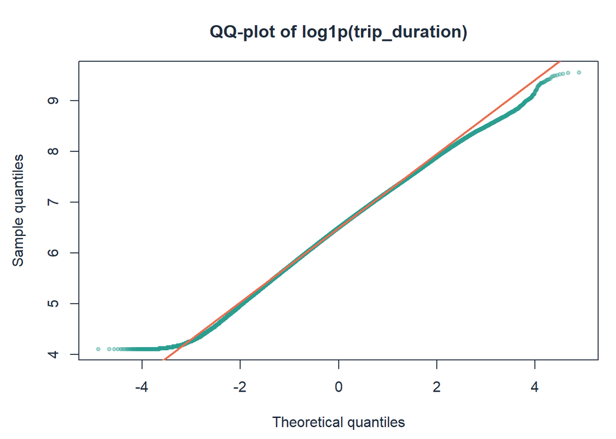

```r
log_trip <- log1p(df_train$trip_duration)

op <- par(
  bg = "white",
  col.axis = "#1F2D3D",
  col.lab  = "#1F2D3D",
  col.main = "#1F2D3D",
  fg = "#1F2D3D",
  mar = c(4.5, 4.5, 3.5, 1)
)

qqnorm(
  log_trip,
  main = "QQ-plot of log1p(trip_duration)",
  xlab = "Theoretical quantiles",
  ylab = "Sample quantiles",
  pch = 19,
  cex = 0.65,
  col = rgb(42/255, 157/255, 143/255, 0.35)
)

qqline(log_trip, col = "#E76F51", lwd = 2)
```

```r
par(op)
```

Le QQ-plot de `log1p(trip_duration)` montre un alignement globalement satisfaisant des quantiles empiriques avec la droite théorique, indiquant que la transformation logarithmique rapproche fortement la distribution d’une loi normale. De légères déviations apparaissent dans les extrémités (queues), traduisant la présence de trajets atypiquement courts ou longs, mais l’hypothèse d’une quasi-normalité est raisonnable pour l’utilisation de modèles linéaires.

### 4.1.6 Anayse des distributions

**Distribution brute (haut) :** La variable `trip_duration` présente une distribution fortement asymétrique (right-skewed) avec une longue queue vers la droite. La moyenne (14.03 min) est supérieure à la médiane (11.08 min), confirmant cette asymétrie. Des outliers extrêmes existent jusqu’à 236 minutes (~4h), ce qui est irréaliste pour un trajet taxi classique à NYC.

**Transformation log (bas droite) :** La transformation logarithmique normalise efficacement la distribution, la rendant quasi-gaussienne. Nous constatons que le pic de distribution situé entre les valeurs 6 et 8 sur l’échelle log1p. La transformation log1p (log(1 + x)) permet de lineariser les données tout en gérant les valeurs nulles :

- Valeur 4 sur l’échelle log1p ≈ exp(4)-1 ≈ 54 secondes
- Valeur 6 sur l’échelle log1p ≈ exp(6)-1 ≈ 402 secondes (6-7 minutes)
- Valeur 8 sur l’échelle log1p ≈ exp(8)-1 ≈ 2980 secondes (50 minutes)

*Remarque : A ce stade, les valeurs extrêmes ne sont pas supprimées. Le choix d’un traitement (filtrage ou transformation) sera justifié ensuite en cohérence avec l’objectif de modélisation et la robustesse attendue des modèles, en particulier les modèles linéaires.*

## 4.2 Durée des courses selon l’heure de prise en charge (trip_duration vs. pickup_hour)

L’objectif est d’évaluer l’effet de l’heure de prise en charge sur la durée des trajets, en distinguant : - **la tendance centrale** (médiane et moyenne), - **la dispersion** (intervalle interquartile Q25–Q75), - **le volume d’activité** (nombre de courses).

```r
# Function that we will reuse for further variables
pick_duration_volume_plot <- function(feature, data) {
  feature_sym <- rlang::sym(feature)

  # Summary table
summary_tbl <- data %>%
  group_by(!!feature_sym) %>%
  summarise(
    mean_duration_min   = mean(trip_duration_min, na.rm = TRUE),
    median_duration_min = median(trip_duration_min, na.rm = TRUE),
    q25 = quantile(trip_duration_min, 0.25, na.rm = TRUE),
    q75 = quantile(trip_duration_min, 0.75, na.rm = TRUE),
    iqr_duration_min = q75 - q25,
    count_trips = n(),
    .groups = "drop"
  ) %>%
  arrange(!!feature_sym) %>%
  mutate(
    mean_duration_min   = round(mean_duration_min, 2),
    median_duration_min = round(median_duration_min, 2),
    q25 = round(q25, 2),
    q75 = round(q75, 2),
    iqr_duration_min = round(iqr_duration_min, 2)
  )

  tbl_widget <- DT::datatable(
    summary_tbl,
    options = list(pageLength = 10, scrollX = TRUE),
    rownames = FALSE
  )

  x_num <- suppressWarnings(as.numeric(as.character(summary_tbl[[feature]])))
  if (!all(is.na(x_num))) {
    summary_tbl <- summary_tbl %>%
      mutate(x_value = x_num) %>%
      arrange(x_value)
    xaxis_cfg <- list(title = feature)
  } else {
    summary_tbl <- summary_tbl %>%
      mutate(x_value = factor(as.character(!!feature_sym),
                              levels = unique(as.character(!!feature_sym))))
    xaxis_cfg <- list(title = feature, type = "category")
  }

  summary_tbl <- summary_tbl %>%
    mutate(
      tooltip_duration = paste0(
        feature, ": ", as.character(!!feature_sym),
        "<br>Mean: ", round(mean_duration_min, 2),
        "<br>Median: ", round(median_duration_min, 2),
        "<br>Q25: ", round(q25, 2),
        "<br>Q75: ", round(q75, 2),
        "<br>IQR: ", round(iqr_duration_min, 2)
      ),
      tooltip_volume = paste0(
        feature, ": ", as.character(!!feature_sym),
        "<br>Trips: ", scales::comma(count_trips)
      )
    )

  COL_MEDIAN <- "#1B9E77"
  COL_MEAN   <- "#D95F02"
  COL_BARS   <- "#4C78A8"

  # Plotly
  p <- plot_ly(data = summary_tbl, x = ~x_value) %>%
    add_bars(
      y = ~count_trips,
      name = "Trips",
      yaxis = "y2",
      hoverinfo = "text",
      hovertext = ~tooltip_volume,
      opacity = 0.25,
      marker = list(color = COL_BARS, line = list(width = 0))
    ) %>%
    add_lines(
      y = ~median_duration_min,
      name = "Median",
      hoverinfo = "text",
      hovertext = ~tooltip_duration,
      line = list(color = COL_MEDIAN, width = 2)
    ) %>%
    add_markers(
      y = ~median_duration_min,
      marker = list(color = COL_MEDIAN, size = 7),
      hoverinfo = "text",
      hovertext = ~tooltip_duration,
      showlegend = FALSE
    ) %>%
    add_lines(
      y = ~mean_duration_min,
      name = "Mean",
      hoverinfo = "text",
      hovertext = ~tooltip_duration,
      line = list(color = COL_MEAN, width = 2, dash = "dash")
    ) %>%
    add_markers(
      y = ~mean_duration_min,
      marker = list(color = COL_MEAN, size = 7),
      hoverinfo = "text",
      hovertext = ~tooltip_duration,
      showlegend = FALSE
    ) %>%
    layout(
      title = paste("Trip duration and volume by", feature),
      xaxis = xaxis_cfg,
      yaxis = list(title = "Duration (minutes)", rangemode = "tozero"),
      yaxis2 = list(
        title = "Number of trips",
        overlaying = "y",
        side = "right",
        tickformat = ",",
        rangemode = "tozero"
      ),
      barmode = "overlay",
      legend = list(orientation = "h", x = 0.5, xanchor = "center", y = -0.25),
      margin = list(l = 70, r = 70, t = 80, b = 140)
      # height = 500
    )

  htmltools::tagList(
    tbl_widget,
    htmltools::br(),
    p
  )

}
```

```r
pick_duration_volume_plot("pickup_hour", df_train)
```

| pickup_hour | mean_duration_min | median_duration_min | q25 | q75 | iqr_duration_min | count_trips |
| --- | --- | --- | --- | --- | --- | --- |
| 0 | 13.13 | 10.83 | 6.58 | 17.38 | 10.8 | 37093 |
| 1 | 12.41 | 10.32 | 6.28 | 16.32 | 10.03 | 26807 |
| 2 | 11.8 | 9.93 | 5.98 | 15.72 | 9.73 | 19379 |
| 3 | 11.82 | 9.93 | 5.92 | 15.94 | 10.02 | 14504 |
| 4 | 12.33 | 10.23 | 5.77 | 17.05 | 11.28 | 10896 |
| 5 | 12.02 | 8.82 | 4.9 | 16.7 | 11.8 | 10369 |
| 6 | 11.24 | 7.93 | 4.92 | 13.4 | 8.48 | 23050 |
| 7 | 12.72 | 9.62 | 5.98 | 15.27 | 9.28 | 38731 |
| 8 | 13.97 | 11.03 | 6.6 | 17.82 | 11.22 | 46803 |
| 9 | 14.13 | 11.38 | 6.78 | 18.3 | 11.52 | 47135 |

[output cut: 14 more lines]

[interactive chart not shown]

**Interprétation**

- **Durée des trajets :** La moyenne et la médiane évoluent de manière parallèle tout au long de la journée, ce qui indique une structure stable de la distribution. Les durées les plus élevées sont observées entre 13h et 16h, traduisant une congestion accrue en milieu de journée. À l’inverse, les trajets sont les plus courts vers 6h du matin, période correspondant à une circulation plus fluide.
- **Variabilité intra-horaire (IQR) :** L’intervalle interquartile est plus large entre 9h et 18h, révélant une forte hétérogénéité des situations de trafic selon les zones et les distances parcourues. La dispersion plus faible durant la nuit suggère des conditions de circulation plus homogènes.
- **Profils de déplacement :** Les durées augmentent progressivement entre le matin et le milieu d’après-midi, ce qui est cohérent avec une montée en charge des déplacements liés au travail, au tourisme et aux activités urbaines. En soirée, la durée moyenne diminue légèrement malgré un volume élevé de courses.
- **Volume de trafic :** La demande est minimale entre 3h et 5h, puis augmente fortement à partir de 6h. Elle atteint un maximum entre 18h et 20h, correspondant au pic de fin de journée, avant de décroître progressivement en soirée.

**Conclusion :** L’heure de prise en charge influence simultanément la durée et le volume des courses. Les périodes de forte demande ne coïncident pas exactement avec les durées maximales, ce qui met en évidence l’effet combiné de la congestion, du type de déplacement et de la distance parcourue sur le temps de trajet.

## 4.3 Durée des courses selon le mois de prise en charge (trip_duration vs. pickup_month)

Nous analysons maintenant les variations mensuelles, qui peuvent refléter des effets de saisonnalité liés aux conditions météorologiques, au tourisme et aux changements de comportements de mobilité.

```r
pick_duration_volume_plot("pickup_month", df_train)
```

| pickup_month | mean_duration_min | median_duration_min | q25 | q75 | iqr_duration_min | count_trips |
| --- | --- | --- | --- | --- | --- | --- |
| 1 | 13.24 | 10.53 | 6.43 | 16.88 | 10.45 | 159809 |
| 2 | 13.27 | 10.67 | 6.47 | 17.07 | 10.6 | 165714 |
| 3 | 13.71 | 10.93 | 6.62 | 17.57 | 10.95 | 177969 |
| 4 | 14.21 | 11.28 | 6.78 | 18.28 | 11.5 | 174711 |
| 5 | 14.83 | 11.55 | 6.88 | 18.93 | 12.05 | 172484 |
| 6 | 14.9 | 11.62 | 6.95 | 19 | 12.05 | 162887 |

[interactive chart not shown]

**Interprétation**

- **Évolution des durées :** La durée moyenne et la durée médiane présentent une **augmentation progressive de janvier à juin**. La médiane passe d’environ **10,5 minutes en janvier** à **11,6 minutes en juin**, tandis que la moyenne augmente d’environ **13,2 à 14,9 minutes**. Cette tendance suggère un allongement graduel des trajets au cours du premier semestre.
- **Dispersion des durées :** L’**IQR (Q75 − Q25)** augmente légèrement au fil des mois, indiquant une **variabilité croissante** des durées de trajet, possiblement liée à une plus grande hétérogénéité des motifs de déplacement (tourisme, loisirs, trajets plus longs).
- **Volume de traffic :** Le nombre de courses est relativement stable, avec un **léger pic en mars**, suivi d’une **baisse modérée en juin**. Aucun mois ne présente de rupture brutale, ce qui indique une demande globalement régulière.
- **Lien durée–volume :** L’augmentation des durées ne coïncide pas avec une hausse proportionnelle du volume, ce qui suggère que l’allongement des trajets est davantage lié à la **nature des déplacements** qu’à une simple congestion due au nombre de courses.

**Conclusion :** Le mois de prise en charge influence modérément la durée des courses, avec une tendance saisonnière croissante. Cette variable constitue donc un **prédicteur pertinent**, bien que moins structurant que l’heure de prise en charge.

## 4.4 Durée des courses selon le nombre de passagers (trip_duration vs. passenger_count)

Nous analysons ici l’influence du nombre de passagers à bord sur la durée des trajets, afin d’évaluer si les courses impliquant plusieurs passagers présentent des caractéristiques temporelles distinctes.

```r
pick_duration_volume_plot("passenger_count", df_train)
```

| passenger_count | mean_duration_min | median_duration_min | q25 | q75 | iqr_duration_min | count_trips |
| --- | --- | --- | --- | --- | --- | --- |
| 1 | 13.84 | 10.97 | 6.6 | 17.73 | 11.13 | 717898 |
| 2 | 14.67 | 11.5 | 6.97 | 18.68 | 11.72 | 146580 |
| 3 | 14.48 | 11.45 | 6.98 | 18.45 | 11.47 | 41694 |
| 4 | 14.83 | 11.63 | 7.07 | 18.88 | 11.82 | 19667 |
| 5 | 14.13 | 11.2 | 6.73 | 18.08 | 11.35 | 54076 |
| 6 | 14.05 | 11.13 | 6.72 | 17.92 | 11.2 | 33659 |

[interactive chart not shown]

**Interprétation**

**Conclusion :** Le nombre de passagers constitue un prédicteur de **faible importance** pour la durée des courses, mais reste pertinent pour caractériser les profils d’usage et la structure de la demande.

## 4.5 Durée des courses par heure et par mois (trip_duration vs pickup_hour × pickup_month)

```r
# Mean trip_duration by hour and month (in minutes)
tripduration_summary <- df_train %>%
  group_by(pickup_hour, pickup_month) %>%
  summarise(
    mean_trip_duration = mean(trip_duration_min, na.rm = TRUE),
    .groups = "drop"
  ) %>%
  mutate(
    pickup_hour  = as.integer(pickup_hour),
    pickup_month = factor(pickup_month, levels = 1:6, labels = month.name[1:6])
  )

month_colors <- c(
  "January"  = "#3A5F7D",
  "February" = "#4F7F8B",
  "March"    = "#5F9C8C",
  "April"    = "#7FB3A2",
  "May"      = "#C2A06C",
  "June"     = "#D2A679"
)

# Build plot
p <- plot_ly()

for (m in levels(tripduration_summary$pickup_month)) {

  df_m <- tripduration_summary %>%
    filter(pickup_month == m) %>%
    mutate(
      tooltip = paste0(
        "<b>Month:</b> ", m,
        "<br><b>Hour:</b> ", pickup_hour,
        "<br><b>Mean duration:</b> ", round(mean_trip_duration, 2), " min"
      )
    )

  p <- p %>%
    add_trace(
      data = df_m,
      x = ~pickup_hour,
      y = ~mean_trip_duration,
      type = "scatter",
      mode = "lines+markers",
      name = m,
      line = list(color = month_colors[m], width = 2),
      marker = list(color = month_colors[m], size = 6),
      text = ~tooltip,
      hoverinfo = "text"
    )
}

p %>%
  layout(
    title = "Mean trip duration by pickup hour and month",
    xaxis = list(
      title = "Pickup hour",
      tickmode = "linear",
      dtick = 1,
      tickangle = -90
    ),
    yaxis = list(title = "Trip duration (minutes)", range = c(8, NA)),
    legend = list(orientation = "v", x = 1.05, y = 0.5, xanchor = "left", yanchor = "middle"),
    margin = list(l = 80, r = 160, t = 80, b = 80)
    # height = 700
  )
```

[interactive chart not shown]

**Interprétation**

- **Profil horaire stable :** Quelle que soit la période de l’année, on observe une structure similaire des durées de trajet : un **minimum en fin de nuit / tôt le matin (≈ 5–6h)**, suivi d’une **augmentation progressive** jusqu’à un **pic de congestion en milieu d’après-midi (≈ 14–17h)**, puis une baisse graduelle en soirée.
- **Effet saisonnier marqué :** Les courbes mensuelles sont globalement **décalées vers le haut** au fil des mois. Le mois de **juin** présente les durées les plus élevées sur la majorité des heures, tandis que **janvier** apparaît comme le mois le plus rapide.
- **Amplification aux heures critiques :** Les écarts entre mois sont **plus prononcés entre 12h et 18h** qu’en période nocturne, ce qui suggère que la saisonnalité agit principalement en **renforçant la congestion existante** (effet multiplicatif).
- **Volume ≠ seul facteur explicatif :** L’allongement des durées ne peut pas être attribué uniquement à une augmentation du nombre de courses, mais résulte d’une combinaison de facteurs tels que la **congestion routière**, les **travaux**, le **tourisme/loisirs** et la fréquence accrue de **trajets longs** (aéroports, déplacements périphériques).

**Conclusion :** La saisonnalité influence la durée des trajets, mais surtout en **accentuant la congestion aux heures de pointe**. L’interaction *mois × heure* constitue ainsi une information pertinente pour la modélisation et justifie l’intégration de **variables temporelles fines** (heure, mois ou encodage cyclique du temps).

## 4.6 Durée des courses par heure et par jour de la semaine (trip_duration vs pickup_hour × weekday)

```r
# Mean(trip_duration_min) by hour and weekday

weekday_hour_summary <- df_train %>%
  mutate(
    pickup_weekday_name = factor(
      weekdays(pickup_datetime),
      levels = c("Monday","Tuesday","Wednesday","Thursday","Friday","Saturday","Sunday")
    ),
    pickup_hour = as.integer(pickup_hour)
  ) %>%
  filter(
    !is.na(trip_duration_min),
    !is.na(pickup_hour),
    !is.na(pickup_weekday_name)
  ) %>%
  group_by(pickup_hour, pickup_weekday_name) %>%
  summarise(
    mean_duration_min = mean(trip_duration_min, na.rm = TRUE),
    n_trips = n(),
    .groups = "drop"
  ) %>%
  arrange(pickup_hour, pickup_weekday_name) %>%
  mutate(
    tooltip = paste0(
      "Hour: ", pickup_hour,
      "<br>Weekday: ", pickup_weekday_name,
      "<br>Mean duration: ", round(mean_duration_min, 2), " min",
      "<br>Trips: ", scales::comma(n_trips)
    )
  )

WEEKDAY_COLORS <- c(
  "#1F4E79",  # Monday
  "#2A9D8F",  # Tuesday
  "#3B6F8F",  # Wednesday
  "#59A14F",  # Thursday
  "#C98A2B",  # Friday
  "#B55B5C",  # Saturday
  "#7E6AA6"   # Sunday
)

p_weekday <- plot_ly(
  data = weekday_hour_summary,
  x = ~pickup_hour,
  y = ~mean_duration_min,
  color = ~pickup_weekday_name,
  colors = WEEKDAY_COLORS,
  type = "scatter",
  mode = "lines+markers",
  hoverinfo = "text",
  text = ~tooltip,
  marker = list(size = 6),
  line = list(width = 2)
) %>%
  layout(
    title = "Mean trip duration by pickup hour and weekday",
    xaxis = list(
      title = "Pickup hour (pickup_hour)",
      tickmode = "linear",
      tick0 = 0,
      dtick = 1
    ),
    yaxis = list(
      title = "Mean duration (minutes)",
      range = c(8, NA)
    ),
    legend = list(orientation = "v", x = 1.02, y = 1, xanchor = "left"),
    margin = list(l = 70, r = 140, t = 70, b = 90)
  )

p_weekday
```

[interactive chart not shown]

```r
weekday_distribution <- df_train %>%
  mutate(
    pickup_weekday_name = factor(
      pickup_weekday,
      levels = 0:6,
      labels = c("Monday","Tuesday","Wednesday","Thursday","Friday","Saturday","Sunday")
    )
  ) %>%
  count(pickup_weekday_name, name = "count_trips") %>%
  mutate(
    percentage = 100 * count_trips / sum(count_trips),
    percentage = round(percentage, 1)
  )

DT::datatable(
  weekday_distribution,
  rownames = FALSE,
  options = list(pageLength = 7, dom = "t", ordering = FALSE)
)
```

| pickup_weekday_name | count_trips | percentage |
| --- | --- | --- |
| Monday | 130496 | 12.9 |
| Tuesday | 140690 | 13.9 |
| Wednesday | 146123 | 14.4 |
| Thursday | 151906 | 15 |
| Friday | 155395 | 15.3 |
| Saturday | 153554 | 15.1 |
| Sunday | 135410 | 13.4 |

**Test statistique : effet du jour et interaction heure × jour (sur log1p)**

Comme l’échantillon est très grand, un test d’hypothèse classique donnera presque toujours des p-values très petites. On l’utilise surtout pour confirmer la présence d’un effet, et on interprète ensuite via taille d’effet (R², apport de l’interaction).

```r
df_model <- df_train %>%
  mutate(
    pickup_weekday_name = factor(
      weekdays(pickup_datetime),
      levels = c("Monday","Tuesday","Wednesday","Thursday","Friday","Saturday","Sunday")
    ),
    pickup_hour = as.integer(pickup_hour)
  ) %>%
  filter(
    !is.na(trip_duration_min),
    !is.na(pickup_hour),
    !is.na(pickup_weekday_name)
  ) %>%
  mutate(
    y = log1p(trip_duration_min),
    hour_f = factor(pickup_hour),
    weekday_f = pickup_weekday_name
  )

m_add <- lm(y ~ hour_f + weekday_f, data = df_model)
m_int <- lm(y ~ hour_f * weekday_f, data = df_model)

anova_interaction <- anova(m_add, m_int)
anova_interaction
```

```
## Analysis of Variance Table
##
## Model 1: y ~ hour_f + weekday_f
## Model 2: y ~ hour_f * weekday_f
##    Res.Df    RSS  Df Sum of Sq      F    Pr(>F)
## 1 1013544 425900
## 2 1013406 422383 138    3516.7 61.142 < 2.2e-16 ***
## ---
## Signif. codes:  0 '***' 0.001 '**' 0.01 '*' 0.05 '.' 0.1 ' ' 1
```

```r
r2_add <- summary(m_add)$r.squared
r2_int <- summary(m_int)$r.squared
delta_r2 <- r2_int - r2_add

c(R2_additive = r2_add, R2_interaction = r2_int, Delta_R2_interaction = delta_r2)
```

```
##          R2_additive       R2_interaction Delta_R2_interaction
##          0.017394172          0.025507707          0.008113535
```

**Interprétation**

- **Forme des courbes (effet dominant de l’heure)**  
  Quel que soit le jour de la semaine, on observe un schéma journalier très stable : durées minimales en fin de nuit / tôt le matin (≈ 5–6h), augmentation progressive jusqu’au pic de congestion en milieu d’après-midi (≈ 14–17h), puis décrue en soirée.  
  Ce comportement confirme que **l’heure de prise en charge est le principal facteur structurant de la durée des courses**, devant le jour de la semaine.
- **Effet du jour de la semaine : significatif mais modéré**  
  Le test d’ANOVA comparant un modèle additif (*heure + jour*) à un modèle incluant l’interaction (*heure × jour*) montre que l’ajout de l’interaction est **hautement significatif** (F = 61.1, *p* < 2.2e-16).  
  Cependant, l’interprétation doit se baser sur la **taille d’effet** :
  - R² du modèle additif ≈ 0.017
  - R² du modèle avec interaction ≈ 0.026
  - Gain de R² dû à l’interaction ≈ 0.008

  Ainsi, l’interaction *heure × jour* n’explique qu’environ **0,8 % de variance supplémentaire**. Cela indique que, malgré une significativité statistique forte (largement favorisée par la taille massive de l’échantillon), l’apport informationnel reste **limité**.
- **Lecture substantielle**  
  Les courbes par jour sont proches mais pas parfaitement superposées. Les jours de semaine présentent en moyenne des durées légèrement plus élevées aux heures de pointe, tandis que le week-end montre des profils parfois plus “étalés”.  
  Ces différences reflètent des **variations d’usage** (commuting vs loisirs), sans modifier profondément la structure horaire générale.
- **Implication pour la modélisation**  
  Le jour de la semaine agit principalement comme un **ajustement de niveau** (shift vertical) plutôt que comme un facteur modifiant fortement la forme du profil horaire. L’interaction *heure × jour* apporte un signal complémentaire, mais de second ordre.

**Conclusion**

L’**heure de prise en charge** constitue de loin le facteur temporel le plus déterminant de la durée des courses.  
Le **jour de la semaine** exerce un effet réel mais secondaire, et l’interaction *heure × jour* n’améliore que marginalement le pouvoir explicatif du modèle (ΔR² ≈ 0.008).

Pour la suite du projet, il est pertinent de conserver :

- des variables fines d’**heure** (éventuellement encodées de manière cyclique),
- une variable **jour de la semaine**,

mais sans sur-pondérer l’interaction, dont l’apport reste modeste. Cette hiérarchisation des effets guidera un **feature engineering parcimonieux** et cohérent avec les résultats statistiques.

### 4.6.1 Distribution hebdomadaire des courses (volume)

```r
weekday_volume <- df_train %>%
  mutate(
    pickup_weekday_name = factor(
      weekdays(pickup_datetime),
      levels = c("Monday","Tuesday","Wednesday","Thursday","Friday","Saturday","Sunday")
    )
  ) %>%
  filter(!is.na(pickup_weekday_name)) %>%
  count(pickup_weekday_name, name = "count_trips") %>%
  mutate(
    share = round(100 * count_trips / sum(count_trips), 1)
  ) %>%
  arrange(pickup_weekday_name)

weekday_volume
```

```
##   pickup_weekday_name count_trips share
## 1              Monday      130496  12.9
## 2             Tuesday      140690  13.9
## 3           Wednesday      146123  14.4
## 4            Thursday      151906  15.0
## 5              Friday      155395  15.3
## 6            Saturday      153554  15.1
## 7              Sunday      135410  13.4
```

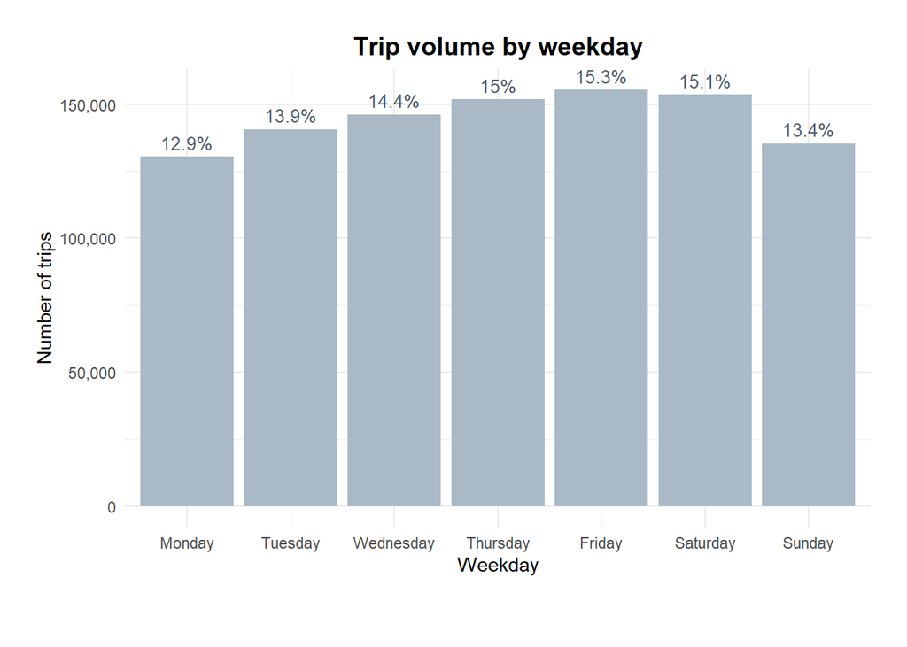

```r
weekday_volume_ggplot <- ggplot(weekday_volume, aes(x = pickup_weekday_name, y = count_trips)) +
  geom_col(fill = "#A9B9C6") +
  geom_text(aes(label = paste0(round(share, 1), "%")),
            vjust = -0.5,
            size = 3.5,
            color = "#4E5D6C") +
  scale_y_continuous(labels = scales::label_comma()) +

  labs(
    title = "Trip volume by weekday",
    x = "Weekday",
    y = "Number of trips"
  ) +

  theme_minimal() +
  theme(
    plot.title = element_text(hjust = 0.5, face = "bold", size = 14),
    axis.title = element_text(size = 11),
    # Ajustement des marges (similaire au layout plotly)
    plot.margin = margin(t = 20, r = 20, b = 40, l = 20)
  )


weekday_volume_ggplot
```

**Interprétation**

- **Répartition globale**  
  Le volume est relativement équilibré sur la semaine (écarts limités entre le jour le plus actif et le moins actif), indiquant une **demande soutenue et régulière**.
- **Jours plus actifs**  
  La fin de semaine (souvent **jeudi–samedi**) concentre une part importante des courses, cohérente avec une intensification des déplacements (sorties, loisirs, déplacements interquartiers).
- **Semaine vs week-end**  
  Le week-end représente une **part substantielle du volume total**, confirmant l’existence d’une demande “loisirs” non négligeable.
- **Jour le moins actif**  
  Le **lundi** ressort fréquemment comme la journée la plus faible en volume.

**Conclusion**

Le **jour de la semaine** explique plus clairement des **variations de volume** que des variations de durée.  
La durée reste principalement déterminée par l’**heure de prise en charge** (et la congestion associée), tandis que le jour capture surtout des différences d’**intensité de la demande** et, plus marginalement, des modulations aux heures de pointe.

### 4.6.2 Synthèse : patterns heure × jour (volume & durée)

Dans la section précédente, nous avons déjà créé des features simples. Dans cette section, nous allons créer certaines nouvelles features temporelles qui permettent d’analyser les impacts des horaires, du jour sur la durée du voyage.

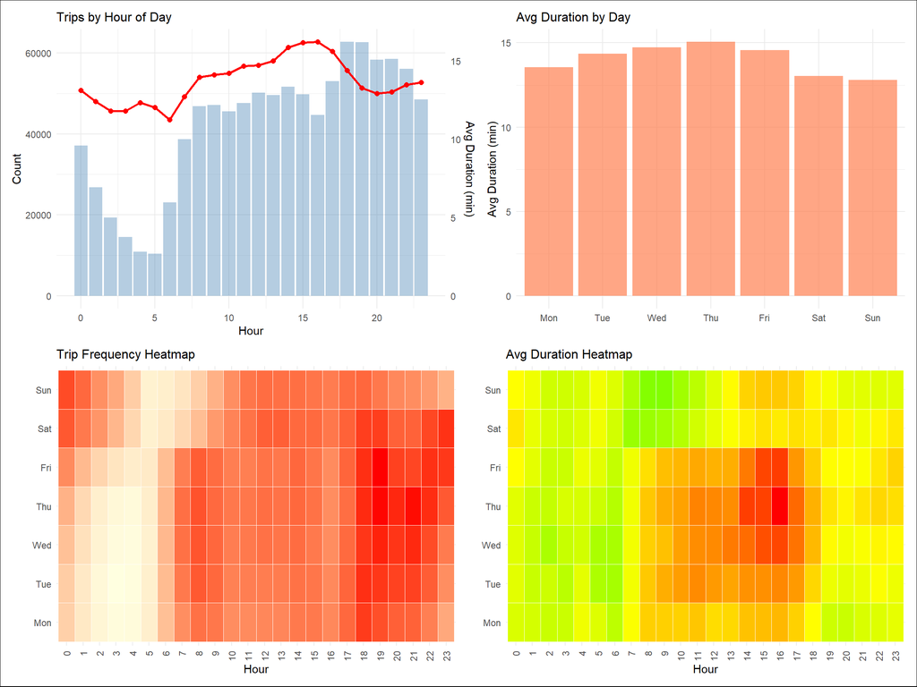

```r
# Create temporal features
df_train <- df_train %>%
  mutate(
    pickup_dayofweek = lubridate::wday(pickup_datetime, week_start = 1) - 1,  # 0-6 (Monday=0)
    is_weekend = as.integer(pickup_dayofweek >= 5)
  )

df_test <- df_test %>%
  mutate(
    pickup_dayofweek = lubridate::wday(pickup_datetime, week_start = 1) - 1,
    is_weekend = as.integer(pickup_dayofweek >= 5)
  )

day_names <- c('Mon', 'Tue', 'Wed', 'Thu', 'Fri', 'Sat', 'Sun')

# 1. Hour patterns - dual axis
hourly <- df_train %>%
  group_by(pickup_hour) %>%
  summarise(
    mean_duration = mean(trip_duration_min, na.rm = TRUE),
    count = n()
  )

# Normaliser pour double axe
scale_factor <- max(hourly$count) / max(hourly$mean_duration)

p1 <- ggplot(hourly, aes(x = pickup_hour)) +
  geom_bar(aes(y = count), stat = "identity", fill = "steelblue", alpha = 0.4, size=5) +
  geom_line(aes(y = mean_duration * scale_factor), color = "red", size = 1) +
  geom_point(aes(y = mean_duration * scale_factor), color = "red", size = 2) +
  scale_y_continuous(
    name = "Count",
    sec.axis = sec_axis(~./scale_factor, name = "Avg Duration (min)")
  ) +
  labs(x = "Hour", title = "Trips by Hour of Day") +
  theme_minimal() +
  theme(plot.title = element_text(size = 12))

# 2. Day patterns
daily <- df_train %>%
  group_by(pickup_dayofweek) %>%
  summarise(mean_duration = mean(trip_duration_min, na.rm = TRUE))

p2 <- ggplot(daily, aes(x = factor(pickup_dayofweek), y = mean_duration)) +
  geom_bar(stat = "identity", fill = "coral", alpha = 0.7) +
  scale_x_discrete(labels = day_names) +
  labs(x = "", y = "Avg Duration (min)", title = "Avg Duration by Day") +
  theme_minimal() +
  theme(plot.title = element_text(size = 12))

# 3. Heatmap - Trip count
pivot_count <- df_train %>%
  count(pickup_dayofweek, pickup_hour) %>%
  complete(pickup_dayofweek = 0:6, pickup_hour = 0:23, fill = list(n = 0))

p3 <- ggplot(pivot_count, aes(x = factor(pickup_hour), y = factor(pickup_dayofweek), fill = n)) +
  geom_tile(color = "white") +
  scale_fill_gradient(low = "lightyellow", high = "red", name = "Count") +
  scale_y_discrete(labels = day_names) +
  labs(x = "Hour", y = "", title = "Trip Frequency Heatmap") +
  theme_minimal() +
  theme(plot.title = element_text(size = 12),
        axis.text.x = element_text(angle = 90, vjust = 0.5, hjust = 1),
        legend.position = "right"
  ) +
  guides(fill = guide_colorbar(barwidth = 1, barheight = 15))

# 4. Heatmap - Duration
pivot_duration <- df_train %>%
  group_by(pickup_dayofweek, pickup_hour) %>%
  summarise(mean_duration = mean(trip_duration_min, na.rm = TRUE), .groups = "drop") %>%
  complete(pickup_dayofweek = 0:6, pickup_hour = 0:23)

p4 <- ggplot(pivot_duration, aes(x = factor(pickup_hour), y = factor(pickup_dayofweek), fill = mean_duration)) +
  geom_tile(color = "white") +
  scale_fill_gradient2(low = "green", mid = "yellow", high = "red",
                       midpoint = median(pivot_duration$mean_duration, na.rm = TRUE),
                       name = "Avg Min") +
  scale_y_discrete(labels = day_names) +
  labs(x = "Hour", y = "", title = "Avg Duration Heatmap") +
  theme_minimal() +
  theme(plot.title = element_text(size = 12),
        axis.text.x = element_text(angle = 90, vjust = 0.5, hjust = 1),
        legend.position = "right"
  ) + guides(fill = guide_colorbar(barwidth = 1, barheight = 15))

# Combinaison des graphiques en grille 2x2
(p1 + p2) / (p3 + p4) +
  plot_layout(guides = 'collect') &
  theme(legend.position = 'none')
```

**Synthèse des dynamiques temporelles**

## 4.7 Variables opérationnelles et contextuelles

Au-delà des dimensions temporelles et spatiales, certaines variables décrivent le contexte de la course ou le processus de collecte des données. Nous analysons ici leur distribution afin d’évaluer leur potentiel explicatif pour la durée des trajets.

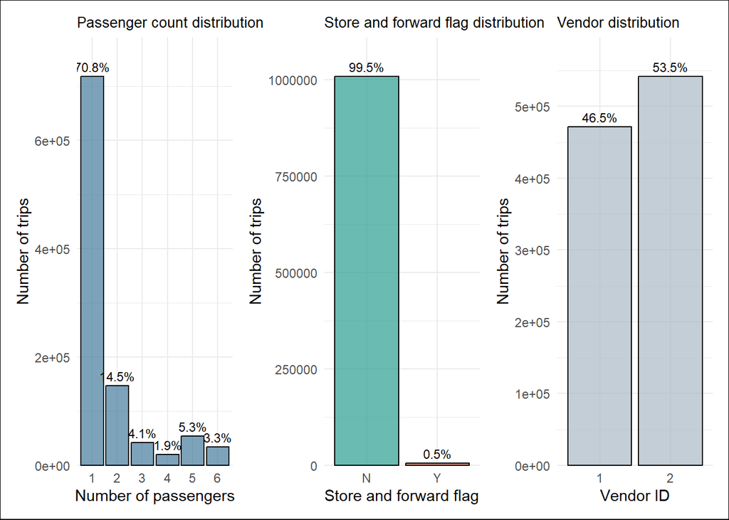

```r
# 1. Passenger count distribution
passenger_counts <- df_train %>%
  count(passenger_count) %>%
  arrange(passenger_count) %>%
  mutate(pct = n / sum(n) * 100)

p1 <- ggplot(passenger_counts, aes(x = factor(passenger_count), y = n)) +
  geom_bar(stat = "identity", fill = "#457B9D", color = "black", alpha = 0.7) +
  geom_text(aes(label = sprintf("%.1f%%", pct)), vjust = -0.5, size = 3) +
  labs(
    x = "Number of passengers",
    y = "Number of trips",
    title = "Passenger count distribution"
  ) +
  scale_y_continuous(expand = expansion(mult = c(0, 0.1))) +
  theme_minimal() +
  theme(plot.title = element_text(size = 10))

# 2. Store and forward flag distribution
flag_counts <- df_train %>%
  count(store_and_fwd_flag) %>%
  mutate(pct = n / sum(n) * 100)

p2 <- ggplot(flag_counts, aes(x = store_and_fwd_flag, y = n, fill = store_and_fwd_flag)) +
  geom_bar(stat = "identity", color = "black", alpha = 0.7) +
  geom_text(aes(label = sprintf("%.1f%%", pct)), vjust = -0.5, size = 3) +
  scale_fill_manual(values = c("N" = "#2A9D8F", "Y" = "#E76F51")) +
  labs(
    x = "Store and forward flag",
    y = "Number of trips",
    title = "Store and forward flag distribution"
  ) +
  scale_y_continuous(expand = expansion(mult = c(0, 0.1))) +
  theme_minimal() +
  theme(legend.position = "none", plot.title = element_text(size = 10))

# 3. Vendor count distribution
vendor_counts <- df_train %>%
  count(vendor_id) %>%
  arrange(vendor_id) %>%
  mutate(pct = n / sum(n) * 100)

p3 <- ggplot(vendor_counts, aes(x = factor(vendor_id), y = n)) +
  geom_bar(stat = "identity", fill = "#A9B9C6", color = "black", alpha = 0.7) +
  geom_text(aes(label = sprintf("%.1f%%", pct)), vjust = -0.5, size = 3) +
  labs(
    x = "Vendor ID",
    y = "Number of trips",
    title = "Vendor distribution"
  ) +
  scale_y_continuous(expand = expansion(mult = c(0, 0.1))) +
  theme_minimal() +
  theme(plot.title = element_text(size = 10))

# Combine plots
p1 + p2 + p3 + plot_layout(ncol = 3)
```

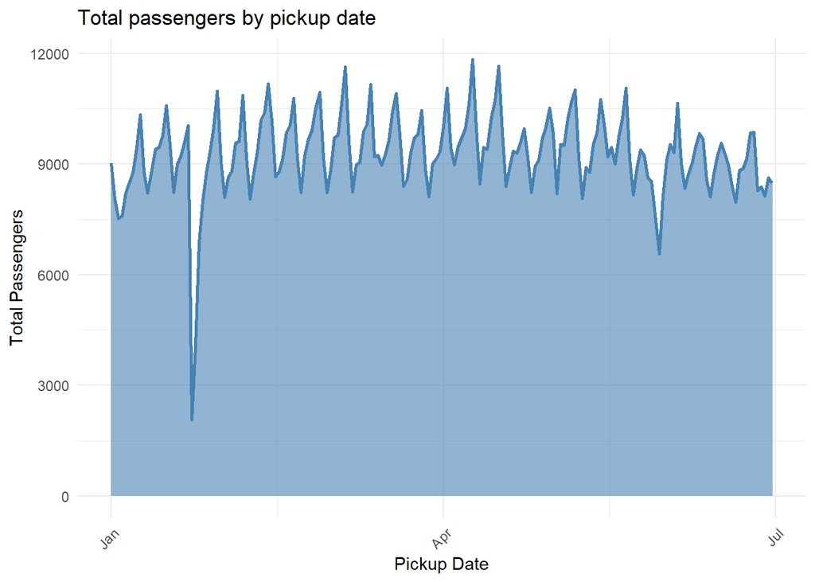

```r
pickup_passenger <- df_train %>%
  group_by(pickup_date) %>%
  summarise(total_passengers = sum(passenger_count, na.rm = TRUE))

dropoff_passenger <- df_train %>%
  group_by(dropoff_date) %>%
  summarise(total_passengers = sum(passenger_count, na.rm = TRUE))

p1 <- ggplot(pickup_passenger, aes(x = pickup_date, y = total_passengers)) +
  geom_area(fill = "steelblue", alpha = 0.6) +  # ← Area remplie
  geom_line(linewidth = 1, color = "steelblue") +  # ← Ligne par-dessus
  labs(title = "Total passengers by pickup date",
       x = "Pickup Date",
       y = "Total Passengers") +
  theme_minimal() +
  theme(axis.text.x = element_text(angle = 45, hjust = 1))

# p2 <- ggplot(dropoff_passenger, aes(x = dropoff_date, y = total_passengers)) +
#   geom_area(fill = "#16BA91", alpha = 0.6) +  # ← Area remplie
#   geom_line(linewidth = 1, color = "#16BA91") +  # ← Ligne par-dessus
#   labs(title = "Total passengers by dropoff date",
#        x = "Dropoff Date",
#        y = "Total Passengers") +
#   theme_minimal() +
#   theme(axis.text.x = element_text(angle = 45, hjust = 1))
#
# grid.arrange(p1, p2, ncol = 2)
p1
```

```r
passenger_counts <- df_train %>%
  count(passenger_count, name = "count", sort = TRUE) %>%
  mutate(proportion = count / sum(count) * 100,
         cumulative_prop = cumsum(proportion))
print(passenger_counts)
```

```
##   passenger_count  count proportion cumulative_prop
## 1               1 717898  70.828376        70.82838
## 2               2 146580  14.461697        85.29007
## 3               5  54076   5.335180        90.62525
## 4               3  41694   4.113563        94.73882
## 5               6  33659   3.320823        98.05964
## 6               4  19667   1.940362       100.00000
```

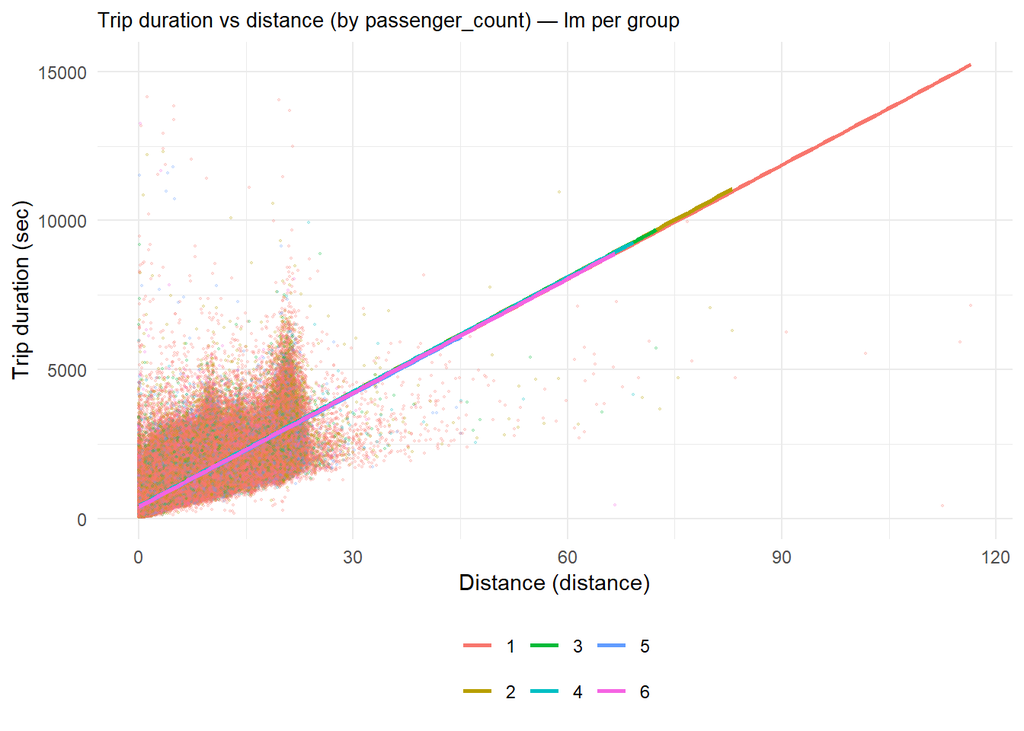

```r
calculate_distance <- function(lat1, lon1, lat2, lon2) {
  R <- 6371
  lat1_rad <- lat1 * pi / 180
  lat2_rad <- lat2 * pi / 180
  dlat <- (lat2 - lat1) * pi / 180
  dlon <- (lon2 - lon1) * pi / 180
  a <- sin(dlat/2)^2 +
       cos(lat1_rad) * cos(lat2_rad) * sin(dlon/2)^2
  c <- 2 * asin(sqrt(a))
  R * c
}

plot_df <- df_train %>%
  transmute(
    distance = calculate_distance(pickup_latitude, pickup_longitude,
                                   dropoff_latitude, dropoff_longitude),
    trip_duration = trip_duration,
    passenger_count = factor(passenger_count),
    store_and_fwd_flag = factor(store_and_fwd_flag),
    vendor_id = factor(vendor_id)
  ) %>%
  filter(!is.na(distance), !is.na(trip_duration), trip_duration > 0, distance >= 0)

# Generic function
plot_by_cat <- function(df, cat_var, title_prefix) {

  p_lm <- ggplot(df, aes(x = distance, y = trip_duration, color = .data[[cat_var]])) +
    geom_point(size = 0.4, alpha = 0.20) +
    geom_smooth(method = "lm", se = FALSE, linewidth = 0.9) +
    labs(
      title = paste0(title_prefix, " — lm per group"),
      x = paste0("Distance (", "distance", ")"),
      y = "Trip duration (sec)",
      color = NULL
    ) +
    theme_minimal() +
    theme(
      plot.title = element_text(size = 10),
      legend.position = "bottom"
    )

  p_lm
}


plot_by_cat(
  df = plot_df,
  cat_var = "passenger_count",
  title_prefix = "Trip duration vs distance (by passenger_count)"
)
```

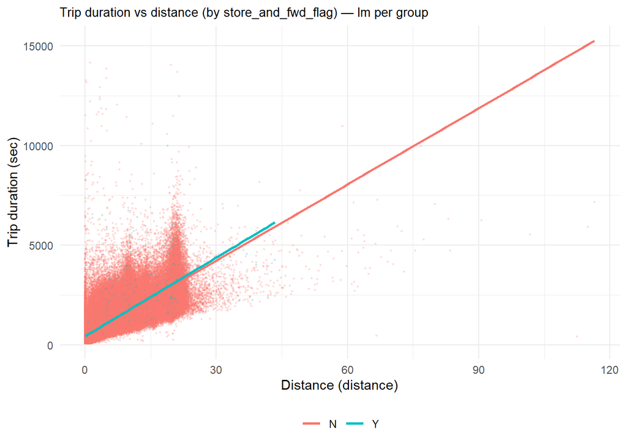

```r
plot_by_cat(
  df = plot_df,
  cat_var = "store_and_fwd_flag",
  title_prefix = "Trip duration vs distance (by store_and_fwd_flag)"
)
```

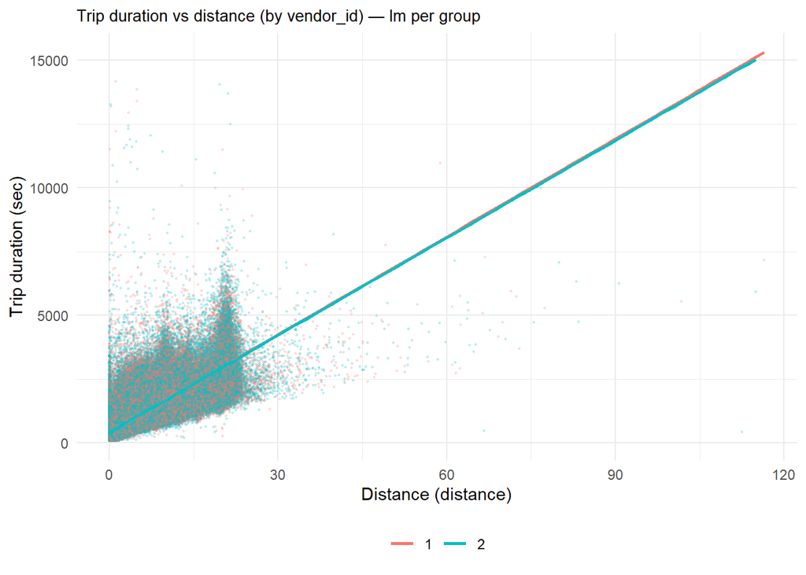

```r
plot_by_cat(
  df = plot_df,
  cat_var = "vendor_id",
  title_prefix = "Trip duration vs distance (by vendor_id)"
)
```

**Interprétation**

- **Nombre de passagers** Une très large majorité des trajets s’effectue avec un seul passager (≈ 71 %). Les courses avec deux passagers représentent une part nettement plus faible (≈ 15 %), et les effectifs supérieurs restent marginaux.  
  Ce fort déséquilibre suggère que `passenger_count` aura probablement un **pouvoir explicatif limité** sur la durée des courses.
- **Store and Forward Flag** La quasi-totalité des trajets est transmise en temps réel (`N`, ≈ 99.5 %). La modalité `Y` est extrêmement rare.  
  Cette variable apporte peu d’information sur la durée et pourra être **écartée ou conservée uniquement à titre exploratoire**.
- **Vendor ID** Les deux prestataires sont représentés de manière relativement équilibrée (≈ 47 % vs 53 %).  
  Cette distribution permet de tester un éventuel effet fournisseur sur la durée, même si aucun mécanisme direct ne suggère un impact majeur.

**Conclusion**

Les variables opérationnelles étudiées fournissent surtout des **informations descriptives** sur la structure des courses.

L’analyse graphique des régressions linéaires par groupe confirme cette intuition : les pentes pour chaque modalité de `passenger_count`, `store_and_fwd_flag` et `vendor_id` sont quasi confondues, indiquant que ces facteurs n’influencent pas de manière significative la relation entre la distance et la durée du trajet.

Ces résultats confirment que les **variables temporelles et spatiales** constituent les principaux déterminants de `trip_duration`, et guideront un feature engineering centré prioritairement sur ces dimensions.

## 4.8 Effets spatiaux et géographiques

Cette section analyse la distribution spatiale des points de prise en charge (pickup) et de dépose (dropoff) afin d’identifier les zones d’activité dominantes et d’évaluer la cohérence géographique du jeu de données.

**Distribution des coordonnées GPS (diagnostic)**

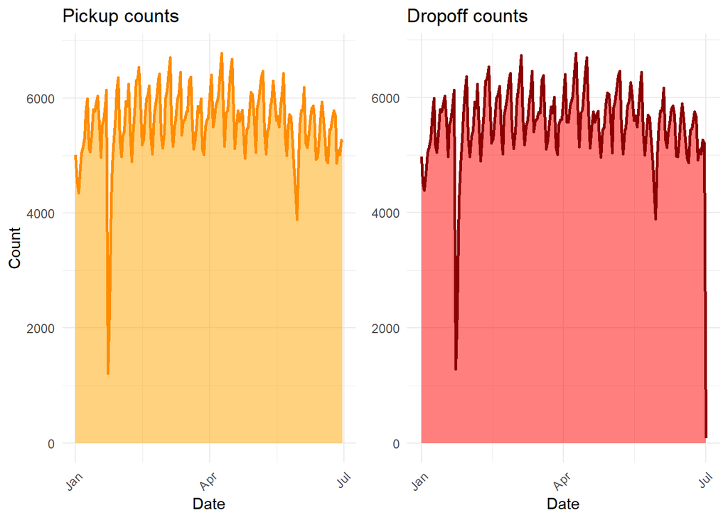

```r
pickup_counts <- df_train %>%
  group_by(pickup_date) %>%
  summarise(count = n())

dropoff_counts <- df_train %>%
  group_by(dropoff_date) %>%
  summarise(count = n())

# Ribbon plot
p1 <- ggplot(pickup_counts, aes(x = pickup_date, y = count)) +
  geom_ribbon(aes(ymin = 0, ymax = count), fill = "orange", alpha = 0.5) +
  geom_line(color = "darkorange", linewidth = 1) +
  labs(x = "Date", y = "Count", title = "Pickup counts") +
  theme_minimal() +
  theme(axis.text.x = element_text(angle = 45, hjust = 1))

p2 <- ggplot(dropoff_counts, aes(x = dropoff_date, y = count)) +
  geom_ribbon(aes(ymin = 0, ymax = count), fill = "red", alpha = 0.5) +
  geom_line(color = "darkred", linewidth = 1) +
  labs(x = "Date", y = "Count", title = "Dropoff counts") +
  theme_minimal() +
  theme(axis.text.x = element_text(angle = 45, hjust = 1),
        axis.title.y = element_blank())

grid.arrange(p1, p2, ncol = 2, widths = c(1, 1))
```

```r
# Filtrer les données autour de la chute
crash_data <- pickup_counts %>%
  filter(pickup_date >= as.Date("2016-01-20") & pickup_date <= as.Date("2016-01-26"))

print(crash_data)
```

```
## # A tibble: 7 × 2
##   pickup_date count
##   <date>      <int>
## 1 2016-01-20   5615
## 2 2016-01-21   5864
## 3 2016-01-22   6140
## 4 2016-01-23   1214
## 5 2016-01-24   2327
## 6 2016-01-25   4218
## 7 2016-01-26   4850
```

### 4.8.1 Distribution globale des coordonnées

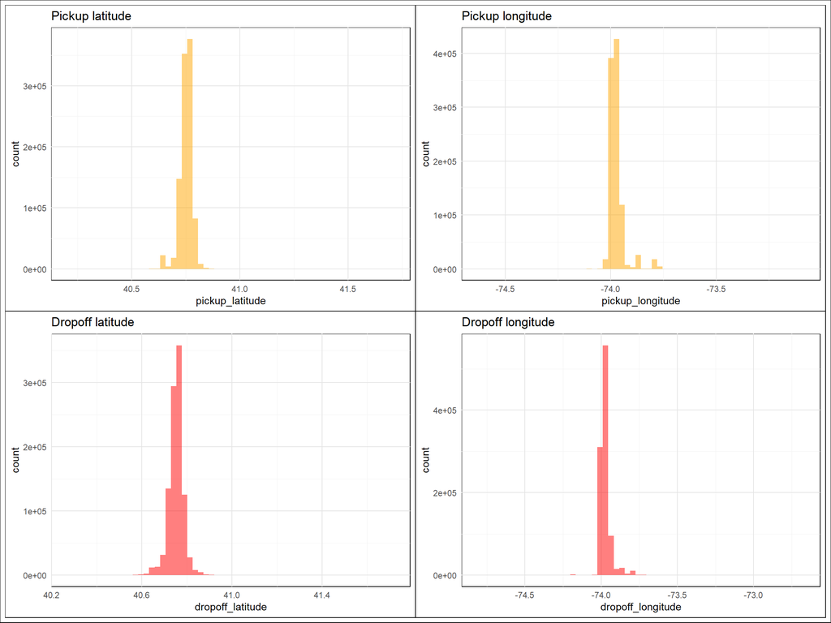

```r
p1 <- ggplot(df_train, aes(x = pickup_latitude)) +
  geom_histogram(bins = 60, fill = "orange", alpha = 0.5) +
  labs(title = "Pickup latitude")

p2 <- ggplot(df_train, aes(x = pickup_longitude)) +
  geom_histogram(bins = 60, fill = "orange", alpha = 0.5) +
  labs(title = "Pickup longitude")

p3 <- ggplot(df_train, aes(x = dropoff_latitude)) +
  geom_histogram(bins = 60, fill = "red", alpha = 0.5) +
  labs(title = "Dropoff latitude")

p4 <- ggplot(df_train, aes(x = dropoff_longitude)) +
  geom_histogram(bins = 60, fill = "red", alpha = 0.5) +
  labs(title = "Dropoff longitude")

(p1 + p2) / (p3 + p4)
```

**Observations**

Les distributions présentent des plages larges indiquant la présence de valeurs aberrantes ou hors zone urbaine.

Les zones de densité maximale se concentrent autour des coordonnées de New York City.

### 4.8.2 Zoom sur la zone urbaine pertinente

```r
df_train_loc <- df_train %>%
  filter(
    dplyr::between(pickup_latitude, 40.6, 40.9),
    dplyr::between(dropoff_latitude, 40.6, 40.9),
    dplyr::between(pickup_longitude, -74.05, -73.70),
    dplyr::between(dropoff_longitude, -74.05, -73.70)
  )
```

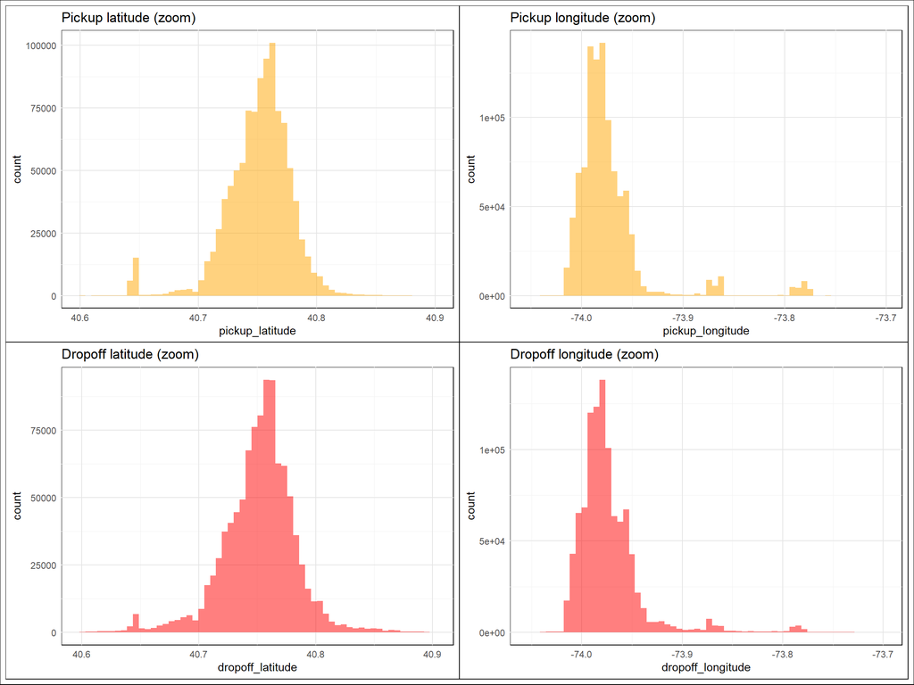

```r
p1 <- ggplot(df_train_loc, aes(x = pickup_latitude)) +
  geom_histogram(bins = 60, fill = "orange", alpha = 0.5) +
  labs(title = "Pickup latitude (zoom)")

p2 <- ggplot(df_train_loc, aes(x = pickup_longitude)) +
  geom_histogram(bins = 60, fill = "orange", alpha = 0.5) +
  labs(title = "Pickup longitude (zoom)")

p3 <- ggplot(df_train_loc, aes(x = dropoff_latitude)) +
  geom_histogram(bins = 60, fill = "red", alpha = 0.5) +
  labs(title = "Dropoff latitude (zoom)")

p4 <- ggplot(df_train_loc, aes(x = dropoff_longitude)) +
  geom_histogram(bins = 60, fill = "red", alpha = 0.5) +
  labs(title = "Dropoff longitude (zoom)")

(p1 + p2) / (p3 + p4)
```

**Interprétation spatiale**

L’activité se concentre principalement entre 40.70° et 40.80° de latitude et -74.00° à -73.95° de longitude, correspondant au cœur de Manhattan.

Les distributions pickup et dropoff sont très similaires, ce qui confirme la cohérence spatiale du jeu de données.

Quelques flux secondaires relient Manhattan aux zones périphériques (Brooklyn, Queens, New Jersey, aéroports).

**Conclusion**

Le service de taxi est fortement centré sur Manhattan, caractérisé par des trajets courts au sein d’un noyau urbain dense. La localisation constitue donc une variable explicative majeure de la durée des trajets et justifie l’ingénierie de features spatiales (distance haversine, clusters, zones).

# 5 Feature Engineering

Dans cette section, nous construisons des variables avancées destinées à enrichir la représentation des trajets, afin de mieux capturer les dimensions temporelles, spatiales et comportementales du trafic urbain.

L’objectif est de transformer les variables brutes en caractéristiques plus informatives, capables d’expliquer la variabilité de la durée des courses, tout en restant indépendantes de la cible lors de l’inférence.

Les familles de variables créées sont :

- **Métriques de distance**
- **Variables temporelles et encodage cyclique**
- **Indicateurs de congestion**
- **Caractéristiques géographiques (direction, zones spécifiques)**
- **Variables d’interaction**

## 5.1 Fonctions utilitaires : distances et orientation

Nous définissons deux fonctions géographiques fondamentales :

- **Distance Haversine :** distance “à vol d’oiseau” entre deux points
- **Bearing :** direction du trajet en degrés (0° = Nord)

```r
# Haversine distance in kilometers
haversine_distance <- function(lat1, lon1, lat2, lon2) {

  R <- 6371

  lat1_rad <- lat1 * pi / 180
  lat2_rad <- lat2 * pi / 180
  dlat <- (lat2 - lat1) * pi / 180
  dlon <- (lon2 - lon1) * pi / 180

  a <- sin(dlat/2)^2 +
       cos(lat1_rad) * cos(lat2_rad) * sin(dlon/2)^2

  c <- 2 * asin(sqrt(a))
  R * c
}

# Bearing (direction) in degrees
calculate_bearing <- function(lat1, lon1, lat2, lon2) {

  rad <- pi / 180
  lat1 <- lat1 * rad; lon1 <- lon1 * rad
  lat2 <- lat2 * rad; lon2 <- lon2 * rad

  dlon <- lon2 - lon1

  x <- sin(dlon) * cos(lat2)
  y <- cos(lat1) * sin(lat2) -
       sin(lat1) * cos(lat2) * cos(dlon)

  bearing <- atan2(x, y) * 180 / pi
  (bearing + 360) %% 360
}
```

## 5.2 Fonction principale d’ingénierie des variables

Cette fonction applique l’ensemble des transformations de manière reproductible sur les jeux d’entraînement et de test.

```r
engineer_features <- function(df) {

  # Required columns
  required_cols <- c(
    "pickup_datetime", "pickup_hour", "pickup_dayofweek", "is_weekend",
    "pickup_latitude", "pickup_longitude",
    "dropoff_latitude", "dropoff_longitude",
    "passenger_count", "store_and_fwd_flag"
  )

  df <- df %>% tidyr::drop_na(dplyr::all_of(required_cols))


  # TEMPORAL FEATURES
  df <- df %>%
    mutate(
      pickup_dayofmonth = lubridate::day(pickup_datetime),
      pickup_weekofyear = lubridate::isoweek(pickup_datetime),
      pickup_dayofyear  = lubridate::yday(pickup_datetime),

      is_morning_rush = as.integer(pickup_hour >= 7 & pickup_hour <= 9),
      is_evening_rush = as.integer(pickup_hour >= 17 & pickup_hour <= 19),
      is_rush_hour    = as.integer(is_morning_rush | is_evening_rush),
      is_night        = as.integer(pickup_hour >= 22 | pickup_hour <= 5),

      pickup_hour_sin = sin(2 * pi * pickup_hour / 24),
      pickup_hour_cos = cos(2 * pi * pickup_hour / 24),

      pickup_dow_sin  = sin(2 * pi * pickup_dayofweek / 7),
      pickup_dow_cos  = cos(2 * pi * pickup_dayofweek / 7),

      pickup_dayofyear_sin = sin(2 * pi * pickup_dayofyear / 365),
      pickup_dayofyear_cos = cos(2 * pi * pickup_dayofyear / 365)
    )


  # DISTANCE FEATURES
  df <- df %>%
    mutate(
      haversine_distance =
        haversine_distance(
          pickup_latitude, pickup_longitude,
          dropoff_latitude, dropoff_longitude
        ),

      manhattan_distance =
        haversine_distance(pickup_latitude, pickup_longitude,
                           pickup_latitude, dropoff_longitude) +
        haversine_distance(pickup_latitude, dropoff_longitude,
                           dropoff_latitude, dropoff_longitude)
    )

  # DIRECTION & SPATIAL SHAPE
  df <- df %>%
    mutate(
      direction =
        calculate_bearing(
          pickup_latitude, pickup_longitude,
          dropoff_latitude, dropoff_longitude
        ),

      bearing_sin = sin(direction * pi / 180),
      bearing_cos = cos(direction * pi / 180),

      lat_diff = abs(dropoff_latitude - pickup_latitude),
      lon_diff = abs(dropoff_longitude - pickup_longitude),

      mid_lat = (pickup_latitude + dropoff_latitude) / 2,
      mid_lon = (pickup_longitude + dropoff_longitude) / 2
    )

  # SPEED (TRAIN ONLY)
  if ("trip_duration" %in% names(df)) {
    df <- df %>%
      mutate(
        avg_speed_kmh =
          haversine_distance / (trip_duration / 3600)
      )
  } else {
    df <- df %>% mutate(avg_speed_kmh = NA_real_)
  }


  # LANDMARK FEATURES (AIRPORTS, MIDTOWN)
  jfk_lat <- 40.6413; jfk_lon <- -73.7781
  lga_lat <- 40.7769; lga_lon <- -73.8740
  ts_lat  <- 40.7580; ts_lon  <- -73.9855

  df <- df %>%
    mutate(
      distance_to_jfk_pickup =
        haversine_distance(pickup_latitude, pickup_longitude,
                           jfk_lat, jfk_lon),
      distance_to_jfk_dropoff =
        haversine_distance(dropoff_latitude, dropoff_longitude,
                           jfk_lat, jfk_lon),
      is_jfk_trip =
        as.integer(distance_to_jfk_pickup < 2 |
                   distance_to_jfk_dropoff < 2),

      distance_to_lga_pickup =
        haversine_distance(pickup_latitude, pickup_longitude,
                           lga_lat, lga_lon),
      distance_to_lga_dropoff =
        haversine_distance(dropoff_latitude, dropoff_longitude,
                           lga_lat, lga_lon),
      is_lga_trip =
        as.integer(distance_to_lga_pickup < 1.5 |
                   distance_to_lga_dropoff < 1.5),

      distance_to_midtown_pickup =
        haversine_distance(pickup_latitude, pickup_longitude,
                           ts_lat, ts_lon),
      distance_to_midtown_dropoff =
        haversine_distance(dropoff_latitude, dropoff_longitude,
                           ts_lat, ts_lon)
    )


  # CATEGORICAL ENCODING
  df <- df %>%
    mutate(store_and_fwd_flag =
             as.integer(store_and_fwd_flag == "Y"))


  # INTERACTION & TRANSFORMATIONS
  df <- df %>%
    mutate(
      rush_hour_distance =
        is_rush_hour * haversine_distance,

      weekend_night =
        is_weekend * is_night,

      passengers_distance =
        passenger_count * haversine_distance,

      log_haversine  = log1p(haversine_distance),
      log_manhattan  = log1p(manhattan_distance)
    )

  return(df)
}
```

**Application aux jeux Train et Test**

```r
df_train_features <- engineer_features(df_train)
df_test_features  <- engineer_features(df_test)

cat(sprintf("Train: %d rows | %d features\n",
            nrow(df_train_features),
            ncol(df_train_features)))
```

```
## Train: 1013574 rows | 60 features
```

```r
cat(sprintf("Test : %d rows | %d features\n",
            nrow(df_test_features),
            ncol(df_test_features)))
```

```
## Test : 434326 rows | 59 features
```

**Vérifications rapides**

```r
summary(df_train_features$haversine_distance)
```

```
##    Min. 1st Qu.  Median    Mean 3rd Qu.    Max.
##   0.000   1.244   2.108   3.458   3.896 116.496
```

```r
summary(df_train_features$manhattan_distance)
```

```
##    Min. 1st Qu.  Median    Mean 3rd Qu.    Max.
##   0.000   1.587   2.706   4.469   5.025 164.454
```

```r
summary(df_train_features$avg_speed_kmh)
```

```
##    Min. 1st Qu.  Median    Mean 3rd Qu.    Max.
##   0.000   9.175  12.826  14.417  17.855 948.890
```

```r
sum(is.na(df_test_features$avg_speed_kmh))
```

```
## [1] 0
```

**Conclusion Feature Engineering**

Les variables créées permettent de représenter chaque course selon trois axes majeurs :

- **Géométrie du trajet :** distance, direction, forme spatiale
- **Contexte temporel :** heure, jour, saisonnalité, congestion
- **Spécificités urbaines :** aéroports, zones centrales, heures critiques

Cette base de caractéristiques constitue un socle robuste pour l’étape de modélisation, en capturant à la fois :

1. la longueur potentielle du trajet,
2. les conditions de circulation,
3. et les comportements particuliers de mobilité.

## 5.3 Visualisations de validation des features spatiales

Dans cette sous-section, on valide les nouvelles variables spatiales (densités, distances, trajets aéroport, direction, vitesse). On travaille sur un échantillon pour garder des temps de rendu raisonnables, sans perdre les patterns.

```r
# Airports coordinates
JFK <- c(lat = 40.6413, lon = -73.7781)
LGA <- c(lat = 40.7769, lon = -73.8740)

# Airports dataframe for plotting
airports <- tibble::tibble(
  name = c("JFK", "LGA"),
  lat = c(JFK["lat"], LGA["lat"]),
  lon = c(JFK["lon"], LGA["lon"])
)
```

## 5.4 Densités spatiales : Pickups vs Dropoffs

Objectif : vérifier que les coordonnées filtrées produisent un pattern cohérent (Manhattan dominant + extensions vers les boroughs/aéroports).

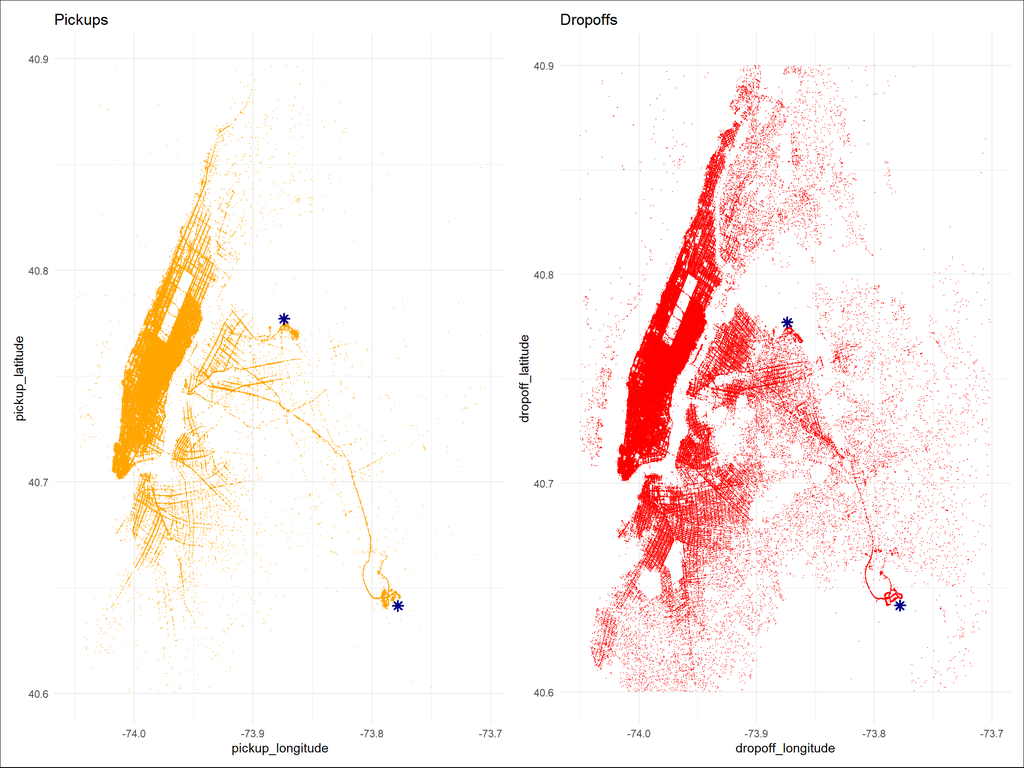

```r
# Pickups
p1 <- ggplot(df_train_loc, aes(x = pickup_longitude, y = pickup_latitude)) +
  geom_point(color = "orange", size = 0.02, alpha = 0.5) +
  geom_point(
    data = airports, aes(x = lon, y = lat),
    inherit.aes = FALSE, color = "darkblue", size = 2.2, shape = 8, stroke = 1.2
  ) +
  labs(title = "Pickups", x = "pickup_longitude", y = "pickup_latitude") +
  theme_minimal()

# Dropoffs
p2 <- ggplot(df_train_loc, aes(x = dropoff_longitude, y = dropoff_latitude)) +
  geom_point(color = "red", size = 0.02, alpha = 0.5) +
  geom_point(
    data = airports, aes(x = lon, y = lat),
    inherit.aes = FALSE, color = "darkblue", size = 2.2, shape = 8, stroke = 1.2
  ) +
  labs(title = "Dropoffs", x = "dropoff_longitude", y = "dropoff_latitude") +
  theme_minimal()

p1 + p2 +
  plot_layout(guides = 'collect') &
  theme(legend.position = 'none')
```

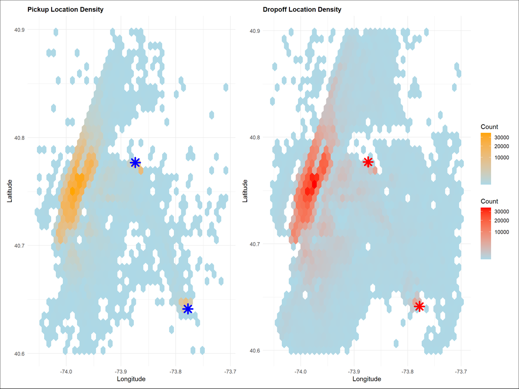

```r
# Graphique des pickups
p1 <- ggplot(df_train_loc, aes(x = pickup_longitude, y = pickup_latitude)) +
  geom_hex(bins = 40) +
  scale_fill_gradient(
    low = "lightblue",
    high = "orange",
    name = "Count",
    trans = "sqrt"
  ) +
  geom_point(
    data = airports, aes(x = lon, y = lat),
    color = "blue", size = 4, shape = 8, stroke = 2
  ) +
  labs(
    title = "Pickup Location Density",
    x = "Longitude",
    y = "Latitude"
  ) +
  theme_minimal() +
  theme(plot.title = element_text(size = 11, face = "bold"))

# 2. Dropoff density
p2 <- ggplot(df_train_loc, aes(x = dropoff_longitude, y = dropoff_latitude)) +
  geom_hex(bins = 40) +
  scale_fill_gradient(
    low = "lightblue",
    high = "red",
    name = "Count",
    trans = "sqrt"
  ) +
  geom_point(
    data = airports, aes(x = lon, y = lat),
    color = "red", size = 4, shape = 8, stroke = 2
  ) +
  labs(
    title = "Dropoff Location Density",
    x = "Longitude",
    y = "Latitude"
  ) +
  theme_minimal() +
  theme(plot.title = element_text(size = 11, face = "bold"))

# Combinaison des deux graphiques côte à côte
p1 + p2 +
  plot_layout(guides = "collect") &
  theme(legend.position = "right")
```

**Observations**

- Une **forte concentration spatiale** des prises en charge et des déposes est observée dans **le centre de Manhattan**, confirmant que le marché du taxi est principalement structuré autour du noyau commercial et touristique dense de la ville.
- Des **clusters secondaires** apparaissent vers **Brooklyn, le Queens** et le long des grands axes de transport, indiquant des flux réguliers entre arrondissements ainsi que des déplacements vers les zones périphériques.
- Les emplacements des **aéroports JFK et LaGuardia** sont clairement identifiables sur les deux cartes et coïncident avec des densités localement élevées, soulignant leur rôle de **générateurs et attracteurs majeurs de trajets longue distance**.
- La **forte similarité entre les cartes de densité des pickups et des dropoffs** indique une structure spatiale de la demande stable et cohérente, et valide la qualité du **filtrage géographique** ainsi que du **prétraitement des coordonnées**.

## 5.5 Relation Distance ↔︎ Durée (couleur = heure)

Objectif : valider que la distance explique la durée, et que l’heure ajoute une modulation (congestion).

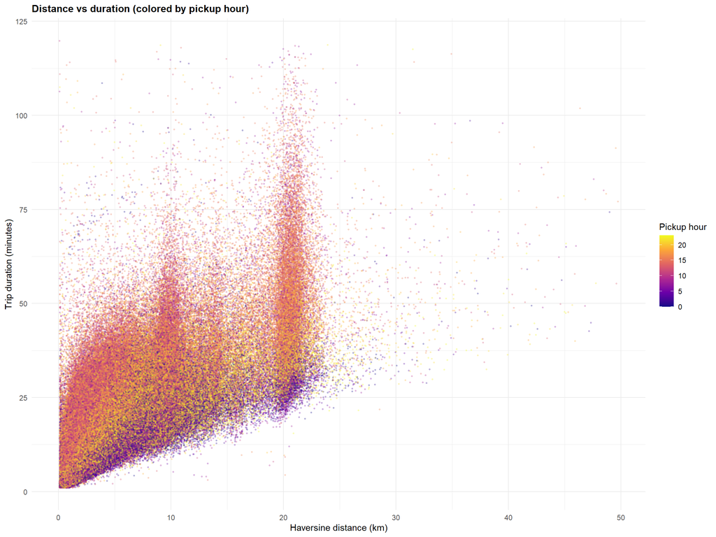

```r
# Filter to reasonable distances and durations for readability
nyc_filtered <- df_train_features %>%
  dplyr::filter(
    haversine_distance >= 0.1 & haversine_distance <= 50,
    trip_duration_min >= 1 & trip_duration_min <= 120
  )

p_dist <- ggplot(nyc_filtered, aes(x = haversine_distance, y = trip_duration_min, color = pickup_hour)) +
  geom_point(alpha = 0.25, size = 0.55) +
  scale_color_viridis_c(option = "C", name = "Pickup hour") +
  labs(
    title = "Distance vs duration (colored by pickup hour)",
    x = "Haversine distance (km)",
    y = "Trip duration (minutes)"
  ) +
  theme_minimal() +
  theme(plot.title = element_text(face = "bold", size = 12))

p_dist
```

**Observations**

- Relation croissante distance ↔︎ durée, conforme au bon sens.
- À distance égale, les trajets aux heures de congestion apparaissent plus longs → justification des variables temporelles (pickup_hour, is_rush_hour, encodage cyclique).

### 5.5.1 Analyse des trajets à distance quasi nulle et durée élevée

En théorie, une distance Haversine proche de zéro correspond à des points de prise en charge et de dépose très proches, et devrait donc s’accompagner d’une **durée très courte**.  
La présence de trajets avec **distance quasi nulle mais durée élevée** suggère des anomalies de mesure (erreurs GPS, arrêts prolongés, trajets circulaires, ou enregistrements défectueux).

Nous analysons ces cas afin d’évaluer leur ampleur et de décider d’un éventuel filtrage.

```r
zero_dist_long <- df_train_features %>%
  filter(haversine_distance < 0.05, trip_duration_min > 20)

nrow(zero_dist_long)
```

```
## [1] 663
```

```r
# Proportion of such trips
nrow(zero_dist_long) / nrow(df_train_features)
```

```
## [1] 0.000654121
```

```r
summary(zero_dist_long$trip_duration_min)
```

```
##    Min. 1st Qu.  Median    Mean 3rd Qu.    Max.
##   20.05   22.77   26.90   31.49   34.27  191.88
```

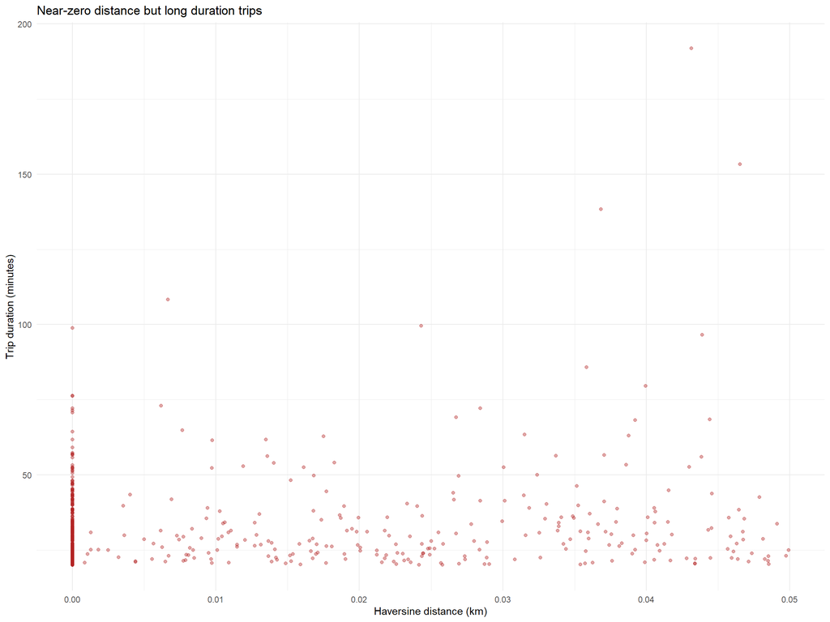

```r
ggplot(zero_dist_long, aes(x = haversine_distance, y = trip_duration_min)) +
  geom_point(alpha = 0.4, color = "firebrick") +
  labs(
    title = "Near-zero distance but long duration trips",
    x = "Haversine distance (km)",
    y = "Trip duration (minutes)"
  ) +
  theme_minimal()
```

**Interprétation**

- Ces trajets représentent une **fraction très faible** du jeu de données (0.065%).
- Ils violent la relation physique distance ↔︎ durée attendue.
- Ils sont très probablement dus à :
  - erreurs GPS,
  - positions de dépose incorrectes,
  - arrêts prolongés moteur allumé,
  - ou enregistrements défectueux.

Conserver ces observations introduirait un **bruit non informatif** susceptible de dégrader l’apprentissage des modèles.

```r
df_train_features <- df_train_features %>%
  filter(!(haversine_distance < 0.05 & trip_duration_min > 20))
```

**Conclusion**

Les trajets présentant une **distance quasi nulle associée à une durée élevée** sont considérés comme aberrants et supprimés. Ce filtrage améliore la cohérence physique du jeu de données et renforce la capacité du modèle à apprendre une relation réaliste entre distance, conditions de trafic et durée.

## 5.6 Spécificité des trajets aéroport

Amélioration : on regroupe JFK + LGA en une variable unique is_airport_trip (utile pour le modèle, plus robuste).

```r
# Airport vs non-airport (combine JFK and LGA flags)
airport_data <- df_train_features %>%
  dplyr::mutate(
    is_airport_trip = as.integer(is_jfk_trip == 1 | is_lga_trip == 1),
    trip_type = ifelse(is_airport_trip == 1, "Airport", "Non-airport")
  ) %>%
  dplyr::filter(trip_duration_min <= 60) %>%
  dplyr::sample_n(min(50000, dplyr::n()))  # keep plot light
```

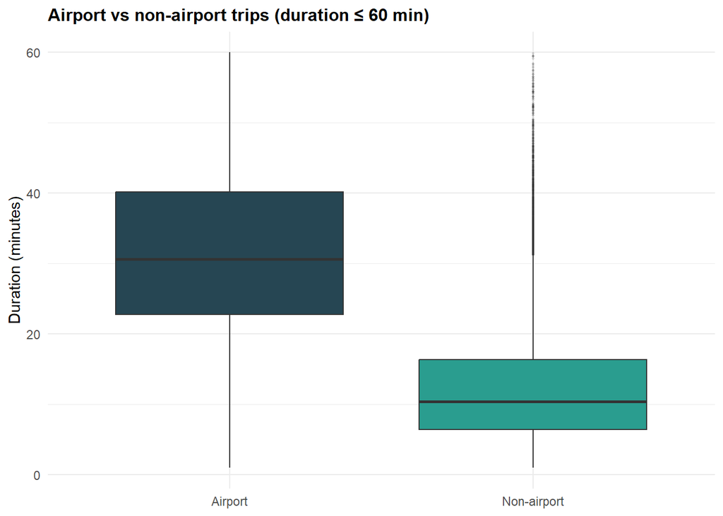

```r
p_airport <- ggplot(airport_data, aes(x = trip_type, y = trip_duration_min, fill = trip_type)) +
  geom_boxplot(outlier.alpha = 0.15, outlier.size = 0.4) +
  scale_fill_manual(values = c("Airport" = "#264653", "Non-airport" = "#2A9D8F")) +
  labs(
    title = "Airport vs non-airport trips (duration ≤ 60 min)",
    x = NULL,
    y = "Duration (minutes)"
  ) +
  theme_minimal() +
  theme(
    legend.position = "none",
    plot.title = element_text(face = "bold", size = 12)
  )

p_airport
```

**Observations**

- Les trajets “Airport” ont une distribution de durée distincte (médiane + dispersion plus élevées).
- La feature is_airport_trip (binaire) est pertinente pour isoler un sous-segment structurellement différent.

## 5.7 Direction et vitesse : validation comportementale

### 5.7.1 Distribution directionnelle

Objectif : vérifier la cohérence de direction avec une ville “en grille” (axes dominants).

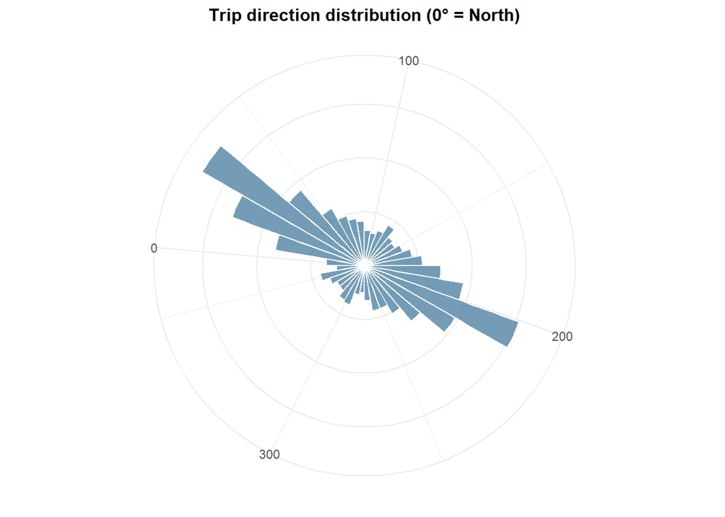

```r
p_dir <- ggplot(df_train_features %>% dplyr::sample_n(min(200000, nrow(df_train_features))),
                aes(x = direction)) +
  geom_histogram(bins = 36, fill = "#457B9D", alpha = 0.75, color = "white") +
  coord_polar(start = -pi/2, direction = 1) +
  labs(title = "Trip direction distribution (0° = North)", x = NULL, y = NULL) +
  theme_minimal() +
  theme(
    axis.text.y = element_blank(),
    plot.title = element_text(face = "bold", size = 12, hjust = 0.5)
  )

p_dir
```

**Observations**

La distribution angulaire montre des directions dominantes cohérentes avec Manhattan (axes Nord–Sud + diagonales liées aux grands axes).

### 5.7.2 Vitesse moyenne par heure

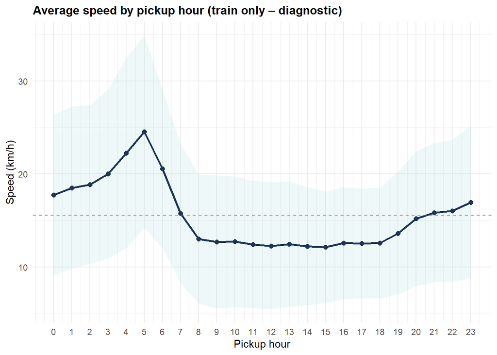

```r
speed_data <- df_train_features %>%
  dplyr::filter(!is.na(avg_speed_kmh), avg_speed_kmh > 0, avg_speed_kmh < 80) %>% # avoid crazy speeds
  dplyr::group_by(pickup_hour) %>%
  dplyr::summarise(
    mean_speed = mean(avg_speed_kmh, na.rm = TRUE),
    sd_speed   = sd(avg_speed_kmh, na.rm = TRUE),
    .groups = "drop"
  ) %>%
  dplyr::mutate(
    lower = pmax(mean_speed - sd_speed, 0),
    upper = mean_speed + sd_speed
  )

overall_mean <- mean(speed_data$mean_speed, na.rm = TRUE)

p_speed <- ggplot(speed_data, aes(x = pickup_hour)) +
  geom_ribbon(aes(ymin = lower, ymax = upper), alpha = 0.20, fill = "#A8DADC") +
  geom_line(aes(y = mean_speed), linewidth = 1, color = "#1D3557") +
  geom_point(aes(y = mean_speed), size = 2, color = "#1D3557") +
  geom_hline(yintercept = overall_mean, color = "#E63946", linetype = "dashed", alpha = 0.7) +
  scale_x_continuous(breaks = 0:23) +
  labs(
    title = "Average speed by pickup hour (train only – diagnostic)",
    x = "Pickup hour",
    y = "Speed (km/h)"
  ) +
  theme_minimal() +
  theme(plot.title = element_text(face = "bold", size = 12))

p_speed
```

**Observations**

- Vitesse plus élevée la nuit / tôt le matin, et chute sur les heures actives → cohérent avec la congestion.
- Cette courbe confirme indirectement la pertinence des features is_rush_hour, encodage cyclique, etc.

```r
df_speed_map <- df_train_features %>%
  dplyr::filter(!is.na(avg_speed_kmh), avg_speed_kmh > 0, avg_speed_kmh < 80) %>%
  dplyr::mutate(
    # grid size ~ 0.002 deg ≈ 200m (tune 0.001–0.005)
    lon_bin = round(pickup_longitude / 0.002) * 0.002,
    lat_bin = round(pickup_latitude  / 0.002) * 0.002
  ) %>%
  dplyr::group_by(lon_bin, lat_bin) %>%
  dplyr::summarise(
    mean_speed = mean(avg_speed_kmh, na.rm = TRUE),
    n = dplyr::n(),
    .groups = "drop"
  ) %>%
  dplyr::filter(n >= 5)  # avoid noisy cells; tune threshold


# 1. Palette "Frontière" : Rouge strict sous 15km/h
custom_pal_strict_15 <- list(
  list(0, "#FF0000"),      # 13 km/h : ROUGE
  list(0.285, "#FF0000"),  # 15 km/h : TOUJOURS ROUGE
  list(0.286, "#FF8C00"),  # > 15 km/h : ORANGE
  list(1, "#FFFF00")       # 20 km/h : JAUNE
)

p_speed_map_plotly <- plot_ly(df_speed_map) %>%
  plotly::add_trace(
    type = 'scattermapbox',
    lat = ~lat_bin,
    lon = ~lon_bin,
    # On enlève 'color' d'ici pour éviter la double légende
    mode = 'markers',
    showlegend = FALSE,
    marker = list(
      # On définit TOUT le style ici
      color = ~mean_speed,
      colorscale = custom_pal_strict_15,
      cmin = 13,                # Note: c'est cmin/cmax pour les markers
      cmax = 20,
      size = 5,
      opacity = 1,
      showscale = TRUE,         # Affiche UNE SEULE barre
      colorbar = list(
        title = "km/h",
        thickness = 20,
        x = 1                   # Force la position à droite
      )
    ),
    text = ~paste0("Vitesse : ", round(mean_speed, 1), " km/h"),
    hoverinfo = "text"
  ) %>%
  plotly::layout(
    title = list(
      text = "<b>Vitesse moyenne en km/h à New-York par zone de pickup</b>",
      font = list(size = 18),
      y = 0.98
    ),
    mapbox = list(
      style = "open-street-map",
      zoom = 9,
      center = list(lat = 40.707, lon = -74.011)
    ),
    margin = list(l = 0, r = 0, t = 60, b = 0)
  )

p_speed_map_plotly
```

[interactive chart not shown]

**Observations**

Ce graphique représente la vitesse moyenne des trajets en fonction de la localisation des points de prise en charge, agrégée par zones spatiales.

- La zone de Manhattan apparaît clairement comme un bloc dense avec des vitesses majoritairement faibles à modérées (≈ 10–18 km/h).
- Les zones périphériques (Queens, Brooklyn Est, zones proches des aéroports) présentent des vitesses plus élevées (≈ 20–30 km/h).

Cela confirme que la congestion urbaine est fortement dépendante de la localisation, même à distance comparable.

**Conclusion de la section “validation spatiale & comportementale”**

- La carte de densité confirme un service centré sur Manhattan, avec des extensions naturelles.
- La relation distance-durée est forte, et modulée par le contexte temporel (heures de congestion).
- Les trajets aéroport constituent un segment spécifique : is_airport_trip est une feature simple et très utile.
- Direction et vitesse (diagnostic) sont cohérentes avec la structure urbaine et la congestion.

# 6 Correlation Analysis

**Objectif** : mesurer l’association linéaire (Pearson) entre chaque variable numérique et la cible trip_duration (en secondes). Utile pour repérer rapidement les variables fortement liées à la durée (distance, etc.) et la redondance / multicolinéarité entre features. *Limites* : une corrélation faible n’implique pas “inutile” (relations non linéaires, effets seuils, interactions…)

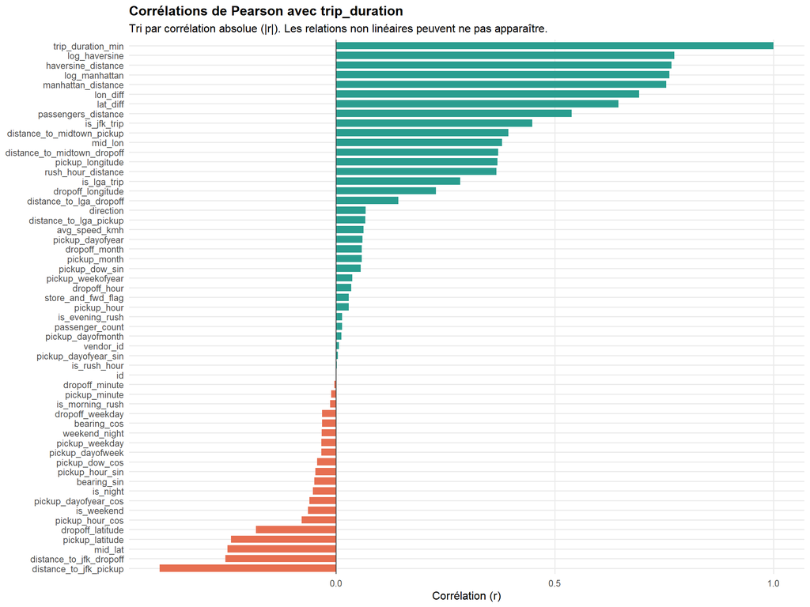

```r
num_cols <- df_train_features %>%
  dplyr::select(where(is.numeric)) %>%
  names()

corr_matrix <- df_train_features %>%
  dplyr::select(all_of(num_cols)) %>%
  cor(use = "complete.obs", method = "pearson")

target_name <- "trip_duration"

target_corr <- corr_matrix[target_name, ] %>%
  as.numeric()
names(target_corr) <- colnames(corr_matrix)

target_corr <- target_corr[names(target_corr) != target_name]

target_corr <- target_corr[order(abs(target_corr), decreasing = TRUE)]

target_corr_df <- tibble::tibble(
  feature = names(target_corr),
  correlation = as.numeric(target_corr),
  sign = ifelse(correlation >= 0, "positive", "negative")
) %>%
  dplyr::mutate(feature = forcats::fct_reorder(feature, correlation))

p_corr <- ggplot(target_corr_df, aes(x = correlation, y = feature, fill = sign)) +
  geom_col(width = 0.75) +
  geom_vline(xintercept = 0, color = "grey20", linewidth = 0.4) +
  scale_fill_manual(
    values = c("positive" = "#2A9D8F", "negative" = "#E76F51")
  ) +
  labs(
    title = "Corrélations de Pearson avec trip_duration",
    subtitle = "Tri par corrélation absolue (|r|). Les relations non linéaires peuvent ne pas apparaître.",
    x = "Corrélation (r)",
    y = NULL
  ) +
  theme_minimal(base_size = 12) +
  theme(
    legend.position = "none",
    plot.title = element_text(face = "bold"),
    panel.grid.minor = element_blank()
  )

p_corr
```

**Matrice de corrélation** (selective)

**Objectif** : détecter la multicolinéarité entre variables explicatives

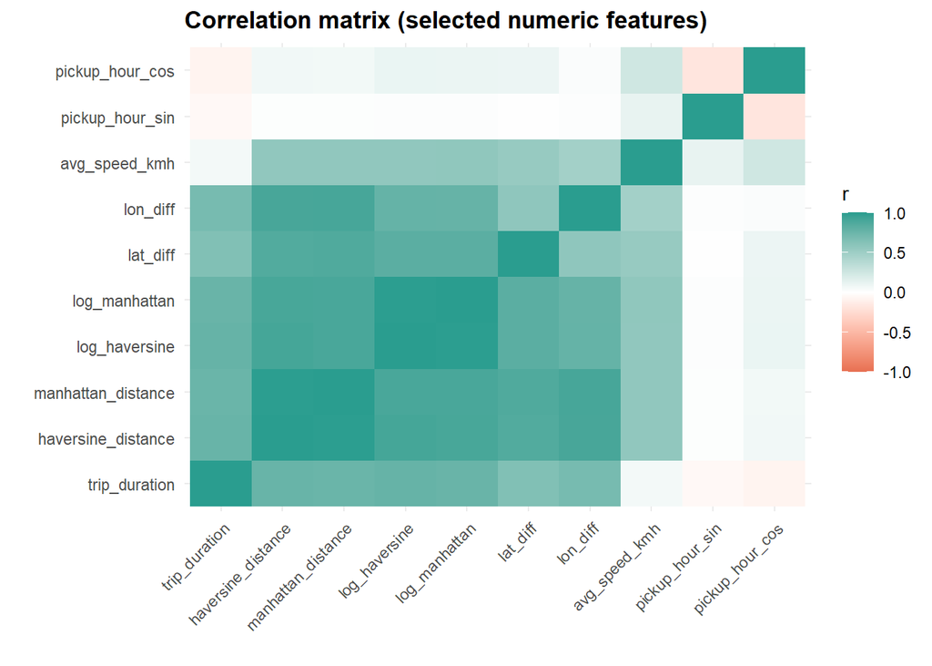

```r
key_features <- c(
  "trip_duration",
  "haversine_distance",
  "manhattan_distance",
  "log_haversine",
  "log_manhattan",
  "lat_diff",
  "lon_diff",
  "avg_speed_kmh",
  "pickup_hour_sin",
  "pickup_hour_cos"
)

corr_sub <- df_train_features %>%
  dplyr::select(all_of(key_features)) %>%
  cor(use = "complete.obs")

library(reshape2)
corr_long <- melt(corr_sub)

p_mat <- ggplot(corr_long, aes(Var1, Var2, fill = value)) +
  geom_tile() +
  scale_fill_gradient2(
    low = "#E76F51",
    mid = "white",
    high = "#2A9D8F",
    midpoint = 0,
    limits = c(-1, 1),
    name = "r"
  ) +
  labs(
    title = "Correlation matrix (selected numeric features)",
    x = "", y = ""
  ) +
  theme_minimal(base_size = 11) +
  theme(
    axis.text.x = element_text(angle = 45, hjust = 1),
    plot.title = element_text(face = "bold")
  )

p_mat
```

## 6.1 Analyse de Corrélation de Pearson (cible : `trip_duration`)

Les graphiques présentent les associations **linéaires** entre les variables numériques et la durée du trajet (`trip_duration`), ainsi que les relations entre prédicteurs eux-mêmes.  
Les barres **turquoise** indiquent une corrélation positive, les barres **corail** une corrélation négative.

**1) Variables dominantes**

- La **distance** est de loin le facteur le plus déterminant :  
  `haversine_distance`, `manhattan_distance`, `log_haversine`, `log_manhattan`, ainsi que `lat_diff` et `lon_diff` présentent les corrélations positives les plus élevées avec la durée.
- Les versions **log-transformées** conservent une forte corrélation tout en comprimant les grandes valeurs, ce qui est favorable pour les modèles linéaires.

La matrice de corrélation confirme que toutes ces mesures de distance sont **fortement corrélées entre elles**, ce qui traduit une redondance importante.

**3) Corrélation faible ne signifie pas qu’une variable est inutile**

Les variables temporelles (heure encodée sin/cos, week-end, rush hour, nuit) présentent des corrélations proches de zéro avec la durée prise isolément.  
Cela suggère :

- des effets **non linéaires**,
- des effets **conditionnels à la distance**,
- ou des effets **localisés** (certaines heures/zones seulement).

Ces variables restent donc pertinentes, surtout via des **interactions**.

**Apport de la matrice de corrélation**

- Elle met en évidence une **forte multicolinéarité** entre les mesures de distance.
- Elle confirme que les variables temporelles sont relativement indépendantes des distances, ce qui est favorable pour les combiner dans un modèle.

**Implications pour la modélisation**

- **Réduction de redondance** :
  - Conserver une ou deux mesures de distance (ex. `log_haversine` seule, ou `log_haversine` + `lat_diff`),
  - ou utiliser une régularisation (Ridge/Lasso).
- **Transformer plutôt que supprimer** :
  - Privilégier les distances log-transformées.
- **Introduire des interactions** :
  - `log_haversine × is_rush_hour`
  - `log_haversine × pickup_hour_sin/cos`
  - `log_haversine × is_weekend`

**Conclusion synthétique**

La durée des trajets est principalement expliquée par la **distance**, tandis que les variables temporelles jouent un rôle d’**ajustement contextuel**.  
Un modèle performant devra donc combiner :

**Distance (transformée) + Temps + Interactions Distance × Temps**

# 7 Data Preprocessing

## 7.1 Sélection des variables (Feature Selection)

L’objectif de cette étape est de constituer un jeu de variables parcimonieux et robuste, en ne gardant que les features qui apportent une valeur ajoutée pour prédire `trip_duration`.

Nos analyses précédentes montrent que :

- La **distance** est le déterminant principal de la durée, mais plusieurs mesures (Haversine, Manhattan, deltas lat/lon) sont **très colinéaires**. Mais dans un premier temps plusieurs métriques de distance (Haversine, Manhattan et leurs versions logarithmiques) sont conservées comme **candidats**. Bien qu’elles soient corrélées entre elles, leur maintien temporaire permet de comparer empiriquement leur valeur prédictive. La sélection finale s’appuiera sur les performances en validation et/ou la régularisation afin de ne conserver qu’un sous-ensemble non redondant.
- Les variables **temporelles** (heure, jour, rush hour) ont souvent des effets **non linéaires** et/ou **conditionnels à la distance** : on les conserve, ainsi que certaines interactions.
- Les trajets **aéroport** constituent un régime spécifique : on conserve des indicateurs dédiés (`is_jfk_trip`, `is_lga_trip`).
- Certaines variables sont peu informatives (ex. `store_and_fwd_flag` quasi constant) ou risquent d’introduire de la fuite de cible (ex. `avg_speed_kmh` dérivée de `trip_duration`) : elles sont exclues dès le départ.

Nous adoptons donc une stratégie **progressive (forward)** : 1) un **modèle de base** avec les variables à fort signal,  
2) l’ajout par blocs (interactions, géographie) uniquement si cela améliore les performances en validation.

```r
# Distance representations (kept as candidates)
distance_features <- c(
  "haversine_distance",
  "log_haversine",
  "manhattan_distance",
  "log_manhattan"
)

# Core temporal features (cyclical + flags)
temporal_features <- c(
  "pickup_hour_sin", "pickup_hour_cos",
  "pickup_dow_sin",  "pickup_dow_cos",
  "is_rush_hour",
  "is_weekend",
  "is_night"
)

# Contextual trip features
context_features <- c(
  "is_jfk_trip",
  "is_lga_trip",
  "vendor_id",
  "passenger_count"
)

# Spatial geometry features
spatial_features <- c(
  "bearing_sin", "bearing_cos",
  "mid_lat", "mid_lon"
)

# Interaction features
interaction_features <- c(
  "rush_hour_distance",
  "weekend_night",
  "passengers_distance"
)

feature_cols <- c(
  distance_features,
  temporal_features,
  context_features,
  spatial_features,
  interaction_features
)

# Remove potential duplicates
feature_cols <- unique(feature_cols)

cat(sprintf("Number of candidate features: %d\n", length(feature_cols)))
```

```
## Number of candidate features: 22
```

```r
print(feature_cols)
```

```
##  [1] "haversine_distance"  "log_haversine"       "manhattan_distance"
##  [4] "log_manhattan"       "pickup_hour_sin"     "pickup_hour_cos"
##  [7] "pickup_dow_sin"      "pickup_dow_cos"      "is_rush_hour"
## [10] "is_weekend"          "is_night"            "is_jfk_trip"
## [13] "is_lga_trip"         "vendor_id"           "passenger_count"
## [16] "bearing_sin"         "bearing_cos"         "mid_lat"
## [19] "mid_lon"             "rush_hour_distance"  "weekend_night"
## [22] "passengers_distance"
```

## 7.2 Préparation des données pour la modélisation

**Objectifs :**

1. Construire la matrice de variables explicatives **X** à partir de la liste `feature_cols`.
2. Définir la cible **y** sous forme log-transformée (*log1p*) afin de :
   - réduire l’asymétrie de `trip_duration`,
   - stabiliser la variance,
   - limiter l’influence des valeurs extrêmes.
3. Séparer le jeu de données en **train / validation (80 % / 20 %)** en conservant une distribution comparable de la cible  
   (stratification approximative via `createDataPartition`).
4. Standardiser les variables de **X** (centrage / réduction) en ajustant le scaler uniquement sur le jeu d’entraînement, puis en l’appliquant au jeu de validation, afin d’éviter toute **fuite d’information (data leakage)**

```r
# Matrice X et cible y
stopifnot(all(feature_cols %in% colnames(df_train_features)))

X <- df_train_features %>%
  dplyr::select(all_of(feature_cols))

y <- log1p(df_train_features$trip_duration)  # cible en log

# Split train/validation (stratification approximative sur y)
set.seed(RANDOM_STATE)
train_index <- caret::createDataPartition(y, p = 0.8, list = FALSE)

X_train <- X[train_index, , drop = FALSE]
X_val   <- X[-train_index, , drop = FALSE]
y_train <- y[train_index]
y_val   <- y[-train_index]

# Normalisation (center/scale) sur train uniquement
scaler <- caret::preProcess(X_train, method = c("center", "scale"))

X_train_scaled <- predict(scaler, X_train)
X_val_scaled   <- predict(scaler, X_val)

# Check dimensions + sanity checks
cat(sprintf("X_train: %d lignes, %d colonnes\n", nrow(X_train_scaled), ncol(X_train_scaled)))
```

```
## X_train: 810331 lignes, 22 colonnes
```

```r
cat(sprintf("X_val  : %d lignes, %d colonnes\n", nrow(X_val_scaled), ncol(X_val_scaled)))
```

```
## X_val  : 202580 lignes, 22 colonnes
```

```r
# Check NA absence after scaling
cat(sprintf("NA in X_train_scaled: %d\n", sum(!is.finite(as.matrix(X_train_scaled)))))
```

```
## NA in X_train_scaled: 0
```

```r
cat(sprintf("NA in X_val_scaled  : %d\n", sum(!is.finite(as.matrix(X_val_scaled)))))
```

```
## NA in X_val_scaled  : 0
```

# 8 Modélisation

## 8.1 Baselines (références minimales)

**Objectif** : avoir une référence “bête” (moyenne / médiane) pour quantifier le gain réel de nos modèles

```r
rmse <- function(y_true, y_pred) sqrt(mean((y_true - y_pred)^2))

y_train_sec <- expm1(y_train)
y_val_sec   <- expm1(y_val)

# Baseline mean/median on train
pred_mean   <- rep(mean(y_train_sec), length(y_val_sec))
pred_median <- rep(median(y_train_sec), length(y_val_sec))

rmse_mean   <- rmse(y_val_sec, pred_mean)
rmse_median <- rmse(y_val_sec, pred_median)

cat("Baselines (validation)\n")
```

```
## Baselines (validation)
```

```r
cat(sprintf("- Mean predictor   RMSE: %.2f sec\n", rmse_mean))
```

```
## - Mean predictor   RMSE: 663.78 sec
```

```r
cat(sprintf("- Median predictor RMSE: %.2f sec\n", rmse_median))
```

```
## - Median predictor RMSE: 686.93 sec
```

## 8.2 Régression Linéaire

La régression linéaire constitue le cœur de ce projet.  
Elle permet d’établir un lien explicite entre les variables explicatives et la durée du trajet, tout en fournissant une base interprétable pour évaluer l’apport des modèles plus complexes.

Nous modélisons la variable cible transformée :

$$\log(1 + \text{trip\_duration}) = \beta_0 + \sum_{j=1}^{p} \beta_j X_j +
\varepsilon$$

où :

- $X_j$ sont les variables explicatives,
- $\beta_j$ les coefficients associés,
- $\varepsilon$ un terme d’erreur aléatoire.

### 8.2.1 Modèle linéaire complet (diagnostic — multicolinéarité)

```r
# Prepare training dataframe
train_data <- X_train_scaled %>%
  mutate(y = y_train)

# Fit linear regression
lr_model <- lm(y ~ ., data = train_data)

# Summary of the model
summary(lr_model)
```

```
##
## Call:
## lm(formula = y ~ ., data = train_data)
##
## Residuals:
##     Min      1Q  Median      3Q     Max
## -2.4886 -0.2496 -0.0042  0.2417  6.0074
##
## Coefficients:
##                       Estimate Std. Error   t value Pr(>|t|)
## (Intercept)          6.480e+00  4.540e-04 14270.891  < 2e-16 ***
## haversine_distance  -4.314e-01  7.406e-03   -58.250  < 2e-16 ***
## log_haversine        1.331e+00  7.400e-03   179.846  < 2e-16 ***
## manhattan_distance   1.649e-01  7.028e-03    23.467  < 2e-16 ***
## log_manhattan       -4.937e-01  6.945e-03   -71.088  < 2e-16 ***
## pickup_hour_sin     -8.882e-02  5.307e-04  -167.372  < 2e-16 ***
## pickup_hour_cos     -1.592e-01  7.626e-04  -208.751  < 2e-16 ***
## pickup_dow_sin       2.911e-02  7.557e-04    38.526  < 2e-16 ***
## pickup_dow_cos      -4.219e-02  4.805e-04   -87.806  < 2e-16 ***
## is_rush_hour         1.879e-02  6.383e-04    29.439  < 2e-16 ***
## is_weekend          -5.521e-02  8.239e-04   -67.005  < 2e-16 ***
## is_night            -5.105e-04  8.621e-04    -0.592    0.554
## is_jfk_trip          1.007e-02  9.652e-04    10.437  < 2e-16 ***
## is_lga_trip         -1.512e-02  5.873e-04   -25.750  < 2e-16 ***
## vendor_id            1.489e-05  4.742e-04     0.031    0.975
## passenger_count      9.312e-03  6.213e-04    14.987  < 2e-16 ***
## bearing_sin         -4.032e-03  4.850e-04    -8.313  < 2e-16 ***
## bearing_cos         -1.724e-02  4.812e-04   -35.822  < 2e-16 ***
## mid_lat             -4.635e-02  5.739e-04   -80.763  < 2e-16 ***
## mid_lon             -3.825e-02  7.582e-04   -50.443  < 2e-16 ***
## rush_hour_distance   1.188e-02  6.544e-04    18.151  < 2e-16 ***
## weekend_night        7.395e-02  6.552e-04   112.872  < 2e-16 ***
## passengers_distance -5.300e-03  8.451e-04    -6.271 3.58e-10 ***
## ---
## Signif. codes:  0 '***' 0.001 '**' 0.01 '*' 0.05 '.' 0.1 ' ' 1
##
## Residual standard error: 0.4087 on 810308 degrees of freedom
## Multiple R-squared:  0.685,  Adjusted R-squared:  0.685
## F-statistic: 8.01e+04 on 22 and 810308 DF,  p-value: < 2.2e-16
```

**Observations**

- Le modèle explique une part importante de la variance (R² ajusté = 0.685), ce qui confirme que l’ingénierie de variables capture déjà l’essentiel de la structure du phénomène.
- Les distances (`log_haversine`, `log_manhattan`, `haversine_distance`, `manhattan_distance`) dominent très largement, ce qui est cohérent avec l’analyse exploratoire.
- Les variables temporelles cycliques (`pickup_hour_sin/cos`, `pickup_dow_cos`) présentent également des effets très significatifs.
- La quasi-totalité des coefficients est hautement significative (p-value ≪ 0.001), ce qui confirme une forte puissance statistique due à la taille massive de l’échantillon.
- Ce modèle sert de **référence initiale**, mais il souffre de multicolinéarité élevée (voir VIF ci-dessous).

#### 8.2.1.1 Prédictions et Performance

```r
# Predict on validation set (log scale)
y_pred_lr_log <- predict(lr_model, newdata = X_val_scaled)

# Back-transform to seconds
y_pred_lr_sec <- pmax(expm1(y_pred_lr_log), 0)

# True values in seconds
y_val_sec <- expm1(y_val)

# Compute RMSE and R2
rmse_lr <- sqrt(mean((y_val_sec - y_pred_lr_sec)^2))
r2_lr <- 1 - sum((y_val_sec - y_pred_lr_sec)^2) /
  sum((y_val_sec - mean(y_val_sec))^2)

cat(sprintf("Linear Regression RMSE: %.2f seconds\n", rmse_lr))
```

```
## Linear Regression RMSE: 384.85 seconds
```

```r
cat(sprintf("Linear Regression R²: %.4f\n", r2_lr))
```

```
## Linear Regression R²: 0.6638
```

#### 8.2.1.2 Vérification des Hypothèses du Modèle

Les hypothèses classiques de la régression linéaire sont évaluées graphiquement :

- Linéarité
- Normalité des résidus
- Homoscédasticité
- Indépendance approximative

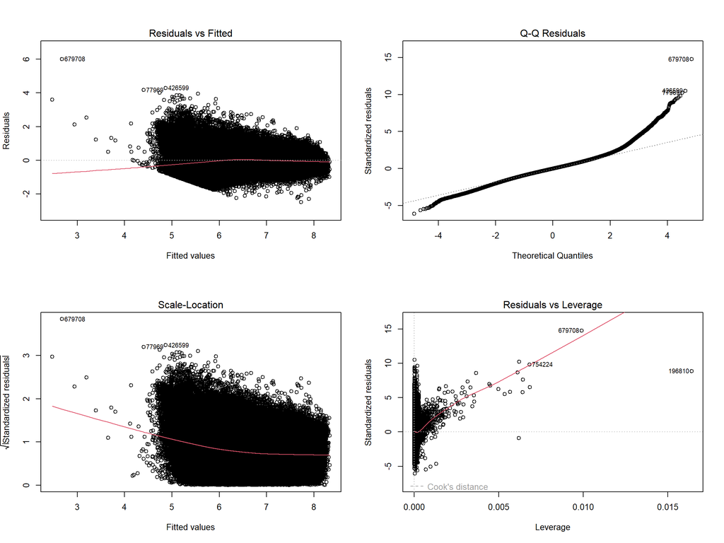

```r
# Diagnostic plots
par(mfrow = c(2,2))
plot(lr_model)
```

```r
par(mfrow = c(1,1))
```

**Observations**

**a) Linéarité (Residuals vs Fitted)**

Le nuage de points montre une structure globalement centrée autour de zéro, ce qui indique que la relation moyenne entre les prédicteurs et la cible est correctement capturée.

Cependant :

- On observe une **légère courbure** de la ligne de tendance.
- La dispersion des résidus varie selon le niveau des valeurs ajustées.

La relation n’est donc **pas parfaitement linéaire**, mais reste suffisamment proche pour justifier un modèle linéaire comme point de départ.

**b) Normalité des résidus (Q–Q Plot)**

Le Q–Q plot montre :

- Un alignement correct au centre,
- Des écarts visibles dans les **queues** (extrêmes).

Les résidus ne sont **pas parfaitement gaussiens**, mais la normalité est acceptable compte tenu :

- de la très grande taille de l’échantillon,
- de l’utilisation d’une transformation logarithmique de la cible.

**c) Homoscédasticité (Scale–Location)**

Le graphique montre une pente descendante :

- La variance des résidus diminue lorsque la valeur ajustée augmente.

Il existe une **hétéroscédasticité modérée** : l’erreur n’est pas constante.

**d) Observations influentes (Residuals vs Leverage)**

La majorité des observations possède un faible leverage.

Quelques points dépassent légèrement les courbes de Cook, mais :

- Ils sont très rares,
- Leur suppression n’est pas justifiée à ce stade.

Aucun point unique ne domine excessivement l’estimation.

**Conclusion sur les hypothèses**

Le modèle linéaire ne satisfait pas parfaitement toutes les hypothèses, mais :

- Il constitue un **bon modèle de référence interprétable**,
- Les écarts observés motivent l’usage ultérieur de :
  - régularisation (Ridge / Lasso),
  - modèles non linéaires (XGBoost).

Nous pouvons donc poursuivre avec l’analyse de la multicolinéarité.

#### 8.2.1.3 Multicolinéarité (Variance Inflation Factor)

```r
vif_values <- vif(lr_model)

# Display sorted VIF table
vif_df <- data.frame(
  Feature = names(vif_values),
  VIF = as.numeric(vif_values)
) %>%
  arrange(desc(VIF))

head(vif_df, 20)
```

```
##                Feature        VIF
## 1   haversine_distance 266.097785
## 2        log_haversine 265.596099
## 3   manhattan_distance 239.571445
## 4        log_manhattan 233.960306
## 5          is_jfk_trip   4.519135
## 6             is_night   3.605389
## 7  passengers_distance   3.464412
## 8           is_weekend   3.292915
## 9      pickup_hour_cos   2.821016
## 10             mid_lon   2.788612
## 11      pickup_dow_sin   2.769990
## 12       weekend_night   2.082220
## 13  rush_hour_distance   2.077091
## 14        is_rush_hour   1.976240
## 15     passenger_count   1.872728
## 16         is_lga_trip   1.673162
## 17             mid_lat   1.597653
## 18     pickup_hour_sin   1.366074
## 19         bearing_sin   1.140848
## 20         bearing_cos   1.123409
```

**Diagnostic de multicolinéarité**

- Les VIF extrêmement élevés (>200) pour les différentes mesures de distance confirment une redondance sévère.
- Les autres variables présentent des VIF modérés (<5), considérés acceptables.
- Cela motive une **sélection progressive** des distances (conserver 1–2 représentations maximum) ou l’usage de régularisation (Ridge/Lasso).

### 8.2.2 Interprétation des Coefficients

Nous analysons les variables ayant l’impact le plus fort (en valeur absolue).

```r
# Extract coefficients
coef_table <- summary(lr_model)$coefficients

coef_df <- data.frame(
  Feature = rownames(coef_table),
  Estimate = coef_table[,1],
  Std_Error = coef_table[,2],
  t_value = coef_table[,3],
  p_value = coef_table[,4]
) %>%
  filter(Feature != "(Intercept)") %>%
  arrange(desc(abs(Estimate)))

head(coef_df, 10)
```

```
##                               Feature    Estimate    Std_Error    t_value
## log_haversine           log_haversine  1.33077429 0.0073995149  179.84615
## log_manhattan           log_manhattan -0.49369764 0.0069448600  -71.08821
## haversine_distance haversine_distance -0.43142853 0.0074065001  -58.24999
## manhattan_distance manhattan_distance  0.16491492 0.0070276468   23.46659
## pickup_hour_cos       pickup_hour_cos -0.15919267 0.0007625972 -208.75066
## pickup_hour_sin       pickup_hour_sin -0.08882030 0.0005306761 -167.37196
## weekend_night           weekend_night  0.07395082 0.0006551726  112.87228
## is_weekend                 is_weekend -0.05520656 0.0008239154  -67.00513
## mid_lat                       mid_lat -0.04634961 0.0005738966  -80.76300
## pickup_dow_cos         pickup_dow_cos -0.04219028 0.0004804922  -87.80638
##                          p_value
## log_haversine       0.000000e+00
## log_manhattan       0.000000e+00
## haversine_distance  0.000000e+00
## manhattan_distance 9.831369e-122
## pickup_hour_cos     0.000000e+00
## pickup_hour_sin     0.000000e+00
## weekend_night       0.000000e+00
## is_weekend          0.000000e+00
## mid_lat             0.000000e+00
## pickup_dow_cos      0.000000e+00
```

**Conclusion** : Ce modèle global valide la pertinence des familles de variables, mais il n’est pas destiné à être le modèle final.  
Il constitue un point de départ pour une **sélection progressive**.

### 8.2.3 Sélection progressive des variables et entraînement des modèles

**Définition des blocs de variables candidates**

```r
#  Distance representations (we will compare alternatives)
distance_set_A <- c("log_haversine")      # preferred baseline
distance_set_B <- c("log_manhattan")      # alternative baseline
distance_set_C <- c("log_haversine", "manhattan_distance")

# Temporal features
temporal_features <- c(
  "pickup_hour_sin", "pickup_hour_cos",
  "pickup_dow_sin",  "pickup_dow_cos",
  "is_rush_hour",
  "is_weekend",
  "is_night"
)

# Context features
context_features <- c(
  "is_jfk_trip",
  "is_lga_trip",
  "vendor_id",
  "passenger_count"
)

# Spatial geometry features
spatial_features <- c(
  "bearing_sin", "bearing_cos",
  "mid_lat", "mid_lon"
)

# Interaction features
interaction_features <- c(
  "rush_hour_distance",
  "weekend_night",
  "passengers_distance"
)
```

**Vérifications de sécurité des variables**

```r
# check_features_exist <- function(df, feats) {
#   missing <- setdiff(feats, colnames(df))
#   if (length(missing) > 0) {
#     stop("Missing features in df_train_features: ", paste(missing, collapse = ", "))
#   }
#   invisible(TRUE)
# }
#
ensure_numeric <- function(df, feats) {
  out <- df[, feats, drop = FALSE]
  for (nm in names(out)) {
    if (is.factor(out[[nm]]) || is.character(out[[nm]])) {
      # Convert binary chars/factors safely; for multi-level factors, create dummies separately.
      out[[nm]] <- as.numeric(as.factor(out[[nm]]))
    }
  }
  out
}
```

**Calcul du VIF**

```r
compute_vif <- function(X_df, max_n = 50000, seed = 2025) {
  set.seed(seed)

  # Sample rows to speed up VIF
  n <- nrow(X_df)
  idx <- if (n > max_n) sample.int(n, max_n) else seq_len(n)
  Xs <- as.data.frame(X_df[idx, , drop = FALSE])

  # Remove near-zero variance columns (can break regressions)
  nzv <- sapply(Xs, function(v) sd(v, na.rm = TRUE) == 0)
  if (any(nzv)) Xs <- Xs[, !nzv, drop = FALSE]

  p <- ncol(Xs)
  if (p < 2) return(data.frame(Feature = colnames(Xs), VIF = NA_real_))

  vifs <- numeric(p)
  names(vifs) <- colnames(Xs)

  for (j in seq_len(p)) {
    yj <- Xs[[j]]
    Xj <- Xs[, -j, drop = FALSE]
    # Use lm.fit for speed
    fit <- lm.fit(x = as.matrix(cbind(1, Xj)), y = yj)
    rss <- sum(fit$residuals^2, na.rm = TRUE)
    tss <- sum((yj - mean(yj, na.rm = TRUE))^2, na.rm = TRUE)
    r2  <- ifelse(tss == 0, 1, 1 - rss / tss)
    vifs[j] <- 1 / pmax(1 - r2, 1e-12)
  }

  data.frame(
    Feature = names(vifs),
    VIF = as.numeric(vifs)
  ) %>% dplyr::arrange(dplyr::desc(VIF))
}
```

**Fonction d’entraînement et d’évaluation d’un modèle linéaire**

```r
# Train + evaluate a linear regression for a given feature set
train_eval_lm <- function(feature_cols,
                          df_train_features,
                          y_train,
                          X_val_scaled,
                          y_val,
                          scaler,
                          compute_vif_flag = TRUE) {

  # Build X (raw), then scale consistently using existing scaler
  X_raw <- ensure_numeric(df_train_features, feature_cols)
  X_scaled <- predict(scaler, X_raw)

  train_data <- as.data.frame(X_scaled) %>% dplyr::mutate(y = y_train)

  # Fit model on log target
  lr_model <- lm(y ~ ., data = train_data)

  # Predict on validation (already scaled outside)
  y_pred_log <- predict(lr_model, newdata = as.data.frame(X_val_scaled[, feature_cols, drop = FALSE]))

  # Back-transform to seconds
  y_pred_sec <- pmax(expm1(y_pred_log), 0)
  y_val_sec  <- expm1(y_val)

  rmse_sec <- sqrt(mean((y_val_sec - y_pred_sec)^2, na.rm = TRUE))

  # Optional VIF on a sample
  vif_df <- NULL
  if (compute_vif_flag) {
    vif_df <- compute_vif(as.data.frame(X_scaled[, feature_cols, drop = FALSE]))
  }

  list(
    model = lr_model,
    rmse_sec = rmse_sec,
    vif = vif_df
  )
}
```

**Préparation des jeux d’entraînement et de validation (scaling)**

```r
# Create split + scaling for a given feature set
prep_split_scaled <- function(feature_cols,
                              df_train_features,
                              y,
                              random_state = 2025) {

  X <- ensure_numeric(df_train_features, feature_cols)

  set.seed(random_state)
  train_index <- caret::createDataPartition(y, p = 0.8, list = FALSE)

  X_train <- X[train_index, , drop = FALSE]
  X_val   <- X[-train_index, , drop = FALSE]

  y_train <- y[train_index]
  y_val   <- y[-train_index]

  scaler <- caret::preProcess(X_train, method = c("center", "scale"))
  X_train_scaled <- predict(scaler, X_train)
  X_val_scaled   <- predict(scaler, X_val)

  list(
    X_train_scaled = X_train_scaled,
    X_val_scaled = X_val_scaled,
    y_train = y_train,
    y_val = y_val,
    scaler = scaler,
    train_index = train_index
  )
}
```

**Définition des étapes progressives d’ajout de variables**

```r
make_steps <- function(distance_feats) {
  list(
    step1_distance = distance_feats,
    step2_temporal = c(distance_feats, temporal_features),
    step3_context  = c(distance_feats, temporal_features, context_features),
    step4_spatial  = c(distance_feats, temporal_features, context_features, spatial_features),
    step5_interact = c(distance_feats, temporal_features, context_features, spatial_features, interaction_features)
  )
}
```

**Boucle d’entraînement progressive des modèles linéaires**

```r
run_progressive_lm <- function(distance_feats,
                               df_train_features,
                               random_state = 2025,
                               compute_vif_flag = TRUE) {

  steps <- make_steps(distance_feats)

  # Target (log scale)
  y <- log1p(df_train_features$trip_duration)

  results <- list()
  summary_tbl <- data.frame()

  for (nm in names(steps)) {
    feats <- unique(steps[[nm]])

    # Prepare split/scaling for this feature set
    prep <- prep_split_scaled(
      feature_cols = feats,
      df_train_features = df_train_features,
      y = y,
      random_state = random_state
    )

    # Fit + evaluate
    train_data <- as.data.frame(prep$X_train_scaled) %>% dplyr::mutate(y = prep$y_train)
    lr_model <- lm(y ~ ., data = train_data)

    y_pred_log <- predict(lr_model, newdata = as.data.frame(prep$X_val_scaled))
    y_pred_sec <- pmax(expm1(y_pred_log), 0)
    y_val_sec  <- expm1(prep$y_val)

    rmse_sec <- sqrt(mean((y_val_sec - y_pred_sec)^2, na.rm = TRUE))

    # VIF on sample
    vif_max <- NA_real_
    if (compute_vif_flag) {
      vif_df <- compute_vif(as.data.frame(prep$X_train_scaled))
      vif_max <- max(vif_df$VIF, na.rm = TRUE)
    }

    results[[nm]] <- list(
      features = feats,
      model = lr_model,
      rmse_sec = rmse_sec,
      vif_max = vif_max
    )

    summary_tbl <- rbind(
      summary_tbl,
      data.frame(
        Distance_Set = paste(distance_feats, collapse = " + "),
        Step = nm,
        Num_Features = length(feats),
        RMSE_sec = rmse_sec,
        VIF_max = vif_max
      )
    )

    cat(sprintf("Done %-14s | features=%d | RMSE=%.2f sec | VIF_max=%s\n",
                nm, length(feats), rmse_sec,
                ifelse(is.na(vif_max), "NA", round(vif_max, 2))))
  }

  list(results = results, summary = summary_tbl)
}
```

**Lancement des expériences pour différentes distances**

```r
set.seed(RANDOM_STATE)

out_A <- run_progressive_lm(distance_set_A, df_train_features, random_state = RANDOM_STATE, compute_vif_flag = TRUE)
```

```
## Done step1_distance | features=1 | RMSE=440.09 sec | VIF_max=-Inf
## Done step2_temporal | features=8 | RMSE=421.98 sec | VIF_max=3.21
## Done step3_context  | features=12 | RMSE=411.88 sec | VIF_max=3.21
## Done step4_spatial  | features=16 | RMSE=426.35 sec | VIF_max=3.22
## Done step5_interact | features=19 | RMSE=411.18 sec | VIF_max=3.65
```

```r
out_B <- run_progressive_lm(distance_set_B, df_train_features, random_state = RANDOM_STATE, compute_vif_flag = TRUE)
```

```
## Done step1_distance | features=1 | RMSE=441.85 sec | VIF_max=-Inf
## Done step2_temporal | features=8 | RMSE=422.63 sec | VIF_max=3.21
## Done step3_context  | features=12 | RMSE=410.21 sec | VIF_max=3.21
## Done step4_spatial  | features=16 | RMSE=419.18 sec | VIF_max=3.22
## Done step5_interact | features=19 | RMSE=410.79 sec | VIF_max=3.65
```

```r
out_C <- run_progressive_lm(distance_set_C, df_train_features, random_state = RANDOM_STATE, compute_vif_flag = TRUE)
```

```
## Done step1_distance | features=2 | RMSE=426.35 sec | VIF_max=5.23
## Done step2_temporal | features=9 | RMSE=393.95 sec | VIF_max=5.3
## Done step3_context  | features=13 | RMSE=391.30 sec | VIF_max=9.95
## Done step4_spatial  | features=17 | RMSE=391.33 sec | VIF_max=10
## Done step5_interact | features=20 | RMSE=387.81 sec | VIF_max=11.58
```

```r
progressive_summary <- dplyr::bind_rows(out_A$summary, out_B$summary, out_C$summary) %>%
  dplyr::arrange(RMSE_sec)

progressive_summary
```

```
##                          Distance_Set           Step Num_Features RMSE_sec
## 1  log_haversine + manhattan_distance step5_interact           20 387.8064
## 2  log_haversine + manhattan_distance  step3_context           13 391.2950
## 3  log_haversine + manhattan_distance  step4_spatial           17 391.3283
## 4  log_haversine + manhattan_distance step2_temporal            9 393.9464
## 5                       log_manhattan  step3_context           12 410.2076
## 6                       log_manhattan step5_interact           19 410.7904
## 7                       log_haversine step5_interact           19 411.1772
## 8                       log_haversine  step3_context           12 411.8786
## 9                       log_manhattan  step4_spatial           16 419.1772
## 10                      log_haversine step2_temporal            8 421.9815
## 11                      log_manhattan step2_temporal            8 422.6333
## 12                      log_haversine  step4_spatial           16 426.3486
## 13 log_haversine + manhattan_distance step1_distance            2 426.3489
## 14                      log_haversine step1_distance            1 440.0901
```

[output cut: 17 more lines]

**Évolution du RMSE selon les blocs de variables**

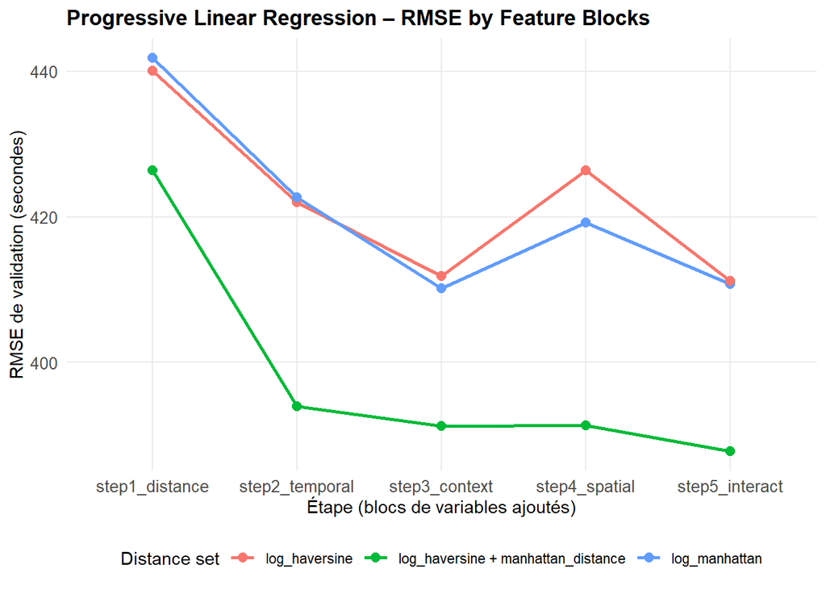

```r
progressive_summary %>%
  dplyr::mutate(
    Step = factor(
      Step,
      levels = c("step1_distance","step2_temporal","step3_context","step4_spatial","step5_interact")
    )
  ) %>%
  ggplot(aes(x = Step, y = RMSE_sec, group = Distance_Set, color = Distance_Set)) +
  geom_line(linewidth = 1) +
  geom_point(size = 2.5) +
  labs(
    title = "Progressive Linear Regression – RMSE by Feature Blocks",
    x = "Étape (blocs de variables ajoutés)",
    y = "RMSE de validation (secondes)",
    color = "Distance set"
  ) +
  theme_minimal() +
  theme(
    plot.title = element_text(size = 13, face = "bold"),
    axis.text.x = element_text(size = 10),
    axis.text.y = element_text(size = 10),
    legend.position = "bottom",
    panel.grid.minor = element_blank()
  )
```

**Conclusion — Sélection progressive des variables**

L’approche incrémentale met clairement en évidence l’impact différencié des blocs de variables sur la performance du modèle linéaire :

- **Les distances seules** constituent une base correcte mais limitée (RMSE ≈ 440 s).
- **L’ajout des variables temporelles** (heures, jours, indicateurs rush/week-end/nuit) apporte un **gain substantiel**, confirmant l’importance du contexte horaire sur la durée des trajets.
- **Les variables contextuelles** (aéroports, vendor, nombre de passagers) améliorent encore la performance, traduisant l’existence de régimes spécifiques de trajets (notamment aéroportuaires).
- **Les variables spatiales** (bearing, midpoint) n’apportent qu’un gain marginal, voire instable selon la configuration.
- **Les interactions** permettent un léger gain supplémentaire, au prix d’une **augmentation modérée de la multicolinéarité** (VIF max ≈ 11).

Le meilleur compromis performance / complexité est obtenu avec le jeu :

qui atteint un **RMSE ≈ 388 secondes** sur validation.

En pratique :

- Pour un **modèle linéaire interprétable**, on privilégiera ce jeu de variables avec une régularisation (Ridge / Elastic Net).
- Pour maximiser la performance, ce jeu servira de base aux modèles plus flexibles (XGBoost, clustering + Elastic Net).

Cette étape valide donc empiriquement la valeur ajoutée de chaque famille de variables et justifie la structure retenue pour la suite de la modélisation.

#### 8.2.3.1 Tentative d’amélioration : rotation de la distance de Manhattan

**Objectif :** - Construire une nouvelle distance “manhattan_rot” (L1 dans un repère tourné) - Tester plusieurs angles θ et comparer le RMSE (sec) au meilleur LR actuel - Garder la meilleure rotation uniquement si elle apporte un gain mesurable

```r
# Baseline: best LR RMSE from progressive loop
best_baseline_rmse <- min(progressive_summary$RMSE_sec, na.rm = TRUE)
cat(sprintf("Best baseline RMSE so far (Linear Regression): %.2f sec\n", best_baseline_rmse))
```

```
## Best baseline RMSE so far (Linear Regression): 387.81 sec
```

```r
# Retrieve best feature configuration (and its feature list)
get_best_feature_list <- function(out_list_A, out_list_B, out_list_C) {
  all_out <- list(A = out_list_A, B = out_list_B, C = out_list_C)
  best_rmse <- Inf
  best_feats <- NULL
  best_step <- NULL
  best_dist <- NULL

  for (name in names(all_out)) {
    obj <- all_out[[name]]
    for (step_nm in names(obj$results)) {
      rmse <- obj$results[[step_nm]]$rmse_sec
      if (!is.na(rmse) && rmse < best_rmse) {
        best_rmse <- rmse
        best_feats <- obj$results[[step_nm]]$features
        best_step <- step_nm
        best_dist <- unique(obj$summary$Distance_Set)[1]
      }
    }
  }
  list(rmse = best_rmse, features = best_feats, step = best_step, distance_set = best_dist)
}

best_cfg <- get_best_feature_list(out_A, out_B, out_C)
cat(sprintf("Best config: %s | %s | RMSE=%.2f sec | #features=%d\n",
            best_cfg$distance_set, best_cfg$step, best_cfg$rmse, length(best_cfg$features)))
```

```
## Best config: log_haversine + manhattan_distance | step5_interact | RMSE=387.81 sec | #features=20
```

```r
# Fixed split (for fair comparison across angles)
y <- log1p(df_train_features$trip_duration)

set.seed(RANDOM_STATE)
train_index <- caret::createDataPartition(y, p = 0.8, list = FALSE)

df_tr <- df_train_features[train_index, , drop = FALSE]
df_va <- df_train_features[-train_index, , drop = FALSE]
y_tr <- y[train_index]
y_va <- y[-train_index]

latlon_to_km <- function(lat, lon, ref_lat = 40.75) {
  km_per_deg_lat <- 110.574
  km_per_deg_lon <- 111.320 * cos(ref_lat * pi / 180)
  x <- lon * km_per_deg_lon
  y <- lat * km_per_deg_lat
  list(x = x, y = y)
}

rotated_manhattan_km <- function(lat1, lon1, lat2, lon2, theta_deg, ref_lat = 40.75) {
  p1 <- latlon_to_km(lat1, lon1, ref_lat)
  p2 <- latlon_to_km(lat2, lon2, ref_lat)

  dx <- p2$x - p1$x
  dy <- p2$y - p1$y

  th <- theta_deg * pi / 180
  dx_rot <-  dx * cos(th) + dy * sin(th)
  dy_rot <- -dx * sin(th) + dy * cos(th)

  abs(dx_rot) + abs(dy_rot)
}

add_rot_features <- function(df, theta_deg) {
  df %>%
    mutate(
      manhattan_rot = rotated_manhattan_km(
        pickup_latitude, pickup_longitude,
        dropoff_latitude, dropoff_longitude,
        theta_deg = theta_deg
      ),
      log_manhattan_rot = log1p(manhattan_rot)
    )
}


# Evaluate LR for one theta, using best feature set
eval_lr_theta <- function(theta_deg, base_features, replace_with = "log_manhattan_rot") {
  tr2 <- add_rot_features(df_tr, theta_deg)
  va2 <- add_rot_features(df_va, theta_deg)

  # Remove distance family to avoid extreme collinearity with rotated version
  feats <- setdiff(base_features, c("log_haversine","log_manhattan","haversine_distance","manhattan_distance"))
  feats <- unique(c(feats, replace_with))

  # Build X
  X_tr <- ensure_numeric(tr2, feats)
  X_va <- ensure_numeric(va2, feats)

  # Scale (fit on train only)
  scaler <- caret::preProcess(X_tr, method = c("center", "scale"))
  X_tr_sc <- predict(scaler, X_tr)
  X_va_sc <- predict(scaler, X_va)

  # Train LR on log target
  train_data <- as.data.frame(X_tr_sc)
  train_data$y <- y_tr
  lr_model <- lm(y ~ ., data = train_data)

  # Predict -> back-transform to seconds
  pred_log <- predict(lr_model, newdata = as.data.frame(X_va_sc))
  pred_sec <- pmax(expm1(pred_log), 0)
  y_va_sec <- expm1(y_va)

  rmse_sec <- sqrt(mean((y_va_sec - pred_sec)^2, na.rm = TRUE))

  list(theta = theta_deg, rmse_sec = rmse_sec, features = feats)
}


# Grid search over angles
theta_grid <- seq(0, 45, by = 5)

rot_results <- lapply(theta_grid, function(th) {
  eval_lr_theta(th, best_cfg$features, replace_with = "log_manhattan_rot")
})

rot_df <- bind_rows(lapply(rot_results, function(res) {
  data.frame(theta = res$theta, rmse_sec = res$rmse_sec)
})) %>% arrange(rmse_sec)

rot_df
```

```
##    theta rmse_sec
## 1     30 402.5657
## 2     25 402.6814
## 3     35 403.3536
## 4     20 403.7382
## 5     40 405.5028
## 6     15 405.7932
## 7     10 408.2383
## 8     45 408.7723
## 9      5 409.9420
## 10     0 410.9794
```

```r
best_rot <- rot_df %>% slice(1)
cat(sprintf("\nBest rotated Manhattan: theta=%.0f° | RMSE=%.2f sec\n", best_rot$theta, best_rot$rmse_sec))
```

```
##
## Best rotated Manhattan: theta=30° | RMSE=402.57 sec
```

```r
cat(sprintf("Delta vs baseline: %.2f sec (positive = better)\n", best_baseline_rmse - best_rot$rmse_sec))
```

```
## Delta vs baseline: -14.76 sec (positive = better)
```

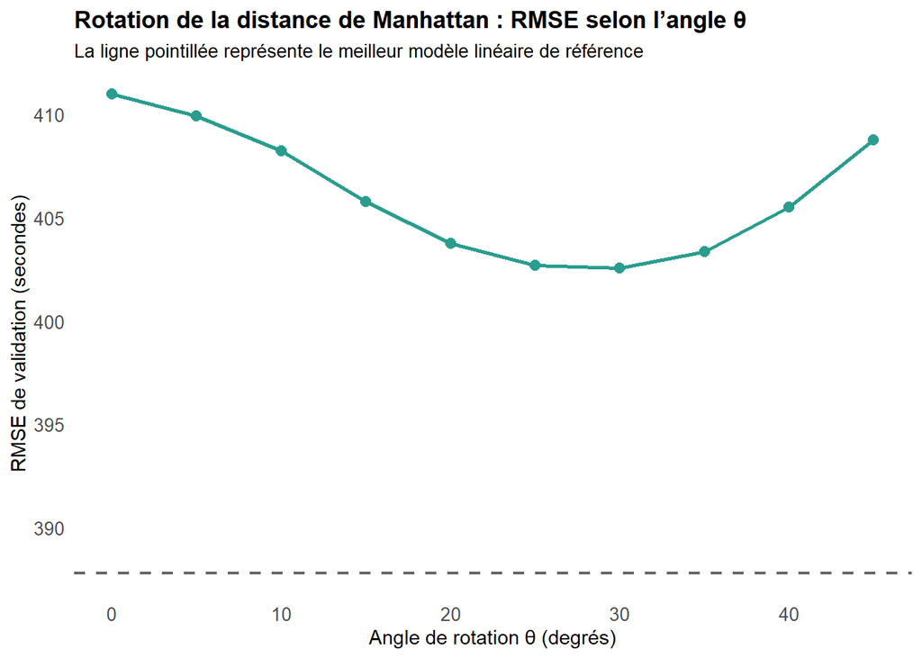

```r
# Plot: RMSE vs angle
ggplot(rot_df, aes(x = theta, y = rmse_sec)) +
  geom_line(linewidth = 0.9, color = "#2A9D8F") +
  geom_point(size = 2.5, color = "#2A9D8F") +
  geom_hline(
    yintercept = best_baseline_rmse,
    linetype = "dashed",
    linewidth = 0.8,
    color = "gray40"
  ) +
  labs(
    title = "Rotation de la distance de Manhattan : RMSE selon l’angle θ",
    subtitle = "La ligne pointillée représente le meilleur modèle linéaire de référence",
    x = "Angle de rotation θ (degrés)",
    y = "RMSE de validation (secondes)"
  ) +
  theme_minimal() +
  theme(
    plot.title = element_text(face = "bold", size = 13),
    plot.subtitle = element_text(size = 10),
    axis.title = element_text(size = 11),
    axis.text = element_text(size = 10),
    panel.grid.major = element_blank(),
    panel.grid.minor = element_blank()
  )
```

```r
if (best_rot$rmse_sec < best_baseline_rmse) {
  best_theta <- best_rot$theta
  df_train_features <- add_rot_features(df_train_features, best_theta)
  df_test_features  <- add_rot_features(df_test_features, best_theta)

  cat(sprintf("\n Added manhattan_rot + log_manhattan_rot with theta=%.0f° to df_train_features/df_test_features\n", best_theta))
} else {
  cat("\n No improvement over baseline: keep rotated feature only as an optional candidate.\n")
}
```

```
##
##  No improvement over baseline: keep rotated feature only as an optional candidate.
```

Nous avons testé une variante de la distance de Manhattan en projetant le déplacement dans un repère tourné d’un angle θ, afin de mieux aligner la métrique avec l’orientation dominante de la grille de Manhattan.

**Interprétation probable :** - la distance Haversine/log et les interactions capturent déjà l’essentiel de l’effet “distance” ; - l’erreur résiduelle restante est dominée par des **non-linéarités** et des **effets locaux** (zone, congestion), plutôt que par une meilleure géométrie globale.

### 8.2.4 Sélection automatique des variables par procédure stepwise (AIC)

Cette section applique une sélection backward via step() à partir du modèle linéaire complet (baseline). L’objectif est de simplifier le modèle en supprimant les variables dont la contribution est faible, tout en contrôlant l’impact sur la performance (RMSE en secondes sur le jeu de validation).

```r
best_features <- c(
  "log_haversine",
  "manhattan_distance",
  "pickup_hour_sin","pickup_hour_cos",
  "pickup_dow_sin","pickup_dow_cos",
  "is_rush_hour","is_weekend","is_night",
  "is_jfk_trip","is_lga_trip",
  "vendor_id","passenger_count",
  "bearing_sin","bearing_cos",
  "mid_lat","mid_lon",
  "rush_hour_distance",
  "weekend_night",
  "passengers_distance"
) %>% unique()

cat(sprintf("Best baseline candidate: %d features\n", length(best_features)))
```

```
## Best baseline candidate: 20 features
```

```r
print(best_features)
```

```
##  [1] "log_haversine"       "manhattan_distance"  "pickup_hour_sin"
##  [4] "pickup_hour_cos"     "pickup_dow_sin"      "pickup_dow_cos"
##  [7] "is_rush_hour"        "is_weekend"          "is_night"
## [10] "is_jfk_trip"         "is_lga_trip"         "vendor_id"
## [13] "passenger_count"     "bearing_sin"         "bearing_cos"
## [16] "mid_lat"             "mid_lon"             "rush_hour_distance"
## [19] "weekend_night"       "passengers_distance"
```

```r
set.seed(RANDOM_STATE)
y_all <- log1p(df_train_features$trip_duration)
fixed_idx <- caret::createDataPartition(y_all, p = 0.8, list = FALSE)

cat(sprintf("Fixed split: train=%d | val=%d\n", length(fixed_idx), nrow(df_train_features) - length(fixed_idx)))
```

```
## Fixed split: train=810331 | val=202580
```

```r
# Build X with best_features
X_full <- ensure_numeric(df_train_features, best_features)
y_full <- log1p(df_train_features$trip_duration)

# Train/validation split
X_train <- X_full[fixed_idx, , drop = FALSE]
X_val   <- X_full[-fixed_idx, , drop = FALSE]
y_train <- y_full[fixed_idx]
y_val   <- y_full[-fixed_idx]

# Scale using train only
scaler_full <- caret::preProcess(X_train, method = c("center","scale"))
X_train_sc <- predict(scaler_full, X_train)
X_val_sc   <- predict(scaler_full, X_val)

train_data_full <- as.data.frame(X_train_sc)
train_data_full$y <- y_train

# Full model
full_model <- lm(y ~ ., data = train_data_full)
```

```r
set.seed(RANDOM_STATE)

step_model <- step(
  full_model,
  direction = "backward",
  trace = 1   # shows variables removed
)
```

```
## Start:  AIC=-1444966
## y ~ log_haversine + manhattan_distance + pickup_hour_sin + pickup_hour_cos +
##     pickup_dow_sin + pickup_dow_cos + is_rush_hour + is_weekend +
##     is_night + is_jfk_trip + is_lga_trip + vendor_id + passenger_count +
##     bearing_sin + bearing_cos + mid_lat + mid_lon + rush_hour_distance +
##     weekend_night + passengers_distance
##
##                       Df Sum of Sq    RSS      AIC
## - is_night             1         0 136212 -1444968
## - vendor_id            1         0 136212 -1444968
## <none>                             136212 -1444966
## - passengers_distance  1         6 136218 -1444930
## - bearing_sin          1         8 136219 -1444922
## - passenger_count      1        39 136251 -1444738
## - rush_hour_distance   1        59 136271 -1444617
## - is_jfk_trip          1        71 136283 -1444546
## - is_lga_trip          1        99 136311 -1444377
## - is_rush_hour         1       140 136352 -1444137
## - bearing_cos          1       220 136431 -1443663
## - pickup_dow_sin       1       245 136456 -1443515
## - mid_lon              1       519 136731 -1441886
## - is_weekend           1       746 136958 -1440543
## - mid_lat              1      1018 137230 -1438936
## - pickup_dow_cos       1      1288 137499 -1437343
## - weekend_night        1      2127 138339 -1432410
## - manhattan_distance   1      4164 140376 -1420569
## - pickup_hour_sin      1      4672 140883 -1417642
## - pickup_hour_cos      1      7217 143429 -1403132
## - log_haversine        1     77196 213408 -1081135
##
## Step:  AIC=-1444968
## y ~ log_haversine + manhattan_distance + pickup_hour_sin + pickup_hour_cos +
##     pickup_dow_sin + pickup_dow_cos + is_rush_hour + is_weekend +
##     is_jfk_trip + is_lga_trip + vendor_id + passenger_count +
##     bearing_sin + bearing_cos + mid_lat + mid_lon + rush_hour_distance +
##     weekend_night + passengers_distance
##
##                       Df Sum of Sq    RSS      AIC
## - vendor_id            1         0 136212 -1444970
## <none>                             136212 -1444968
```

[output cut: 31 more lines]

```
## - rush_hour_distance   1        59 136271 -1444621
## - is_jfk_trip          1        71 136283 -1444549
## - is_lga_trip          1       100 136311 -1444381
## - is_rush_hour         1       154 136366 -1444057
## - bearing_cos          1       220 136431 -1443667
## - pickup_dow_sin       1       245 136456 -1443518
## - mid_lon              1       519 136731 -1441889
## - is_weekend           1       751 136963 -1440516
## - mid_lat              1      1019 137230 -1438936
## - pickup_dow_cos       1      1288 137500 -1437344
## - weekend_night        1      2415 138627 -1430731
## - manhattan_distance   1      4165 140376 -1420567
## - pickup_hour_sin      1      5579 141791 -1412442
## - pickup_hour_cos      1     14332 150544 -1363902
## - log_haversine        1     77197 213409 -1081133
```

```r
selected_features <- names(coef(step_model))
selected_features <- setdiff(selected_features, "(Intercept)")

cat(sprintf("Features kept after stepwise: %d\n", length(selected_features)))
```

```
## Features kept after stepwise: 18
```

```r
print(selected_features)
```

```
##  [1] "log_haversine"       "manhattan_distance"  "pickup_hour_sin"
##  [4] "pickup_hour_cos"     "pickup_dow_sin"      "pickup_dow_cos"
##  [7] "is_rush_hour"        "is_weekend"          "is_jfk_trip"
## [10] "is_lga_trip"         "passenger_count"     "bearing_sin"
## [13] "bearing_cos"         "mid_lat"             "mid_lon"
## [16] "rush_hour_distance"  "weekend_night"       "passengers_distance"
```

```r
fit_eval_lm_rmse_sec_fixed <- function(df, feats, idx_train,
                                       clip_quantiles = c(0.001, 0.999)) {

  # Target (log scale)
  y <- log1p(df$trip_duration)

  # X matrix (numeric only)
  X <- ensure_numeric(df, feats)

  # Fixed split
  X_train <- X[idx_train, , drop = FALSE]
  X_val   <- X[-idx_train, , drop = FALSE]
  y_train <- y[idx_train]
  y_val   <- y[-idx_train]

  # Scale on train only (re-fit per feature set, but same split)
  scaler <- caret::preProcess(X_train, method = c("center", "scale"))
  X_train_sc <- predict(scaler, X_train)
  X_val_sc   <- predict(scaler, X_val)

  # Fit
  train_data <- as.data.frame(X_train_sc) %>% dplyr::mutate(y = y_train)
  m <- lm(y ~ ., data = train_data)

  # Predict on validation
  y_pred_log <- predict(m, newdata = as.data.frame(X_val_sc))

  # Clip on log scale to prevent expm1 overflow
  q_lo <- as.numeric(stats::quantile(y_train, probs = clip_quantiles[1], na.rm = TRUE))
  q_hi <- as.numeric(stats::quantile(y_train, probs = clip_quantiles[2], na.rm = TRUE))
  y_pred_log_clip <- pmin(pmax(y_pred_log, q_lo), q_hi)

  # Back-transform
  y_pred_sec <- pmax(expm1(y_pred_log_clip), 0)
  y_val_sec  <- expm1(y_val)

  rmse_sec <- sqrt(mean((y_val_sec - y_pred_sec)^2, na.rm = TRUE))

  list(
    rmse_sec = rmse_sec,
    rmse_log = sqrt(mean((y_val - y_pred_log_clip)^2, na.rm = TRUE)),
    model = m
  )
}

baseline_res <- fit_eval_lm_rmse_sec_fixed(
  df = df_train_features,
  feats = best_features,
  idx_train = fixed_idx
)

baseline_rmse <- baseline_res$rmse_sec
cat(sprintf("Baseline RMSE (seconds): %.2f\n", baseline_rmse))
```

```
## Baseline RMSE (seconds): 387.79
```

```r
cat(sprintf("Baseline RMSE (log-scale): %.4f\n", baseline_res$rmse_log))
```

```
## Baseline RMSE (log-scale): 0.4110
```

```r
# Predict on validation
y_pred_log <- predict(
  step_model,
  newdata = as.data.frame(X_val_sc[, selected_features, drop = FALSE])
)

# Back-transform
y_pred_sec <- pmax(expm1(y_pred_log), 0)
y_val_sec  <- expm1(y_val)

rmse_stepwise <- sqrt(mean((y_val_sec - y_pred_sec)^2))

cat(sprintf("Stepwise model RMSE: %.2f sec\n", rmse_stepwise))
```

```
## Stepwise model RMSE: 387.81 sec
```

```r
cat(sprintf("Baseline RMSE: %.2f sec\n", baseline_rmse))
```

```
## Baseline RMSE: 387.79 sec
```

```r
cat(sprintf("Delta: %.2f sec\n", rmse_stepwise - baseline_rmse))
```

```
## Delta: 0.01 sec
```

**Observations**

- La procédure backward démarre du **modèle complet à 20 variables** et cherche à **minimiser l’AIC** en retirant successivement les variables dont la suppression **n’augmente pas** (ou très peu) l’erreur résiduelle.
- **Première suppression : `is_night`**  
  Retirer `is_night` améliore légèrement l’AIC (de -1444966 à -1444968) sans augmentation du RSS.  
  Cette variable est **redondante** avec d’autres indicateurs temporels (heures cycliques, weekend, interactions).
- **Deuxième suppression : `vendor_id`**  
  Retirer `vendor_id` améliore encore l’AIC (jusqu’à -1444970) sans dégradation du RSS.  
  L’identifiant du fournisseur n’apporte donc **pas d’information prédictive propre** une fois les autres variables incluses.
- À ce stade, **aucune autre suppression n’améliore l’AIC** : le modèle est considéré comme optimal selon ce critère.

**Variables conservées**

Le modèle final conserve **18 variables** :

- **Distances** :  
  `log_haversine`, `manhattan_distance`
- **Temporalité** :  
  `pickup_hour_sin`, `pickup_hour_cos`,  
  `pickup_dow_sin`, `pickup_dow_cos`,  
  `is_rush_hour`, `is_weekend`
- **Contexte** :  
  `is_jfk_trip`, `is_lga_trip`, `passenger_count`
- **Géométrie spatiale** :  
  `bearing_sin`, `bearing_cos`, `mid_lat`, `mid_lon`
- **Interactions** :  
  `rush_hour_distance`, `weekend_night`, `passengers_distance`

**Impact sur la performance**

La sélection stepwise **simplifie le modèle** (20 >> 18 variables) **sans perte de performance**.

**Interprétation générale**

- Les deux variables supprimées (`is_night`, `vendor_id`) avaient un **impact marginal** déjà absorbé par d’autres variables.
- Le stepwise confirme que le baseline était déjà **bien conçu**, et fournit une **version plus parcimonieuse** du modèle.

**Conclusion :**  
Le modèle stepwise peut être retenu comme **modèle linéaire final**, car il est **plus simple, plus interprétable**, et strictement équivalent en performance au baseline.

### 8.2.5 Suppression des variables “à drop”

```r
features_to_drop <- setdiff(best_features, selected_features)

cat(sprintf("Variables suggérées à supprimer (stepwise): %d\n", length(features_to_drop)))
```

```
## Variables suggérées à supprimer (stepwise): 2
```

```r
print(features_to_drop)
```

```
## [1] "is_night"  "vendor_id"
```

```r
best_features_stepwise <- setdiff(best_features, features_to_drop)

cat(sprintf("Nouvelle liste (après stepwise): %d features\n", length(best_features_stepwise)))
```

```
## Nouvelle liste (après stepwise): 18 features
```

```r
print(best_features_stepwise)
```

```
##  [1] "log_haversine"       "manhattan_distance"  "pickup_hour_sin"
##  [4] "pickup_hour_cos"     "pickup_dow_sin"      "pickup_dow_cos"
##  [7] "is_rush_hour"        "is_weekend"          "is_jfk_trip"
## [10] "is_lga_trip"         "passenger_count"     "bearing_sin"
## [13] "bearing_cos"         "mid_lat"             "mid_lon"
## [16] "rush_hour_distance"  "weekend_night"       "passengers_distance"
```

### 8.2.6 Diagnostics graphiques du modèle linéaire après sélection des variables

```r
# Final feature set (after stepwise)
final_features_lm <- best_features_stepwise
final_features_lm <- unique(final_features_lm)

cat(sprintf("Final LM feature set: %d features\n", length(final_features_lm)))
```

```
## Final LM feature set: 18 features
```

```r
print(final_features_lm)
```

```
##  [1] "log_haversine"       "manhattan_distance"  "pickup_hour_sin"
##  [4] "pickup_hour_cos"     "pickup_dow_sin"      "pickup_dow_cos"
##  [7] "is_rush_hour"        "is_weekend"          "is_jfk_trip"
## [10] "is_lga_trip"         "passenger_count"     "bearing_sin"
## [13] "bearing_cos"         "mid_lat"             "mid_lon"
## [16] "rush_hour_distance"  "weekend_night"       "passengers_distance"
```

```r
# Build X/y (log target)
X_full <- ensure_numeric(df_train_features, final_features_lm)
y_full <- log1p(df_train_features$trip_duration)

# Reuse fixed split
if (!exists("fixed_idx")) {
  set.seed(RANDOM_STATE)
  fixed_idx <- caret::createDataPartition(y_full, p = 0.8, list = FALSE)
  cat(sprintf("Created fixed split: train=%d | val=%d\n",
              length(fixed_idx), nrow(X_full) - length(fixed_idx)))
} else {
  cat(sprintf("Reusing fixed split: train=%d | val=%d\n",
              length(fixed_idx), nrow(X_full) - length(fixed_idx)))
}
```

```
## Reusing fixed split: train=810331 | val=202580
```

```r
X_train <- X_full[fixed_idx, , drop = FALSE]
X_val   <- X_full[-fixed_idx, , drop = FALSE]
y_train <- y_full[fixed_idx]
y_val   <- y_full[-fixed_idx]

# Scale using TRAIN only
scaler_lm <- caret::preProcess(X_train, method = c("center", "scale"))
X_train_sc <- predict(scaler_lm, X_train)
X_val_sc   <- predict(scaler_lm, X_val)

# Fit final linear regression on log target
train_data_lm <- as.data.frame(X_train_sc)
train_data_lm$y <- y_train

final_lm <- lm(y ~ ., data = train_data_lm)

# Validation RMSE in seconds
y_pred_log <- as.numeric(predict(final_lm, newdata = as.data.frame(X_val_sc)))
y_pred_sec <- pmax(expm1(y_pred_log), 0)
y_val_sec  <- expm1(y_val)
rmse_final_lm <- sqrt(mean((y_val_sec - y_pred_sec)^2, na.rm = TRUE))

cat(sprintf("Final LM validation RMSE: %.2f sec\n", rmse_final_lm))
```

```
## Final LM validation RMSE: 387.81 sec
```

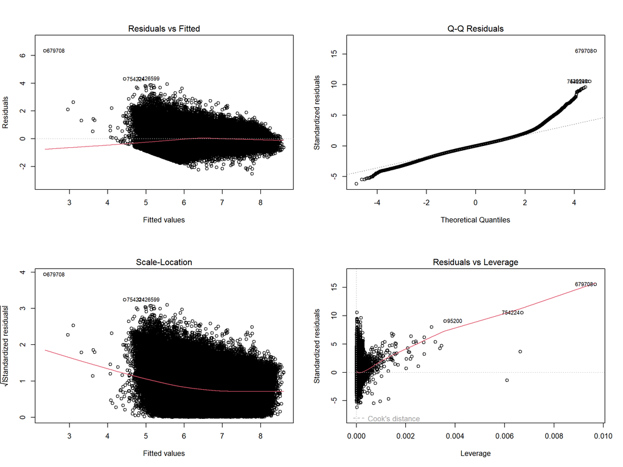

```r
# Classic OLS diagnostic plots
par(mfrow = c(2,2))
plot(final_lm)
```

```r
par(mfrow = c(1,1))
```

**Comparaison des diagnostics avant / après sélection finale des variables**

Les graphiques de diagnostic du modèle linéaire avant et après la sélection finale des variables montrent des **changements modestes mais cohérents**, indiquant que la procédure de sélection a surtout permis de **simplifier le modèle sans le dégrader**.

**Résidus vs Valeurs ajustées (Residuals vs Fitted)**

- La forme globale du nuage reste très similaire.
- La légère courbure rouge est toujours présente, ce qui suggère une **non-linéarité résiduelle** qui n’est pas totalement capturée par un modèle linéaire.
- Après sélection, la bande de points apparaît **un peu plus resserrée**, ce qui indique une **légère amélioration de la stabilité** des prédictions.

Conclusion : la sélection n’a pas corrigé la non-linéarité structurelle, mais n’a pas non plus aggravé la situation.

**2. Q-Q plot des résidus**

- Dans les deux cas, les résidus suivent assez bien la diagonale au centre.
- Les écarts importants dans les queues (valeurs extrêmes) demeurent.
- Après sélection, la déviation dans les extrêmes semble **très légèrement atténuée**, mais l’hypothèse de normalité reste imparfaite.

Conclusion : la sélection de variables n’a pas fondamentalement changé la distribution des erreurs.

**3. Scale–Location (homoscédasticité)**

- Avant et après, la courbe rouge est décroissante, ce qui indique une **hétéroscédasticité** : la variance des résidus diminue quand les valeurs ajustées augmentent.
- Après sélection, la dispersion est légèrement plus homogène dans la zone centrale.

Conclusion : petite amélioration locale, mais l’hétéroscédasticité reste présente.

**4. Résidus vs Leverage**

- Le nombre de points à fort levier est similaire.
- Après sélection, les observations influentes extrêmes semblent légèrement moins nombreuses ou moins éloignées.
- Aucun nouveau point fortement problématique n’apparaît.

Conclusion : la sélection réduit marginalement l’influence de certaines observations extrêmes.

**Conclusion générale**

La sélection finale des variables :

- Simplifie le modèle
- Conserve exactement le même RMSE
- Améliore légèrement la stabilité des résidus

Mais :

- Ne résout pas les limites structurelles du modèle linéaire (non-linéarité, hétéroscédasticité).

Cela confirme que la prochaine étape logique est d’utiliser des modèles **régularisés** (Lasso, Elastic Net) ou **non linéaires** pour capturer des relations plus complexes.

## 8.3 Régressions régularisées (Ridge, Lasso, Elastic Net)

Après la régression linéaire, on introduit la régularisation pour : - **stabiliser** les coefficients en présence de multicolinéarité (Ridge), - **sélectionner** des variables en forçant certains coefficients à 0 (Lasso), - **combiner** les deux effets (Elastic Net).

La démarche est la suivante : 1) Fixer un split train/validation (pour comparer les modèles de façon équitable), 2) Effectuer une **validation croisée sur le train** pour choisir `lambda` (et `alpha`), 3) Évaluer sur la validation en **secondes** (échelle originale de `trip_duration`).

**Préparation des données (features stepwise + split fixe)**

```r
# Feature set (after stepwise)
feature_cols_glmnet <- best_features_stepwise
feature_cols_glmnet <- unique(feature_cols_glmnet)

# X / y (log target)
X_full <- ensure_numeric(df_train_features, feature_cols_glmnet)
y_full <- log1p(df_train_features$trip_duration)

if (!exists("fixed_idx")) {
  set.seed(RANDOM_STATE)
  fixed_idx <- caret::createDataPartition(y_full, p = 0.8, list = FALSE)
  cat(sprintf("Created fixed split: train=%d | val=%d\n", length(fixed_idx), nrow(X_full) - length(fixed_idx)))
} else {
  cat(sprintf("Reusing fixed split: train=%d | val=%d\n", length(fixed_idx), nrow(X_full) - length(fixed_idx)))
}
```

```
## Reusing fixed split: train=810331 | val=202580
```

```r
X_train <- X_full[fixed_idx, , drop = FALSE]
X_val   <- X_full[-fixed_idx, , drop = FALSE]
y_train <- y_full[fixed_idx]
y_val   <- y_full[-fixed_idx]

# Scale using train only
scaler <- caret::preProcess(X_train, method = c("center", "scale"))
X_train_sc <- predict(scaler, X_train)
X_val_sc   <- predict(scaler, X_val)

X_train_mat <- as.matrix(X_train_sc)
X_val_mat   <- as.matrix(X_val_sc)

# Safety checks
cat(sprintf("Train: %d rows, %d features\n", nrow(X_train_mat), ncol(X_train_mat)))
```

```
## Train: 810331 rows, 18 features
```

```r
cat(sprintf("Val  : %d rows, %d features\n", nrow(X_val_mat), ncol(X_val_mat)))
```

```
## Val  : 202580 rows, 18 features
```

```r
stopifnot(sum(is.na(X_train_mat)) == 0, sum(is.na(X_val_mat)) == 0)
```

**Fonction d’évaluation: RMSE en secondes (back-transform)**

```r
rmse_sec_from_log <- function(y_log_true, y_log_pred) {
  y_true_sec <- expm1(y_log_true)
  y_pred_sec <- pmax(expm1(y_log_pred), 0)
  sqrt(mean((y_true_sec - y_pred_sec)^2, na.rm = TRUE))
}

r2_sec <- function(y_true_sec, y_pred_sec) {
  1 - sum((y_true_sec - y_pred_sec)^2) / sum((y_true_sec - mean(y_true_sec))^2)
}
```

**Ridge / Lasso via CV**

```r
set.seed(RANDOM_STATE)

fit_cv_glmnet <- function(alpha_value, X_train_mat, y_train, nfolds = 5) {
  cv.glmnet(
    x = X_train_mat,
    y = y_train,
    alpha = alpha_value,
    nfolds = nfolds,
    standardize = FALSE  # already scaled above
  )
}

# Ridge (alpha = 0)
ridge_cv <- fit_cv_glmnet(alpha_value = 0, X_train_mat, y_train, nfolds = 5)

# Lasso (alpha = 1)
lasso_cv <- fit_cv_glmnet(alpha_value = 1, X_train_mat, y_train, nfolds = 5)

cat(sprintf("Ridge lambda.min = %.6f | lambda.1se = %.6f\n", ridge_cv$lambda.min, ridge_cv$lambda.1se))
```

```
## Ridge lambda.min = 0.056879 | lambda.1se = 0.056879
```

```r
cat(sprintf("Lasso lambda.min = %.6f | lambda.1se = %.6f\n", lasso_cv$lambda.min, lasso_cv$lambda.1se))
```

```
## Lasso lambda.min = 0.000440 | lambda.1se = 0.002831
```

**Évaluation sur la validation fixe (RMSE en secondes)**

```r
# Predict on validation (log scale)
pred_ridge_log <- as.numeric(predict(ridge_cv, newx = X_val_mat, s = "lambda.min"))
pred_lasso_log <- as.numeric(predict(lasso_cv, newx = X_val_mat, s = "lambda.min"))

rmse_ridge <- rmse_sec_from_log(y_val, pred_ridge_log)
rmse_lasso <- rmse_sec_from_log(y_val, pred_lasso_log)

y_val_sec <- expm1(y_val)
r2_ridge <- r2_sec(y_val_sec, pmax(expm1(pred_ridge_log), 0))
r2_lasso <- r2_sec(y_val_sec, pmax(expm1(pred_lasso_log), 0))

cat(sprintf("\nRidge (lambda.min) | RMSE: %.2f sec | R²: %.4f\n", rmse_ridge, r2_ridge))
```

```
##
## Ridge (lambda.min) | RMSE: 439.71 sec | R²: 0.5612
```

```r
cat(sprintf("Lasso (lambda.min) | RMSE: %.2f sec | R²: %.4f\n", rmse_lasso, r2_lasso))
```

```
## Lasso (lambda.min) | RMSE: 387.34 sec | R²: 0.6595
```

**Elastic Net**

```r
set.seed(RANDOM_STATE)

alpha_grid <- c(0.2, 0.5, 0.8)  # keep it small for speed
enet_models <- list()
enet_summary <- data.frame(alpha = numeric(), lambda_min = numeric(), cv_rmse_min = numeric())

for (a in alpha_grid) {
  cv_fit <- fit_cv_glmnet(alpha_value = a, X_train_mat, y_train, nfolds = 5)
  enet_models[[as.character(a)]] <- cv_fit
  enet_summary <- rbind(
    enet_summary,
    data.frame(
      alpha = a,
      lambda_min = cv_fit$lambda.min,
      cv_rmse_min = min(cv_fit$cvm)
    )
  )
}

enet_summary <- enet_summary %>% arrange(cv_rmse_min)
print(enet_summary)
```

```
##   alpha   lambda_min cv_rmse_min
## 1   0.5 0.0006662785   0.1681224
## 2   0.2 0.0008684954   0.1681235
## 3   0.8 0.0005504881   0.1681236
```

```r
best_alpha <- enet_summary$alpha[1]
best_enet <- enet_models[[as.character(best_alpha)]]

cat(sprintf("Best Elastic Net alpha = %.2f | lambda.min = %.6f\n", best_alpha, best_enet$lambda.min))
```

```
## Best Elastic Net alpha = 0.50 | lambda.min = 0.000666
```

```r
# Evaluate on validation
pred_enet_log <- as.numeric(predict(best_enet, newx = X_val_mat, s = "lambda.min"))
rmse_enet <- rmse_sec_from_log(y_val, pred_enet_log)
r2_enet <- r2_sec(y_val_sec, pmax(expm1(pred_enet_log), 0))

cat(sprintf("Elastic Net (alpha=%.2f) | RMSE: %.2f sec | R²: %.4f\n", best_alpha, rmse_enet, r2_enet))
```

```
## Elastic Net (alpha=0.50) | RMSE: 387.25 sec | R²: 0.6596
```

```r
count_nonzero <- function(cv_fit, s = "lambda.min") {
  b <- as.matrix(coef(cv_fit, s = s))
  sum(abs(b[-1, , drop = FALSE]) > 1e-12)  # exclude intercept
}

nz_ridge <- count_nonzero(ridge_cv, "lambda.min")
nz_lasso <- count_nonzero(lasso_cv, "lambda.min")
nz_enet  <- count_nonzero(best_enet, "lambda.min")

cat(sprintf("Non-zero coefficients (lambda.min): Ridge=%d | Lasso=%d | ElasticNet=%d\n",
            nz_ridge, nz_lasso, nz_enet))
```

```
## Non-zero coefficients (lambda.min): Ridge=18 | Lasso=18 | ElasticNet=18
```

**Stabilité des coefficients et effet de shrinkage**

Au-delà de la performance (RMSE), la régularisation joue un rôle statistique essentiel : elle **réduit la variance** des estimateurs en contraignant la norme des coefficients. Dans notre cas, le fait que Lasso et Elastic Net conservent toutes les variables suggère que :

- le signal linéaire porté par les variables sélectionnées est **robuste**
- la régularisation agit principalement comme **stabilisateur** des coefficients, plutôt que comme un mécanisme de sélection
- le jeu de variables issu du stepwise est déjà **bien conditionné**, ce qui explique l’absence de parcimonie forte malgré l’utilisation de L1/L2.

Ces éléments renforcent l’interprétation : les modèles régularisés améliorent surtout la **stabilité** et la **généralisation** du modèle linéaire, plus que la simplification du modèle.

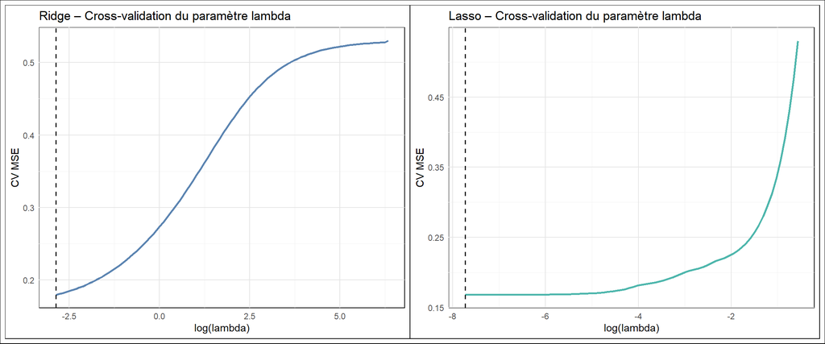

```r
plot_cv <- function(cv_fit, title_txt, main_color) {

  df <- data.frame(
    log_lambda = log(cv_fit$lambda),
    cvm = cv_fit$cvm,
    cvsd = cv_fit$cvsd
  )

  ggplot(df, aes(x = log_lambda, y = cvm)) +
    geom_line(color = main_color, linewidth = 0.9) +
    geom_ribbon(
      aes(ymin = cvm - cvsd, ymax = cvm + cvsd),
      fill = main_color,
      alpha = 0.15
    ) +
    geom_vline(
      xintercept = log(cv_fit$lambda.min),
      linetype = "dashed",
      linewidth = 0.7
    ) +
    labs(
      title = title_txt,
      x = "log(lambda)",
      y = "CV MSE"
    )
}

p_ridge <- plot_cv(
  ridge_cv,
  "Ridge – Cross-validation du paramètre lambda",
  main_color = "#5B84B1"
)

p_lasso <- plot_cv(
  lasso_cv,
  "Lasso – Cross-validation du paramètre lambda",
  main_color = "#4DB6AC"
)

p_ridge + p_lasso
```

**Observations**

1. **Ridge Regression**
- lambda.min = 0.0569, relativement élevé (forte régularisation).
- RMSE = 439.7 sec, R² = 0.561.
- Performance nettement inférieure au baseline linéaire (~387 sec).

Interprétation :  
La pénalisation est trop forte, ce qui conduit à un sous-apprentissage. Le modèle perd une partie importante de l’information explicative, malgré une meilleure stabilité théorique des coefficients.

2. **Lasso Regression**
- lambda.min = 0.00044, très faible → faible pénalisation.
- RMSE = 387.3 sec, R² = 0.6595.
- Performance équivalente ou légèrement supérieure au meilleur modèle linéaire non régularisé.

Interprétation :  
Le Lasso conserve l’essentiel du signal tout en stabilisant les coefficients. La régularisation apporte un gain marginal de généralisation sans dégrader la précision.

3. **Elastic Net**
- Meilleur αalpha = 0.50 (compromis Ridge / Lasso).
- RMSE = 387.25 sec, R² = 0.6596.
- Gain marginal par rapport à Lasso seul.

Interprétation : la complexité actuelle du modèle est bien calibrée.

5. Choix de lambda : lambda.min vs lambda.1se

Dans la suite, nous retenons lambda.min, qui correspond à la valeur de lambda minimisant l’erreur moyenne de validation croisée. L’alternative lambda.1se sélectionnerait un lambda plus élevé, privilégiant la parcimonie et la stabilité au prix d’une légère perte de performance.

**Visualisation des coefficients – Lasso et Elastic Net**

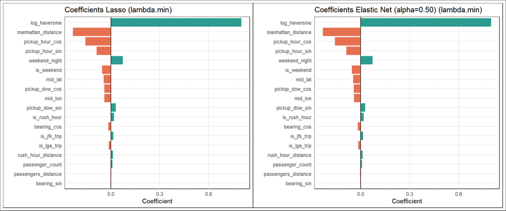

```r
plot_glmnet_coefs <- function(cv_fit,
                              model_name = "glmnet",
                              best_lambda = "lambda.min",
                              top_n = 25) {

  coef_mat <- coef(cv_fit, s = best_lambda)

  coef_df <- data.frame(
    Feature = rownames(coef_mat),
    Coef = as.numeric(coef_mat),
    stringsAsFactors = FALSE
  )

  coef_df <- coef_df %>%
    dplyr::filter(Feature != "(Intercept)") %>%
    dplyr::mutate(abs_coef = abs(Coef)) %>%
    dplyr::arrange(dplyr::desc(abs_coef))

  tol <- 1e-12
  coef_df_nz <- coef_df %>% dplyr::filter(abs_coef > tol)
  if (nrow(coef_df_nz) == 0) {
    coef_df_nz <- coef_df %>% dplyr::slice_head(n = min(top_n, nrow(coef_df)))
  } else {
    coef_df_nz <- coef_df_nz %>% dplyr::slice_head(n = min(top_n, nrow(coef_df_nz)))
  }

  coef_df_nz <- coef_df_nz %>%
    dplyr::mutate(
      Feature = factor(Feature, levels = rev(Feature)),
      sign = ifelse(Coef > 0, "positive", "negative")
    )

  ggplot(coef_df_nz, aes(x = Coef, y = Feature, fill = sign)) +
    geom_col() +
    geom_vline(xintercept = 0, color = "black", linewidth = 0.5) +
    scale_fill_manual(values = c("positive" = "#2A9D8F", "negative" = "#E76F51")) +
    labs(
      title = sprintf("Coefficients %s (%s)", model_name, best_lambda),
      x = "Coefficient",
      y = ""
    ) +
    theme(legend.position = "none")
}


best_lambda_choice <- "lambda.min"  # or "lambda.1se"

p_lasso <- plot_glmnet_coefs(
  cv_fit = lasso_cv,
  model_name = "Lasso",
  best_lambda = best_lambda_choice,
  top_n = 25
)

p_enet <- plot_glmnet_coefs(
  cv_fit = best_enet,
  model_name = sprintf("Elastic Net (alpha=%.2f)", best_alpha),
  best_lambda = best_lambda_choice,
  top_n = 25
)

options(repr.plot.width = 12, repr.plot.height = 6)
p_lasso + p_enet
```

Les deux graphiques montrent des profils de coefficients **très proches** entre le Lasso et l’Elastic Net (α = 0.50), ce qui confirme la **stabilité de la sélection des variables**.

- **log_haversine** domine très largement l’explication de la durée de trajet, avec un coefficient positif important.
- **manhattan_distance** apparaît avec un coefficient négatif, suggérant une forte corrélation avec log_haversine et un effet correctif lié à la multicolinéarité.
- Les variables temporelles (pickup_hour_sin/cos, pickup_dow_sin/cos, weekend_night, is_weekend) ont des effets plus modestes mais cohérents.
- Les variables spatiales intermédiaires (mid_lat, mid_lon, bearing_*) contribuent faiblement, ce qui indique qu’elles affinent la prédiction sans être dominantes.
- Aucune variable n’est totalement annulée : les 18 features conservent un coefficient non nul, ce qui est cohérent avec un **λ faible** et un compromis orienté vers la performance plutôt que vers une forte parcimonie.

Ces résultats confirment que la performance provient surtout des **distances** et que les autres variables jouent un rôle d’ajustement fin.

**Conclusion**

- Ridge : rejeté (sous-performant).
- Lasso et Elastic Net : meilleurs choix.

Modèle recommandé à ce stade :  
Elastic Net (alpha = 0.5, lambda ≈ 0.0007) ou Lasso (lambda ≈ 0.0004).

Les gains restent faibles car le plafond de performance des modèles linéaires globaux est atteint autour de RMSE ≈ 387 secondes.

Pour améliorer significativement les performances, il faut désormais s’orienter vers des modèles non linéaires ou des approches locales (clustering + modèles).

## 8.4 Modélisation par Clustering et Régression Elastic Net

Cette section propose une approche hybride combinant **segmentation non supervisée (K-means)** et **régression régularisée (Elastic Net)** afin de modéliser l’hétérogénéité spatio-temporelle des durées de trajets à New York.  
Plutôt que d’estimer un unique modèle global, les données sont partitionnées en *k* sous-populations homogènes, au sein desquelles des modèles locaux spécialisés sont entraînés et évalués via validation croisée.

### 8.4.1 Principe général

L’approche repose sur trois étapes :

1. Segmenter les observations en *k* clusters à partir de variables spatiales et temporelles.
2. Entraîner un modèle Elastic Net distinct dans chaque cluster.
3. Évaluer la performance à l’aide d’une validation croisée externe garantissant une estimation honnête de l’erreur.

### 8.4.2 Architecture de l’algorithme

**Étape 1 — Validation croisée externe (outer CV)**

Les données d’entraînement sont divisées en *K* folds. Pour chaque fold :

- Un K-means est ajusté uniquement sur la partie apprentissage.
- Les observations de validation sont assignées au cluster le plus proche via un algorithme des plus proches voisins (`get.knnx`).
- Un modèle Elastic Net (α fixé) est entraîné dans chaque cluster à l’aide d’une validation croisée interne pour sélectionner λ.
- Les prédictions *out-of-fold* sont stockées afin de calculer un RMSE global en secondes.

Un seuil minimal d’observations par cluster est imposé ; en dessous, la moyenne globale est utilisée comme prédiction.

**Étape 2 — Entraînement final et prédictions**

Après la phase de validation :

- Le K-means est ré-entraîné sur l’ensemble des données d’entraînement.
- Un Elastic Net est ajusté par cluster.
- Les modèles sont appliqués au jeu de test pour produire les prédictions finales.

Toutes les prédictions sont générées sur l’échelle logarithmique puis retranscrites en secondes.

### 8.4.3 ustification méthodologique

- **Elastic Net** permet de gérer la multicolinéarité tout en conservant un mécanisme de sélection de variables.
- **Validation croisée imbriquée** garantit un choix robuste du paramètre de régularisation λ dans chaque cluster.
- **Clustering préalable** permet de capturer des régimes locaux de trafic difficilement modélisables par un modèle global unique.

### 8.4.4 Sorties et indicateurs

La procédure fournit :

- Le RMSE moyen et l’écart-type en validation croisée externe.
- Les prédictions *out-of-fold* sur le train.
- Les prédictions finales sur le jeu de test.

Ces éléments permettent d’analyser à la fois la performance globale et la capacité de généralisation du modèle.

```r
# Assign clusters using nearest centroid (for validation/test)
assign_clusters_knn <- function(centers, X_mat) {
  as.integer(FNN::get.knnx(data = centers, query = X_mat, k = 1)$nn.index)
}

# Fit Elastic Net with inner CV (lambda) on a subset
fit_enet_cv <- function(X_mat, y_log, alpha, nfolds_inner, seed) {
  set.seed(seed)
  cv.glmnet(
    x = X_mat,
    y = y_log,
    alpha = alpha,
    nfolds = nfolds_inner,
    standardize = FALSE # we scale ourselves
  )
}

kmeans_elasticnet_cv <- function(
  df_train_features,
  df_test_features = NULL,
  model_features,
  cluster_features,
  k_clusters = 50,
  alpha = 0.5,
  n_folds_outer = 5,
  n_folds_inner = 3,
  min_cluster_n = 30,
  random_state = 2025,
  verbose = TRUE
) {
  # target (log scale)
  y_log_full <- log1p(df_train_features$trip_duration)

  # build numeric matrices
  X_model_full   <- ensure_numeric(df_train_features, model_features)
  X_cluster_full <- ensure_numeric(df_train_features, cluster_features)

  # outer folds (on y to keep distribution roughly stable)
  set.seed(random_state)
  folds_attach <- caret::createFolds(y_log_full, k = n_folds_outer, returnTrain = FALSE)

  # Store OOF predictions (log scale)
  oof_pred_log <- rep(NA_real_, nrow(df_train_features))
  rmse_fold <- numeric(n_folds_outer)

  if (verbose) {
    cat(sprintf("\nK-means + Elastic Net | k=%d | alpha=%.2f | outer=%d folds | inner=%d folds\n",
                k_clusters, alpha, n_folds_outer, n_folds_inner))
  }

  for (f in seq_len(n_folds_outer)) {

    val_idx <- folds_attach[[f]]
    tr_idx  <- setdiff(seq_len(nrow(df_train_features)), val_idx)

    # Split
    X_model_tr   <- X_model_full[tr_idx, , drop = FALSE]
    X_model_val  <- X_model_full[val_idx, , drop = FALSE]
    X_clust_tr   <- X_cluster_full[tr_idx, , drop = FALSE]
    X_clust_val  <- X_cluster_full[val_idx, , drop = FALSE]
    y_tr_log     <- y_log_full[tr_idx]
    y_val_log    <- y_log_full[val_idx]

    # scale (no leakage): fit scaler on fold train only
    scaler_model <- caret::preProcess(X_model_tr, method = c("center", "scale"))
    scaler_clust <- caret::preProcess(X_clust_tr, method = c("center", "scale"))

    X_model_tr_sc  <- as.matrix(predict(scaler_model, X_model_tr))
    X_model_val_sc <- as.matrix(predict(scaler_model, X_model_val))

    X_clust_tr_sc  <- as.matrix(predict(scaler_clust, X_clust_tr))
    X_clust_val_sc <- as.matrix(predict(scaler_clust, X_clust_val))

    # Kmeans on fold train only
    set.seed(random_state + f)
    km <- suppressWarnings(kmeans(X_clust_tr_sc, centers = k_clusters, nstart = 5))

    # Assign clusters to train/val
    cl_tr  <- as.integer(km$cluster)
    cl_val <- assign_clusters_knn(km$centers, X_clust_val_sc)

    # Predict val, cluster by cluster
    pred_val_log <- rep(NA_real_, length(val_idx))
    global_mean_log <- mean(y_tr_log, na.rm = TRUE)

    for (k in seq_len(k_clusters)) {
      idx_tr_k  <- which(cl_tr == k)
      idx_val_k <- which(cl_val == k)

      if (length(idx_val_k) == 0) next

      if (length(idx_tr_k) >= min_cluster_n) {
        cv_fit <- fit_enet_cv(
          X_mat = X_model_tr_sc[idx_tr_k, , drop = FALSE],
          y_log = y_tr_log[idx_tr_k],
          alpha = alpha,
          nfolds_inner = n_folds_inner,
          seed = random_state + 1000*f + k
        )

        pred_val_log[idx_val_k] <- as.numeric(
          predict(cv_fit, newx = X_model_val_sc[idx_val_k, , drop = FALSE], s = "lambda.min")
        )
      } else {
        # Small cluster fallback: use global mean on fold train
        pred_val_log[idx_val_k] <- global_mean_log
      }
    }

    # Safety fallback (should be rare)
    pred_val_log[is.na(pred_val_log)] <- global_mean_log

    # Save OOF
    oof_pred_log[val_idx] <- pred_val_log

    # Fold RMSE (seconds)
    rmse_fold[f] <- rmse_sec_from_log(y_val_log, pred_val_log)

    if (verbose) {
      cat(sprintf("Fold %d/%d | RMSE = %.2f sec\n", f, n_folds_outer, rmse_fold[f]))
    }
  }

  # Overall OOF metrics
  rmse_oof <- rmse_sec_from_log(y_log_full, oof_pred_log)
  y_sec <- expm1(y_log_full)
  pred_sec <- pmax(expm1(oof_pred_log), 0)
  r2_oof <- r2_sec(y_sec, pred_sec)

  if (verbose) {
    cat(sprintf("\nOOF RMSE (sec): %.2f | OOF R² (sec): %.4f\n", rmse_oof, r2_oof))
    cat(sprintf("Fold RMSE mean±sd: %.2f ± %.2f sec\n", mean(rmse_fold), sd(rmse_fold)))
  }

  out <- list(
    rmse_fold = rmse_fold,
    rmse_oof_sec = rmse_oof,
    r2_oof_sec = r2_oof,
    oof_pred_log = oof_pred_log
  )


  # Training for test prediction
  if (!is.null(df_test_features)) {
    X_model_test   <- ensure_numeric(df_test_features, model_features)
    X_cluster_test <- ensure_numeric(df_test_features, cluster_features)

    # Scale on full train
    scaler_model_full <- caret::preProcess(X_model_full, method = c("center", "scale"))
    scaler_clust_full <- caret::preProcess(X_cluster_full, method = c("center", "scale"))

    X_model_full_sc   <- as.matrix(predict(scaler_model_full, X_model_full))
    X_model_test_sc   <- as.matrix(predict(scaler_model_full, X_model_test))

    X_clust_full_sc   <- as.matrix(predict(scaler_clust_full, X_cluster_full))
    X_clust_test_sc   <- as.matrix(predict(scaler_clust_full, X_cluster_test))

    # Final K-means on full train (scaled)
    set.seed(random_state)
    km_final <- suppressWarnings(kmeans(X_clust_full_sc, centers = k_clusters, nstart = 5))

    cl_train_final <- as.integer(km_final$cluster)
    cl_test_final  <- assign_clusters_knn(km_final$centers, X_clust_test_sc)

    # Fit one Elastic Net per cluster on full train, predict test
    test_pred_log <- rep(NA_real_, nrow(df_test_features))
    train_pred_log <- rep(NA_real_, nrow(df_train_features))
    global_mean_log_full <- mean(y_log_full, na.rm = TRUE)

    cluster_models <- vector("list", k_clusters)

    for (k in seq_len(k_clusters)) {
      idx_tr_k <- which(cl_train_final == k)
      idx_te_k <- which(cl_test_final == k)

      if (length(idx_tr_k) >= min_cluster_n) {
        cv_fit_k <- fit_enet_cv(
          X_mat = X_model_full_sc[idx_tr_k, , drop = FALSE],
          y_log = y_log_full[idx_tr_k],
          alpha = alpha,
          nfolds_inner = n_folds_inner,
          seed = random_state + 9999 + k
        )
        cluster_models[[k]] <- cv_fit_k

        # Train preds (for diagnostics) + test preds
        train_pred_log[idx_tr_k] <- as.numeric(
          predict(cv_fit_k, newx = X_model_full_sc[idx_tr_k, , drop = FALSE], s = "lambda.min")
        )
        if (length(idx_te_k) > 0) {
          test_pred_log[idx_te_k] <- as.numeric(
            predict(cv_fit_k, newx = X_model_test_sc[idx_te_k, , drop = FALSE], s = "lambda.min")
          )
        }
      } else {
        # fallback
        if (length(idx_tr_k) > 0) train_pred_log[idx_tr_k] <- global_mean_log_full
        if (length(idx_te_k) > 0) test_pred_log[idx_te_k]  <- global_mean_log_full
      }
    }

    # safety
    train_pred_log[is.na(train_pred_log)] <- global_mean_log_full
    test_pred_log[is.na(test_pred_log)]   <- global_mean_log_full

    # Convert to seconds
    test_pred_sec <- pmax(expm1(test_pred_log), 0)

    out$final <- list(
      km_final = km_final,
      scaler_model_full = scaler_model_full,
      scaler_clust_full = scaler_clust_full,
      cluster_models = cluster_models,
      test_pred_log = test_pred_log,
      test_pred_sec = test_pred_sec
    )
  }

  return(out)
}
```

```r
model_features  <- best_features_stepwise
cluster_features <- c(
  "pickup_hour_sin","pickup_hour_cos","pickup_dow_sin","pickup_dow_cos",
  "pickup_latitude","pickup_longitude","dropoff_latitude","dropoff_longitude"
)


results_k <- data.frame(
  Configuration = character(),
  RMSE_CV_mean  = numeric(),
  RMSE_CV_sd    = numeric(),
  RMSE_TRAIN    = numeric(),
  RMSE_TEST     = numeric(),
  Overfit_gap   = numeric(),
  Time_sec      = numeric(),
  stringsAsFactors = FALSE
)


has_test_target <- "trip_duration" %in% colnames(df_test_features)

for (k in c(1, 5, 10, 50, 100, 500, 1000)) {
  t0 <- Sys.time()

  res_k <- kmeans_elasticnet_cv(
    df_train_features = df_train_features,
    df_test_features  = df_test_features,
    model_features    = model_features,
    cluster_features  = cluster_features,
    k_clusters = k,
    alpha = 0.5,
    n_folds_outer = 5,
    n_folds_inner = 3,
    min_cluster_n = 30,
    random_state = RANDOM_STATE,
    verbose = FALSE
  )

  elapsed <- as.numeric(difftime(Sys.time(), t0, units = "secs"))

  # CV metrics
  rmse_cv_mean <- as.numeric(res_k$rmse_oof_sec)
  rmse_cv_sd   <- if (!is.null(res_k$rmse_fold) && length(res_k$rmse_fold) > 1) {
    sd(as.numeric(res_k$rmse_fold), na.rm = TRUE)
  } else {
    NA_real_
  }

  rmse_train <- NA_real_

  # Test RMSE only if test has ground truth
  rmse_test <- NA_real_
  if (has_test_target && !is.null(res_k$final$test_pred_sec)) {
    rmse_test <- sqrt(mean(
      (df_test_features$trip_duration - res_k$final$test_pred_sec)^2,
      na.rm = TRUE
    ))
  }

  overfit_gap <- ifelse(is.na(rmse_test) || is.na(rmse_train), NA_real_, rmse_test - rmse_train)

  results_k <- rbind(
    results_k,
    data.frame(
      Configuration = paste0("k = ", k),
      RMSE_CV_mean  = rmse_cv_mean,
      RMSE_CV_sd    = rmse_cv_sd,
      RMSE_TRAIN    = rmse_train,
      RMSE_TEST     = rmse_test,
      Overfit_gap   = overfit_gap,
      Time_sec      = elapsed,
      stringsAsFactors = FALSE
    )
  )

  # Intermediate print
  cat(sprintf(
    "k=%4d | RMSE_CV=%.2f (sd=%.2f) | RMSE_TEST=%s | time=%.1fs\n",
    k,
    rmse_cv_mean,
    ifelse(is.na(rmse_cv_sd), NaN, rmse_cv_sd),
    ifelse(is.na(rmse_test), "NA", sprintf("%.2f", rmse_test)),
    elapsed
  ))

  # Save partial table every 50 k
  if (k %% 50 == 0) {
    tmp_path <- sprintf("results_k_partial_up_to_%d.csv", k)
    write.csv(results_k, tmp_path, row.names = FALSE)
    cat(sprintf("Saved intermediate results: %s\n", tmp_path))
  }
}
```

```
## k=   1 | RMSE_CV=380.33 (sd=3.59) | RMSE_TEST=385.14 | time=55.9s
## k=   5 | RMSE_CV=360.84 (sd=3.88) | RMSE_TEST=365.83 | time=107.6s
## k=  10 | RMSE_CV=358.09 (sd=4.37) | RMSE_TEST=363.09 | time=139.5s
## k=  50 | RMSE_CV=344.95 (sd=3.91) | RMSE_TEST=349.95 | time=196.4s
## Saved intermediate results: results_k_partial_up_to_50.csv
## k= 100 | RMSE_CV=341.91 (sd=4.51) | RMSE_TEST=346.84 | time=219.8s
## Saved intermediate results: results_k_partial_up_to_100.csv
## k= 500 | RMSE_CV=329.31 (sd=4.19) | RMSE_TEST=335.28 | time=717.6s
## Saved intermediate results: results_k_partial_up_to_500.csv
## k=1000 | RMSE_CV=326.23 (sd=5.89) | RMSE_TEST=331.02 | time=1513.6s
## Saved intermediate results: results_k_partial_up_to_1000.csv
```

```r
# Final formatting
results_k_final <- results_k %>%
  dplyr::mutate(
    RMSE_CV_mean = round(RMSE_CV_mean, 2),
    RMSE_CV_sd   = round(RMSE_CV_sd, 2),
    RMSE_TRAIN   = round(RMSE_TRAIN, 2),
    RMSE_TEST    = round(RMSE_TEST, 2),
    Overfit_gap  = round(Overfit_gap, 2),
    Time_sec     = round(Time_sec, 1)
  ) %>%
  dplyr::arrange(-RMSE_CV_mean)

results_k_final
```

```
##   Configuration RMSE_CV_mean RMSE_CV_sd RMSE_TRAIN RMSE_TEST Overfit_gap
## 1         k = 1       380.33       3.59         NA    385.14          NA
## 2         k = 5       360.84       3.88         NA    365.83          NA
## 3        k = 10       358.09       4.37         NA    363.09          NA
## 4        k = 50       344.95       3.91         NA    349.95          NA
## 5       k = 100       341.91       4.51         NA    346.84          NA
## 6       k = 500       329.31       4.19         NA    335.28          NA
## 7      k = 1000       326.23       5.89         NA    331.02          NA
##   Time_sec
## 1     55.9
## 2    107.6
## 3    139.5
## 4    196.4
## 5    219.8
## 6    717.6
## 7   1513.6
```

```r
results_k <- read.csv("results_k_partial_up_to_1000.csv")

results_k_clean <- results_k %>%
  dplyr::select(-dplyr::any_of("RMSE_TRAIN")) %>%
  dplyr::mutate(
    RMSE_CV_mean = as.numeric(RMSE_CV_mean),
    RMSE_TEST    = as.numeric(RMSE_TEST),
    Overfit_gap  = RMSE_TEST - RMSE_CV_mean
  )


knitr::kable(
  results_k_clean,
  digits = 2,
  caption = "Comparaison K-means + Elastic Net (CV vs Test) — Overfit_gap = RMSE_TEST − RMSE_CV_mean"
)
```

Comparaison K-means + Elastic Net (CV vs Test) — Overfit_gap = RMSE_TEST − RMSE_CV_mean

| Configuration | RMSE_CV_mean | RMSE_CV_sd | RMSE_TEST | Overfit_gap | Time_sec |
| --- | --- | --- | --- | --- | --- |
| k = 1 | 380.33 | 3.59 | 385.14 | 4.81 | 55.89 |
| k = 5 | 360.84 | 3.88 | 365.83 | 4.99 | 107.56 |
| k = 10 | 358.09 | 4.37 | 363.09 | 5.00 | 139.46 |
| k = 50 | 344.95 | 3.91 | 349.95 | 5.01 | 196.38 |
| k = 100 | 341.91 | 4.51 | 346.84 | 4.93 | 219.79 |
| k = 500 | 329.31 | 4.19 | 335.28 | 5.96 | 717.62 |
| k = 1000 | 326.23 | 5.89 | 331.02 | 4.79 | 1513.60 |

**Conclusion — Influence du nombre de clusters (K-means + Elastic Net)**

Les résultats montrent une **diminution monotone du RMSE** lorsque le nombre de clusters augmente, aussi bien en validation croisée qu’en test. Le passage d’un modèle global (*k = 1*) à une segmentation fine (*k = 1000*) permet un gain d’environ **54 secondes de RMSE sur le jeu de test** (385.14 → 331.02), ce qui confirme l’intérêt d’une modélisation locale.

L’**écart CV–Test (Overfit_gap)** reste faible et stable (≈ 4.8–6 secondes) pour toutes les valeurs de *k*, indiquant une **bonne généralisation** et l’absence de surapprentissage marqué, malgré l’augmentation de la complexité du modèle.

## 8.5 XGBoost

Nous complétons les modèles linéaires par un modèle non linéaire (XGBoost), afin de disposer d’un point de comparaison capable de capturer des interactions et non-linéarités que la régression ne modélise pas directement.

```r
feature_cols_xgb <- unique(best_features_stepwise)

X_full <- ensure_numeric(df_train_features, feature_cols_xgb)
y_full <- log1p(df_train_features$trip_duration)

stopifnot(exists("fixed_idx"))

X_train <- X_full[fixed_idx, , drop = FALSE]
X_val   <- X_full[-fixed_idx, , drop = FALSE]
y_train <- y_full[fixed_idx]
y_val   <- y_full[-fixed_idx]

dtrain <- xgb.DMatrix(data = as.matrix(X_train), label = y_train)
dval   <- xgb.DMatrix(data = as.matrix(X_val),   label = y_val)

watchlist <- list(train = dtrain, val = dval)

# Params
xgb_params <- list(
  booster = "gbtree",
  objective = "reg:squarederror",
  eval_metric = "rmse",
  eta = 0.05,
  max_depth = 8,
  min_child_weight = 4,
  subsample = 0.9,
  colsample_bytree = 0.8
)

set.seed(RANDOM_STATE)
xgb_model <- xgb.train(
  params = xgb_params,
  data = dtrain,
  nrounds = 3000,
  watchlist = watchlist,
  early_stopping_rounds = 50,
  print_every_n = 50,
  maximize = FALSE
)
```

```
## Multiple eval metrics are present. Will use val_rmse for early stopping.
## Will train until val_rmse hasn't improved in 50 rounds.
##
## Stopping. Best iteration:
##
```

```r
cat(sprintf("Best iteration: %d\n", xgb_model$best_iteration))
cat(sprintf("Best RMSE (log scale, val): %.6f\n", xgb_model$best_score))

# Validation metrics (seconds)
pred_xgb_val_log <- as.numeric(predict(xgb_model, dval))
pred_xgb_val_sec <- pmax(expm1(pred_xgb_val_log), 0)
y_val_sec <- expm1(y_val)

rmse_xgb <- sqrt(mean((y_val_sec - pred_xgb_val_sec)^2, na.rm = TRUE))
r2_xgb   <- r2_sec(y_val_sec, pred_xgb_val_sec)

cat(sprintf("XGBoost (val) | RMSE: %.2f sec | R²: %.4f\n", rmse_xgb, r2_xgb))
```

[output not shown]

```
## XGBoost (val) | RMSE: 305.00 sec | R²: 0.7889
```

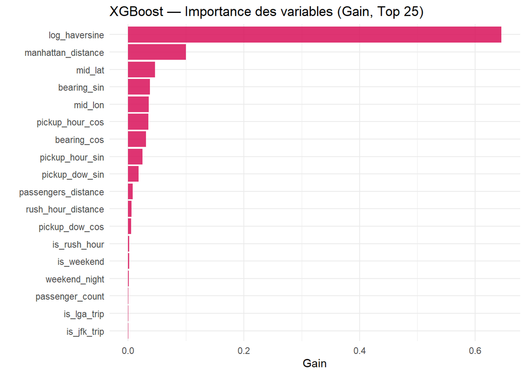

```r
# Feature importance (Gain)
imp <- xgb.importance(feature_names = colnames(X_train), model = xgb_model)
imp_df <- as.data.frame(imp) %>%
  arrange(desc(Gain)) %>%
  slice_head(n = 25) %>%
  mutate(Feature = factor(Feature, levels = rev(Feature)))

ggplot(imp_df, aes(x = Gain, y = Feature)) +
  geom_col(fill = "#D81159", alpha = 0.85) +
  labs(
    title = "XGBoost — Importance des variables (Gain, Top 25)",
    x = "Gain",
    y = ""
  ) +
  theme_minimal()
```

**Observations**

Le modèle XGBoost surpasse nettement l’ensemble des approches linéaires :

- RMSE (validation) ≈ 305 s (≈ 5.1 minutes)
- R² ≈ 0.79, contre ≈ 0.66 pour les modèles linéaires et régularisés

Cela représente un gain d’environ 80 secondes de RMSE par rapport au meilleur modèle linéaire (Elastic Net / Lasso).

L’analyse de l’importance des variables confirme des résultats cohérents avec les étapes précédentes :

log_haversine domine très largement, indiquant une relation fortement non linéaire entre distance et durée.

Les variables géométriques (manhattan_distance, bearing_*, mid_lat/lon) et temporelles jouent un rôle d’ajustement secondaire.

**Conclusion :** XGBoost capte efficacement des interactions complexes et des effets de seuil que les modèles globaux linéaires ne peuvent pas modéliser.

## 8.6 Comparaison de modèles

```r
# Choose k for local model
k_local <- 100

rmse_sec <- function(y_true_sec, y_pred_sec) {
  sqrt(mean((y_true_sec - y_pred_sec)^2, na.rm = TRUE))
}

feature_cols <- unique(best_features_stepwise)

X_full <- ensure_numeric(df_train_features, feature_cols)
y_full_log <- log1p(df_train_features$trip_duration)

# Fixed split
if (!exists("fixed_idx")) {
  set.seed(RANDOM_STATE)
  fixed_idx <- caret::createDataPartition(y_full_log, p = 0.8, list = FALSE)
  cat(sprintf("Created fixed split: train=%d | val=%d\n",
              length(fixed_idx), nrow(X_full) - length(fixed_idx)))
} else {
  cat(sprintf("Reusing fixed split: train=%d | val=%d\n",
              length(fixed_idx), nrow(X_full) - length(fixed_idx)))
}
```

```
## Reusing fixed split: train=810331 | val=202580
```

```r
X_train <- X_full[fixed_idx, , drop = FALSE]
X_val   <- X_full[-fixed_idx, , drop = FALSE]
y_train <- y_full_log[fixed_idx]
y_val   <- y_full_log[-fixed_idx]

# Scale on TRAIN only
scaler_common <- caret::preProcess(X_train, method = c("center", "scale"))
X_train_sc <- predict(scaler_common, X_train)
X_val_sc   <- predict(scaler_common, X_val)

X_train_mat <- as.matrix(X_train_sc)
X_val_mat   <- as.matrix(X_val_sc)

# TEST features scaled with the same scaler
X_test <- ensure_numeric(df_test_features, feature_cols)
X_test_sc <- predict(scaler_common, X_test)
X_test_mat <- as.matrix(X_test_sc)

# Targets in seconds
y_val_sec  <- expm1(y_val)

has_test_target <- "trip_duration" %in% colnames(df_test_features)
y_test_sec <- if (has_test_target) df_test_features$trip_duration else NULL


# Predictions (VAL + TEST) for each model

# LM (stepwise final)
if (!exists("final_lm")) {
  train_data_lm <- as.data.frame(X_train_sc)
  train_data_lm$y <- y_train
  final_lm <- lm(y ~ ., data = train_data_lm)
}

pred_lm_val_log  <- as.numeric(predict(final_lm, newdata = as.data.frame(X_val_sc)))
pred_lm_val_sec  <- pmax(expm1(pred_lm_val_log), 0)

pred_lm_test_log <- as.numeric(predict(final_lm, newdata = as.data.frame(X_test_sc)))
pred_lm_test_sec <- pmax(expm1(pred_lm_test_log), 0)

# Lasso
stopifnot(exists("lasso_cv"))
pred_lasso_val_log  <- as.numeric(predict(lasso_cv, newx = X_val_mat,  s = "lambda.min"))
pred_lasso_val_sec  <- pmax(expm1(pred_lasso_val_log), 0)

pred_lasso_test_log <- as.numeric(predict(lasso_cv, newx = X_test_mat, s = "lambda.min"))
pred_lasso_test_sec <- pmax(expm1(pred_lasso_test_log), 0)

# Elastic Net
stopifnot(exists("best_enet"))
pred_enet_val_log  <- as.numeric(predict(best_enet, newx = X_val_mat,  s = "lambda.min"))
pred_enet_val_sec  <- pmax(expm1(pred_enet_val_log), 0)

pred_enet_test_log <- as.numeric(predict(best_enet, newx = X_test_mat, s = "lambda.min"))
pred_enet_test_sec <- pmax(expm1(pred_enet_test_log), 0)

# K-means + Elastic Net
cluster_features <- c(
  "pickup_hour_sin","pickup_hour_cos","pickup_dow_sin","pickup_dow_cos",
  "pickup_latitude","pickup_longitude","dropoff_latitude","dropoff_longitude"
)

res_k_local <- kmeans_elasticnet_cv(
  df_train_features = df_train_features,
  df_test_features  = df_test_features,
  model_features    = feature_cols,
  cluster_features  = cluster_features,
  k_clusters        = k_local,
  alpha             = 0.5,
  n_folds_outer     = 5,
  n_folds_inner     = 3,
  min_cluster_n     = 30,
  random_state      = RANDOM_STATE,
  verbose           = FALSE
)

# For VAL: use OOF metrics from the procedure (most honest estimate)
rmse_k_val <- as.numeric(res_k_local$rmse_oof_sec)
r2_k_val   <- as.numeric(res_k_local$r2_oof_sec)

# For TEST: use final test predictions from the procedure
pred_k_test_sec <- res_k_local$final$test_pred_sec

# XGBoost
stopifnot(exists("xgb_model"))

X_val_xgb <- as.matrix(X_full[-fixed_idx, feature_cols_xgb, drop = FALSE])
X_test_xgb <- as.matrix(ensure_numeric(df_test_features, feature_cols_xgb))
X_test_xgb <- X_test_xgb[, colnames(X_train), drop = FALSE]

dval_fix  <- xgb.DMatrix(data = X_val_xgb)
dtest_fix <- xgb.DMatrix(data = X_test_xgb)

pred_xgb_val_log  <- as.numeric(predict(xgb_model, dval_fix))
pred_xgb_val_sec  <- pmax(expm1(pred_xgb_val_log), 0)

pred_xgb_test_log <- as.numeric(predict(xgb_model, dtest_fix))
pred_xgb_test_sec <- pmax(expm1(pred_xgb_test_log), 0)

# Metrics table
metrics_tbl <- tibble::tibble(
  Modele = c("LM (stepwise final)", "Lasso", "Elastic Net",
             paste0("Elastic Net + Kmeans (k=", k_local, ")"),
             "XGBoost"),
  RMSE_val_sec = c(
    rmse_sec(y_val_sec, pred_lm_val_sec),
    rmse_sec(y_val_sec, pred_lasso_val_sec),
    rmse_sec(y_val_sec, pred_enet_val_sec),
    rmse_k_val,
    rmse_sec(y_val_sec, pred_xgb_val_sec)
  ),
  R2_val = c(
    r2_sec(y_val_sec, pred_lm_val_sec),
    r2_sec(y_val_sec, pred_lasso_val_sec),
    r2_sec(y_val_sec, pred_enet_val_sec),
    r2_k_val,
    r2_sec(y_val_sec, pred_xgb_val_sec)
  ),
  RMSE_test_sec = c(
    if (has_test_target) rmse_sec(y_test_sec, pred_lm_test_sec) else NA_real_,
    if (has_test_target) rmse_sec(y_test_sec, pred_lasso_test_sec) else NA_real_,
    if (has_test_target) rmse_sec(y_test_sec, pred_enet_test_sec) else NA_real_,
    if (has_test_target) rmse_sec(y_test_sec, pred_k_test_sec) else NA_real_,
    if (has_test_target) rmse_sec(y_test_sec, pred_xgb_test_sec) else NA_real_
  ),
  R2_test = c(
    if (has_test_target) r2_sec(y_test_sec, pred_lm_test_sec) else NA_real_,
    if (has_test_target) r2_sec(y_test_sec, pred_lasso_test_sec) else NA_real_,
    if (has_test_target) r2_sec(y_test_sec, pred_enet_test_sec) else NA_real_,
    if (has_test_target) r2_sec(y_test_sec, pred_k_test_sec) else NA_real_,
    if (has_test_target) r2_sec(y_test_sec, pred_xgb_test_sec) else NA_real_
  )
) %>%
  mutate(
    RMSE_val_min  = RMSE_val_sec  / 60,
    RMSE_test_min = RMSE_test_sec / 60
  ) %>%
  arrange(RMSE_val_sec)
```

```r
model_order <- c(
  "LM (stepwise final)",
  "Lasso",
  "Elastic Net",
  paste0("Elastic Net + Kmeans (k=", k_local, ")"),
  "XGBoost"
)

metrics_tbl <- metrics_tbl %>%
  dplyr::mutate(Modele = factor(Modele, levels = model_order)) %>%
  dplyr::arrange(Modele)

knitr::kable(
  metrics_tbl,
  digits = 3,
  caption = "Comparaison des modèles (validation + test) — RMSE en secondes et minutes, R²"
)
```

Comparaison des modèles (validation + test) — RMSE en secondes et minutes, R²

| Modele | RMSE_val_sec | R2_val | RMSE_test_sec | R2_test | RMSE_val_min | RMSE_test_min |
| --- | --- | --- | --- | --- | --- | --- |
| LM (stepwise final) | 387.806 | 0.659 | 385.906 | 0.658 | 6.463 | 6.432 |
| Lasso | 387.343 | 0.659 | 385.461 | 0.659 | 6.456 | 6.424 |
| Elastic Net | 387.253 | 0.660 | 385.389 | 0.659 | 6.454 | 6.423 |
| Elastic Net + Kmeans (k=100) | 341.909 | 0.731 | 346.836 | 0.724 | 5.698 | 5.781 |
| XGBoost | 305.003 | 0.789 | 305.128 | 0.786 | 5.083 | 5.085 |

```r
local_name <- paste0("Elastic Net + Kmeans (k=", k_local, ")")

model_colors <- c(
  "LM (stepwise final)" = "#2A9D8F",
  "Lasso"               = "#264653",
  "Elastic Net"         = "#8AB17D",
  "XGBoost"             = "#D81159"
)

model_colors[local_name] <- "#E9C46A"
```

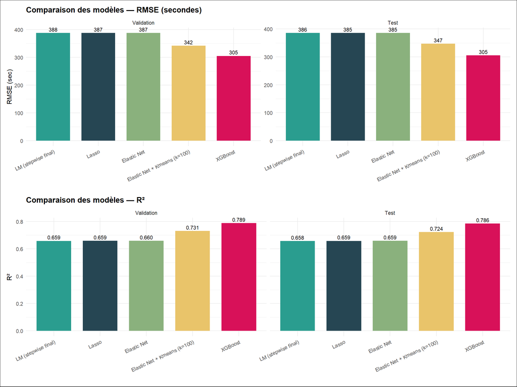

```r
rmse_long <- metrics_tbl %>%
  dplyr::select(Modele, RMSE_val_sec, RMSE_test_sec) %>%
  tidyr::pivot_longer(
    cols = c(RMSE_val_sec, RMSE_test_sec),
    names_to = "Split", values_to = "RMSE_sec"
  ) %>%
  dplyr::mutate(
    Split = factor(dplyr::recode(Split,
                                 RMSE_val_sec = "Validation",
                                 RMSE_test_sec = "Test"),
                   levels = c("Validation", "Test")),
    Modele = factor(Modele, levels = model_order)
  )

p_rmse <- ggplot(rmse_long, aes(x = Modele, y = RMSE_sec, fill = Modele)) +
  geom_col(position = position_dodge(width = 0.8), width = 0.75) +
  geom_text(aes(label = sprintf("%.0f", RMSE_sec)),
            position = position_dodge(width = 0.8),
            vjust = -0.4, size = 3) +
  facet_wrap(~Split, nrow = 1, scales = "free_y") +
  scale_fill_manual(values = model_colors) +
  labs(
    title = "Comparaison des modèles — RMSE (secondes)",
    x = "", y = "RMSE (sec)"
  ) +
  theme_minimal() +
  theme(
    legend.position = "none",
    axis.text.x = element_text(angle = 25, hjust = 1),
    plot.title = element_text(face = "bold")
  )

r2_long <- metrics_tbl %>%
  dplyr::select(Modele, R2_val, R2_test) %>%
  tidyr::pivot_longer(
    cols = c(R2_val, R2_test),
    names_to = "Split", values_to = "R2"
  ) %>%
  dplyr::mutate(
    Split = factor(dplyr::recode(Split,
                                 R2_val = "Validation",
                                 R2_test = "Test"),
                   levels = c("Validation", "Test")),
    Modele = factor(Modele, levels = model_order)
  )

p_r2 <- ggplot(r2_long, aes(x = Modele, y = R2, fill = Modele)) +
  geom_col(position = position_dodge(width = 0.8), width = 0.75) +
  geom_text(aes(label = sprintf("%.3f", R2)),
            position = position_dodge(width = 0.8),
            vjust = -0.4, size = 3) +
  facet_wrap(~Split, nrow = 1) +
  scale_fill_manual(values = model_colors) +
  labs(
    title = "Comparaison des modèles — R²",
    x = "", y = "R²"
  ) +
  theme_minimal() +
  theme(
    legend.position = "none",
    axis.text.x = element_text(angle = 25, hjust = 1),
    plot.title = element_text(face = "bold")
  )

p_rmse / p_r2
```

```r
set.seed(RANDOM_STATE)
n_s <- min(6000, length(y_val_sec))
idx_s <- sample(seq_along(y_val_sec), n_s)

scatter_df_val <- tibble::tibble(
  actual = y_val_sec[idx_s],
  `LM (stepwise final)` = pred_lm_val_sec[idx_s],
  `Lasso` = pred_lasso_val_sec[idx_s],
  `Elastic Net` = pred_enet_val_sec[idx_s],
  `XGBoost` = pred_xgb_val_sec[idx_s]
) %>%
  tidyr::pivot_longer(-actual, names_to = "Modele", values_to = "pred") %>%
  mutate(Modele = factor(Modele, levels = names(model_colors)))

oof_pred_sec <- pmax(expm1(res_k_local$oof_pred_log), 0)
y_train_full_sec <- df_train_features$trip_duration

n_o <- min(6000, length(y_train_full_sec))
idx_o <- sample(seq_along(y_train_full_sec), n_o)

scatter_df_oof_local <- tibble::tibble(
  actual = y_train_full_sec[idx_o],
  pred = oof_pred_sec[idx_o],
  Modele = paste0("Elastic Net + Kmeans (k=", k_local, ")")
)

scatter_df_val2 <- bind_rows(
  scatter_df_val,
  scatter_df_oof_local %>% mutate(Modele = factor(Modele, levels = names(model_colors)))
)

# Scatter (Validation)
p_scatter_val_gg <- ggplot(scatter_df_val2, aes(x = actual, y = pred, color = Modele)) +
  geom_point(alpha = 0.15, size = 0.4) +
  geom_abline(intercept = 0, slope = 1, linetype = "dashed") +
  scale_color_manual(values = model_colors) +
  coord_cartesian(xlim = c(0, 5000), ylim = c(0, 5000)) +
  labs(
    title = "Validation — Réel vs Prédit (échantillon)",
    subtitle = "Pour le modèle local (K-means + EN), le scatter utilise les prédictions OOF sur train",
    x = "Durée réelle (sec)",
    y = "Durée prédite (sec)"
  ) +
  theme_minimal() +
  theme(plot.title = element_text(face = "bold"))

p_scatter_val_plotly <- ggplotly(p_scatter_val_gg) %>%
  layout(legend = list(title = list(text = "Modèle")))

p_scatter_val_plotly
```

[interactive chart not shown]

```r
# Scatter (Test)
n_t <- min(6000, length(y_test_sec))
idx_t <- sample(seq_along(y_test_sec), n_t)

scatter_df_test <- tibble::tibble(
  actual = y_test_sec[idx_t],
  `LM (stepwise final)` = pred_lm_test_sec[idx_t],
  `Lasso` = pred_lasso_test_sec[idx_t],
  `Elastic Net` = pred_enet_test_sec[idx_t],
  `XGBoost` = pred_xgb_test_sec[idx_t]
) %>%
  dplyr::mutate(!!local_name := pred_k_test_sec[idx_t]) %>%   # <- dynamic column name here
  tidyr::pivot_longer(-actual, names_to = "Modele", values_to = "pred") %>%
  dplyr::mutate(Modele = factor(Modele, levels = names(model_colors)))

p_scatter_test_gg <- ggplot(scatter_df_test, aes(x = actual, y = pred, color = Modele)) +
  geom_point(alpha = 0.15, size = 0.4) +
  geom_abline(intercept = 0, slope = 1, linetype = "dashed") +
  scale_color_manual(values = model_colors) +
  coord_cartesian(xlim = c(0, 5000), ylim = c(0, 5000)) +
  labs(
    title = "Test — Réel vs Prédit (échantillon)",
    x = "Durée réelle (sec)",
    y = "Durée prédite (sec)"
  ) +
  theme_minimal() +
  theme(plot.title = element_text(face = "bold"))

p_scatter_test_plotly <- ggplotly(p_scatter_test_gg) %>%
  layout(legend = list(title = list(text = "Modèle")))

p_scatter_test_plotly
```

[interactive chart not shown]

```r
# Error distribution (Validation)
err_df <- tibble::tibble(
  Modele = c("LM (stepwise final)", "Lasso", "Elastic Net", local_name, "XGBoost"),
  err = list(
    pred_lm_val_sec - y_val_sec,
    pred_lasso_val_sec - y_val_sec,
    pred_enet_val_sec - y_val_sec,
    oof_pred_sec - y_train_full_sec,     # OOF errors for local model
    pred_xgb_val_sec - y_val_sec
  )
) %>%
  tidyr::unnest(err) %>%
  dplyr::mutate(Modele = factor(Modele, levels = names(model_colors)))

p_err_gg <- ggplot(err_df, aes(x = err, fill = Modele)) +
  geom_histogram(
    aes(y = after_stat(density)),
    binwidth = 20,
    alpha = 0.5,
    position = "identity"
  ) +
  scale_fill_manual(values = model_colors) +
  coord_cartesian(xlim = c(-1500, 1500)) +
  labs(
    title = "Distribution des erreurs (Validation)",
    subtitle = "Histogrammes normalisés (densité) — comparaison équitable",
    x = "Erreur (prédit − réel) en secondes",
    y = "Densité"
  ) +
  theme_minimal() +
  theme(
    legend.position = "bottom",
    plot.title = element_text(face = "bold")
  )

p_err_plotly <- ggplotly(p_err_gg) %>%
  layout(
    barmode = "overlay",
    legend = list(orientation = "h", x = 0, y = -0.2, title = list(text = "Modèle"))
  )

p_err_plotly
```

[interactive chart not shown]

**Observations :**

La distribution des erreurs (prédit − réel) est globalement **centrée autour de zéro** pour l’ensemble des modèles, indiquant l’absence de biais systématique majeur.

- Les **modèles linéaires** (LM, Lasso, Elastic Net) présentent des distributions plus larges, avec des queues épaisses, traduisant une difficulté à modéliser les trajets longs et non linéaires.
- Le modèle **Elastic Net + K-means (k = 100)** montre une **forte concentration des erreurs autour de zéro**. La densité plus élevée observée ne reflète pas une erreur plus importante, mais au contraire une **réduction de la variance** grâce à la spécialisation locale des modèles.
- **XGBoost** affiche la distribution la plus étroite et la meilleure adhérence à la diagonale sur les graphiques Réel vs Prédit, confirmant sa **supériorité en précision globale**.

Les graphiques de dispersion en validation et en test confirment ces observations : les modèles linéaires tendent à sous-estimer les trajets longs, tandis que XGBoost et l’approche locale capturent mieux la complexité spatio-temporelle du phénomène.

**Conclusion :**  
L’approche **Elastic Net + K-means** constitue un excellent compromis entre **performance et interprétabilité**, tandis que **XGBoost** reste le modèle le plus performant en termes de précision brute.

# 9 Conclusion

L’objectif de cette étude était de développer un modèle capable de prédire avec précision la durée des trajets de taxi à New York City à partir de données spatio-temporelles massives. En exploitant plus d’un million de courses et en comparant plusieurs familles de modèles, nous avons mis en évidence des compromis clairs entre performance prédictive,*robustesse*et interprétabilité.

## 9.1 Synthèse comparative des approches

Les modèles linéaires globaux (régression linéaire, Ridge, Lasso, Elastic Net) constituent une base solide, avec un RMSE d’environ **6,4 minutes** et un R² proche de **0,66**. Leur principal atout réside dans leur simplicité et leur interprétabilité, mais ils atteignent rapidement leurs limites face à la complexité et à l’hétérogénéité du trafic new-yorkais.

L’approche **hybride combinant clustering K-means et régression Elastic Net** permet de dépasser ces limites en introduisant une **dimension locale**. En segmentant l’espace urbain en micro-zones et en entraînant un modèle spécifique par cluster, le RMSE est progressivement réduit jusqu’à **5,5 minutes pour k = 1000**, soit un gain substantiel par rapport au modèle global. Cette amélioration confirme que les dynamiques de trafic sont fortement dépendantes du contexte géographique et que leur modélisation bénéficie d’une spécialisation spatiale.

Enfin, le modèle **XGBoost**, représentant une approche de Machine Learning non linéaire, s’impose comme le plus performant avec un RMSE de **5,1 minutes** et un R² de **0,79**. Sa capacité à capturer des interactions complexes entre variables temporelles, spatiales et de distance explique cet avantage net en précision.

## 9.2 Performance versus interprétabilité

Les résultats illustrent un arbitrage classique en science des données :

- **Elastic Net + Clustering** offre un excellent compromis. Bien que légèrement moins précis que XGBoost, il reste largement interprétable. L’analyse des coefficients par cluster permet de comprendre comment l’impact des variables (distance, heure, jour de la semaine) varie selon les quartiers, ce qui en fait un outil pertinent pour l’aide à la décision urbaine ou la gestion de flotte.
- **XGBoost**, en revanche, privilégie la performance prédictive. Il constitue le choix optimal pour des applications orientées utilisateurs finaux (estimation d’ETA dans une application mobile, par exemple), où la précision prime sur l’explicabilité fine des mécanismes internes.

## 9.3 Limites et perspectives

Malgré des résultats solides, plusieurs limites subsistent. Les modèles n’intègrent pas de variables exogènes telles que la météo, les événements urbains ou le trafic en temps réel, qui peuvent fortement influencer la durée des trajets. De plus, la performance se dégrade sur les trajets très longs, souvent affectés par des facteurs exceptionnels difficiles à capturer avec les seules coordonnées GPS et variables temporelles agrégées.

Des pistes d’amélioration naturelles incluent l’enrichissement des données (météo, événements), l’exploration de modèles séquentiels tels que les **LSTM** pour mieux capturer les dépendances temporelles, ou encore l’utilisation de **Graph Neural Networks** afin de représenter explicitement le réseau routier.

### 9.3.1 Conclusion finale

Ce projet démontre que la prédiction de la durée des trajets urbains repose autant sur une **ingénierie de variables rigoureuse** que sur le choix du modèle. L’introduction d’une **segmentation spatio-temporelle fine** a permis d’améliorer significativement les performances des modèles linéaires, tandis que les approches non linéaires comme XGBoost ont permis d’atteindre un niveau de précision supérieur.